# Collect & Analyze Finance Data from LSEG with Python

Alexandre Garel, Finance Professor, Audencia, 2025–2026

This notebook is organised into the following sections. In Jupyter, you can click a link to jump directly to the corresponding heading.

- 1. Global Configuration
- 2. Collecting Data from Refinitiv / LSEG with Python
  - 2.1. What is a Python package?
  - 2.2. Reading official documentation
  - 2.3. Exploring available functions and fields
  - 2.4. A first data extraction
  - 2.5. Finding the right RIC identifier and collecting returns
  - 2.6. Collecting accounting information for one stock
  - 2.7. Collecting accounting information for all CAC 40 constituents
  - 2.8. Downloading monthly total returns for all CAC 40 constituents
  - 2.9. Extracting earnings forecasts (EPS) for a single stock
  - 2.10. Extracting FX and crypto time series
  - 2.11. Extracting ESG information for companies
  - 2.12. Extracting fund information
  - 2.13. Extracting M&A deal information
  - 2.14. Extracting private equity deal information
  - 2.15. Extracting director and CEO information
  - 2.16. Extracting news flow for a company
  - 2.17. Extracting bond information and identifying green bonds
  - 2.18. Merging collected data
- 3. Data Visualisation in Python
  - 3.1. S&P 500 industry distribution (TRBC sectors)
  - 3.2. Time-series plot — CAC 40 index level
  - 3.3. Distribution of profitability (ROA) — boxplot and histogram
- 4. Data Cleaning and Summary Statistics
  - 4.1. Winsorising and trimming
  - 4.2. Summary statistics table
- 5. Hypothesis Testing with T-tests
  - 5.1. The null hypothesis
  - 5.2. Applying the t-test to S&P 500 ROA
  - 5.3. One-sided vs two-sided tests
  - 5.4. Two-sample t-test — comparing two groups
  - 5.5. Explaining performance during the COVID crisis
- 6. Regression Analysis
  - 6.1. What is a univariate regression?
  - 6.2. Application — Regression of ROA on leverage
  - 6.3. Multivariate regression — two independent variables
  - 6.4. Correlation ≠ Causation
  - 6.5. Year and industry fixed effects
  - 6.6. Explaining performance during the COVID crisis
- 7. Event Study
  - 7.1. What is an event study?
  - 7.2. Typical steps in an event study
  - 7.3. Trump's "Liberation Day" tariff announcement
  - 7.3. Market reaction to the Paris Agreement (2015)

## 1. Global Configuration

Before running any of the examples below, **run the next cell once**. It performs three housekeeping tasks that every subsequent cell depends on.

1. **`BASE_FOLDER`** — We define a single folder path where all CSV files produced in this notebook will be saved. You should change this path to a folder that exists on your own computer.
2. **Pandas display options** — By default, `pandas` (the main data-manipulation library we use) truncates wide tables. We tell it to show all columns and up to 60 rows so that our outputs are easier to read.
3. **Warning suppression** — Some libraries print non-critical warning messages. We silence them to keep the notebook output clean. If you ever need to debug an issue, you can comment out the `warnings.filterwarnings("ignore")` line.

```python
# 'warnings' lets us control Python warning messages.
import warnings  # import statement: makes external code (a module/package) available in this cell
import pandas as pd # to deal with dataframe settings
import os

# Set the folder where every CSV produced in this notebook will be saved.
# >>> Change this path to a folder that exists on YOUR computer. <<<
BASE_FOLDER = r"C:\Users\alexa\Documents\Research methods 2"
os.chdir(BASE_FOLDER) #define working folder

# Suppress non-critical warnings so the notebook output stays readable.
# Remove or comment out this line when debugging.
warnings.filterwarnings("ignore")

# Tell pandas to display ALL columns (not truncate wide tables)
# and to show at most 60 rows before summarising.
pd.set_option("display.max_columns", None)
pd.set_option("display.max_rows", 60)
```

**Running code.** Each gray box below is a *code cell*. Click inside it and press **Shift+Enter** (or click Run) to execute the code. The result appears under the cell. Run cells from top to bottom when the text says so.

**Variables.** You store values in *variables* with `=`. Once a variable exists, you can use it in later lines or cells.

**Example:**

```python
# Variables and simple operations
x = 10
y = 3
print("x =", x, ", y =", y)
print("x + y =", x + y)
print("x * y =", x * y)
```

```
x = 10 , y = 3
x + y = 13
x * y = 30
```

#### pandas: Series

A **Series** is a single column of data with a name and an index (row labels). You can do math, filter, and use `.dropna()` on it. We can also turn values to numerical values using `.to_numeric()`.

Below we introduce arrays and show how to use the **pandas** package to turn string values to numerical values and drop missing observations.

```python
# List of strings (some are numbers, one is not)
strings = ["1.5", "2.7", "missing", "4.0"]
print("Strings:", strings)
```

```
Strings: ['1.5', '2.7', 'missing', '4.0']
```

```python
import pandas as pd
# Turn to numeric: invalid text becomes NaN
numeric = pd.to_numeric(pd.Series(strings), errors="coerce")
print("Numeric (with NaN):", numeric.tolist())
```

```
Numeric (with NaN): [1.5, 2.7, nan, 4.0]
```

```python
# Drop missing values
clean = numeric.dropna()
print("After dropna():", clean.tolist())
```

```
After dropna(): [1.5, 2.7, 4.0]
```

#### pandas: DataFrames

**What is a DataFrame?** A **DataFrame** is a table: several columns (each a Series) sharing the same index. Rows = observations, columns = variables. Most datasets (CSV, Excel, etc.) are loaded as DataFrames.

**How to handle them:**

- **Create:** `pd.DataFrame({"col1": [1,2,3], "col2": ["a","b","c"]})`
- **Columns:** `df["col_name"]` or `df.col_name` gives a Series.
- **Rows:** `df.loc[0]` (by label), `df.iloc[0]` (by position).
- **Rename columns:** `df.rename(columns={"old_name": "new_name"})`
- **Subset rows:** `df[df["col"] > 0]`

```python
import pandas as pd

# Create a DataFrame
df = pd.DataFrame({"score": [85, 90, 78], "name": ["Alice", "Bob", "Charlie"]})
print("DataFrame:")
print(df)

# Columns: each column is a Series
print("\nColumn 'score' (Series):")
print(df["score"])

# Rows: by label (loc) or position (iloc)
print("\nFirst row (loc):", df.loc[0].tolist())
print("First row (iloc):", df.iloc[0].tolist())

# Rename columns
df_renamed = df.rename(columns={"score": "grade", "name": "student"})
print("\nAfter rename:")
print(df_renamed)

# Subset: keep only rows where grade > 82
print("\nRows where grade > 82:")
print(df_renamed[df_renamed["grade"] > 82])
```

```
DataFrame:
   score     name
0     85    Alice
1     90      Bob
2     78  Charlie

Column 'score' (Series):
0    85
1    90
2    78
Name: score, dtype: int64

First row (loc): [85, 'Alice']
First row (iloc): [85, 'Alice']

After rename:
   grade  student
0     85    Alice
1     90      Bob
2     78  Charlie

Rows where grade > 82:
   grade student
0     85   Alice
1     90     Bob
```

#### Other core DataFrame functions

**Inspecting data**

- **`df.head(n)`** — first `n` rows (default 5). Use **`df.tail(n)`** for the last `n` rows.
- **`df.shape`** — number of rows and columns, e.g. `(100, 5)`.
- **`df.columns`** — list of column names.
- **`df.dtypes`** — type of each column (int, float, object, etc.).

**Combining tables: merge**

- **`pd.merge(left_df, right_df, on="col")`** — join two DataFrames on a common column (like SQL JOIN). Use **`how="left"`**, **`"right"`**, **`"outer"`**, **`"inner"`** to choose the type of join.

**Other useful operations**

- **`df.dropna()`** — drop rows with missing values (NaN).
- **`df.fillna(value)`** — replace missing values with a value.
- **`df.sort_values("col")`** — sort rows by a column (use **`ascending=False`** for descending).
- **`df.describe()`** — summary statistics (count, mean, std, min, max, etc.) for numeric columns.

```python
import pandas as pd

# Two small tables
grades = pd.DataFrame({"student_id": [1, 2, 3], "grade": [85, 90, 78]})
names  = pd.DataFrame({"student_id": [1, 2, 3], "name": ["Alice", "Bob", "Charlie"]})

print("Table 1 (grades):")
print(grades)
print("\nTable 2 (names):")
print(names)

# head / tail / shape
print("\nFirst 2 rows (head):")
print(grades.head(2))
print("Shape (rows, cols):", grades.shape)
print("Column names:", grades.columns.tolist())

# merge: join on student_id
merged = pd.merge(grades, names, on="student_id")
print("\nMerged (join on 'student_id'):")
print(merged)

# sort and describe
print("\nSorted by grade (descending):")
print(merged.sort_values("grade", ascending=False))
print("\nSummary stats (describe):")
print(merged.describe())
```

```
Table 1 (grades):
   student_id  grade
0           1     85
1           2     90
2           3     78

Table 2 (names):
   student_id     name
0           1    Alice
1           2      Bob
2           3  Charlie

First 2 rows (head):
   student_id  grade
0           1     85
1           2     90
Shape (rows, cols): (3, 2)
Column names: ['student_id', 'grade']

Merged (join on 'student_id'):
   student_id  grade     name
0           1     85    Alice
1           2     90      Bob
2           3     78  Charlie

Sorted by grade (descending):
   student_id  grade     name
1           2     90      Bob
0           1     85    Alice
2           3     78  Charlie

Summary stats (describe):
       student_id      grade
count         3.0   3.000000
mean          2.0  84.333333
std           1.0   6.027714
min           1.0  78.000000
25%           1.5  81.500000
50%           2.0  85.000000
75%           2.5  87.500000
max           3.0  90.000000
```

## 2. Collecting Data from Refinitiv / LSEG with Python

In this section we learn how to connect to the **Refinitiv / LSEG** financial data platform and download market, accounting, ESG, and news data directly into Python. Every subsection follows the same pattern: open a connection, request specific data by specifying an instrument and a set of fields, inspect the result, save it as a CSV file, and close the connection.

### 2.1. What is a Python package?

A **Python package** is a collection of pre-written code that provides specific functionality. Instead of writing everything from scratch, we install a package and call the functions it provides.

Packages are installed with the **`pip`** tool. When running `pip` from inside a Jupyter Notebook cell, prefix the command with **`!`** (for example `!pip install refinitiv-data`).

**refinitiv-data** is the official Python SDK (Software Development Kit) provided by Refinitiv (now LSEG). It lets us programmatically access:

- Market data (prices, time series, intraday data).
- Reference data (instruments, identifiers, metadata).
- Fundamental and economic data (accounting, ratios).
- News and analytics.

The package handles authentication, data requests, and responses behind the scenes. The cell below installs it into the current Anaconda environment. If it is already installed, `pip` will simply report that the requirement is satisfied.

```python
!pip install refinitiv-data
```

### 2.2. Reading official documentation

Once a package is installed, the next step is to **read its official documentation**. Official documentation is the most reliable source because it describes the intended usage, explains inputs and outputs, provides examples, and reflects the most up-to-date behaviour of the package.

Key documentation sources for the Refinitiv Data Library:

- **GitHub repository**: https://github.com/refinitiv/refinitiv-data
- **Developer portal**: https://developers.refinitiv.com/

Alternatively, you can ask an **AI assistant** (Claude is recommended) to help generate code. AI can draft code snippets, explain unfamiliar functions, help debug errors, and suggest efficient approaches. However, AI-generated code must always be reviewed to ensure you understand what it does, can validate the outputs, and can catch any outdated or incorrect API usage.

A robust approach is to **constrain the AI** by providing the official documentation as input and asking it to answer only based on that material, or by asking it to consult the official online documentation first.

Two practical tools inside Python for self-documentation are:

- **`help()`** — Displays the signature and parameters of a function. Example: `help(rd.get_data)`.
- **`search.metadata.Definition(view=...)`** — Returns a table of all properties available for a given Search view (for example `EQUITY_QUOTES`, `GOV_CORP_INSTRUMENTS`), indicating which ones are searchable, groupable, and filterable.

Whenever you design a new query, it is good practice to first read the relevant section of the LSEG documentation and then inspect the metadata and `help()` output in Python so that your filters and field lists are based on what the platform actually supports.

### 2.3. Exploring available functions and fields

Before writing a data query, you may want to know **what functions are available** in the `rd` module and **how to use them**. Python provides two built-in helpers for this.

**`dir()`** — Lists every function and attribute available in a module. Running `dir(rd)` prints the names of everything you can call on the `rd` object.

**`help()`** — Shows the full documentation of a specific function, including its parameters, their types, default values, and a short description. For example, `help(rd.get_history)` explains what arguments `get_history` accepts.

The cell below demonstrates both.

```python
# Import Refinitiv Package
import refinitiv.data as rd
# List all available functions and attributes in the rd module.
print(dir(rd))
```

```
['OpenState', 'PricingStream', 'close_session', 'content', 'dates_and_calendars', 'delivery', 'discovery', 'eikon', 'errors', 'get_config', 'get_data', 'get_history', 'load_config', 'news', 'open_pricing_stream', 'open_session', 'session', 'usage_collection']
```

Here we have used the command **print**, *print()* sends information from your program to the standard output, usually the screen (console/terminal). It is important because it’s the simplest way to see what your code is doing. It connects the invisible internal world of the program (variables, calculations, logic) with what you can actually see and understand as a human.

```python
name = "Alex"  # variable assignment: store a value in 'name' so we can reuse it later
age = 21  # variable assignment: store a value in 'age' so we can reuse it later
print("Name:", name)  # print() outputs text/values to the screen (useful for checking results)
print("Age:", age)  # print() outputs text/values to the screen (useful for checking results)
```

```
Name: Alex
Age: 21
```

```python
import refinitiv.data as rd  # Refinitiv/LSEG Data Library (requires credentials)
# Get help on the function get_data
help(rd.get_data)
```

```
Help on function get_data in module refinitiv.data._access_layer.get_data_func:

get_data(universe: Union[str, Iterable[str]], fields: Union[str, Iterable[str], NoneType] = None, parameters: Union[str, dict, NoneType] = None, use_field_names_in_headers: bool = None) -> pandas.core.frame.DataFrame
    Retrieves pricing snapshots, as well as Fundamental and Reference data.

    Parameters
    ----------
    universe: str | list
        Instruments to request
    fields: str | list, optional
        Fields to request
    parameters: str | dict, optional
        Single key=value global parameter or dictionary of global parameters to request
    use_field_names_in_headers: bool, default False
        If True - returns field name as column headers for data instead of title

    Returns
    -------
    pandas.DataFrame

    Examples
    --------
    >>> get_data(universe=['IBM.N', 'VOD.L'], fields=['BID', 'ASK'])
    >>> get_data(
    ...     universe=['GOOG.O', 'AAPL.O'],
    ...     fields=['TR.EV','TR.EVToSales'],
    ...     parameters = {'SDate': '0CY', 'Curn': 'CAD'}
    ...)
```

```python
import refinitiv.data as rd  # Refinitiv/LSEG Data Library (requires credentials)
# Get help on function get_history
help(rd.get_history)
```

```
Help on function get_history in module refinitiv.data._access_layer.get_history_func:

get_history(universe: Union[str, Iterable[str]], fields: Union[str, Iterable[str], NoneType] = None, interval: Optional[str] = None, start: 'OptDateTime' = None, end: 'OptDateTime' = None, adjustments: Optional[str] = None, count: Optional[int] = None, use_field_names_in_headers: bool = None, parame…
    Retrieves the pricing history, as well as Fundamental and Reference data history.

    Parameters
    ----------
    universe: str | list
        Instruments to request
    fields: str | list, optional
        Fields to request
    interval: str, optional
        Date interval. Supported intervals are:
        tick, tas, taq, minute, 1min, 5min, 10min, 30min, 60min, hourly, 1h, daily,
        1d, 1D, 7D, 7d, weekly, 1W, monthly, 1M, quarterly, 3M, 6M, yearly, 1Y
    start: str or date or datetime or timedelta, optional
        The start date and timestamp of the requested history
    end: str or date or datetime or timedelta, optional
        The end date and timestamp of the requested history
    adjustments : str, optional
        Tells the system whether to apply or not apply CORAX (Corporate Actions)
        events or exchange/manual corrections or price and volume adjustment
        according to trade/quote qualifier summarization actions to historical time
        series data. Possible values are:
        exchangeCorrection, manualCorrection, CCH, CRE, RTS, RPO, unadjusted,
        qualifiers
    count : int, optional
        The maximum number of data points returned. Values range: 1 - 10000.
        Applies only to pricing fields.
    use_field_names_in_headers : bool, default False
        If True - returns field name as column headers for data instead of title
    parameters: str | dict, optional
        Single global parameter key=value or dictionary
        of global parameters to request.
        Applies only to TR fields.

    Returns
    -------
    pandas.DataFrame

    Examples
    --------
    >>> get_history(universe="GOOG.O")
    >>> get_history(universe="GOOG.O", fields="tr.Revenue", interval="1Y")
    >>> get_history(
    ...     universe="GOOG.O",
    ...     fields=["BID", "ASK", "tr.Revenue"],
    ...     interval="1Y",
    ...     start="2015-01-01",
    ...     end="2020-10-01",
    ... )
```

### 2.4. A first data extraction

In this subsection we run a first simple extraction to illustrate the basic workflow.

**Step-by-step logic:**

1. **Import the package** and give it the short alias `rd` so we can write `rd.get_history()` instead of `refinitiv.data.get_history()`.
2. **Open a session** with `rd.open_session()`. This authenticates you and establishes a connection to Refinitiv services. It automatically detects a running Refinitiv Workspace application.
3. **Request data** with `rd.get_history()`. We provide:
   - `universe` — the instrument we want data for, identified by its **RIC** (Reuters Instrument Code). For example, `"AAPL.O"` is Apple Inc. on NASDAQ.
   - `fields` — the specific data points to retrieve, here `"BID"` (the price a buyer is willing to pay) and `"ASK"` (the price a seller is willing to accept).
   - `start` / `end` — the date range for the historical data.
4. **Save the result** as a CSV file so we can reuse it later without re-downloading.
5. **Close the session** with `rd.close_session()` to release the connection.

The function returns a **DataFrame** — the core pandas object, which you can think of as a spreadsheet stored in Python's memory.

```python
# --- Imports needed for this cell (so it can run independently) ---
import refinitiv.data as rd  # Refinitiv/LSEG Data Library (requires credentials)

# Open the session
rd.open_session()

# Request historical BID and ASK prices for Apple (AAPL.O) over 2024–2025.
# 'universe' = the instrument; 'fields' = the data points; 'start'/'end' = date range.
df = rd.get_history(
    universe="AAPL.O",  # Apple's RIC (identifier in Refinitiv)
    fields=["BID", "ASK"],  # varaible we want to collect
    interval="daily", # interval
    start="2024-01-01",  # start date
    end="2025-12-31"  # end date
)

# Close the session to release the connection.
rd.close_session()

print(df)  # print() outputs text/values to the screen (useful for checking results)

# Save the data as a CSV file in the base folder defined in Section 1.
df.to_csv("aapl.csv")  # to_csv() writes a DataFrame to a CSV file on dis
```

```
AAPL.O         BID     ASK
Date
2024-01-02  185.52  185.53
2024-01-03  184.24  184.25
2024-01-04  181.91  181.92
2024-01-05  181.17  181.19
2024-01-08  185.54  185.55
...            ...     ...
2025-12-24  273.82  273.88
2025-12-26  273.25  273.45
2025-12-29  273.74  273.76
2025-12-30  272.98  273.09
2025-12-31  271.84  271.94

[502 rows x 2 columns]
```

**What fields can I retrieve for a given instrument?**

For a complete catalogue of all available data items and their exact code names (called **TR mnemonics**), use two desktop tools inside Refinitiv Workspace:

- **Data Item Browser (DIB)** — type `DIB` in the Workspace search bar. It lets you browse all data items and see their exact mnemonics.
- **CodeCreator (CODECR)** — type `CODECR` in the Workspace search bar. It lets you select data items and automatically generates example Python code that you can copy-paste directly into your notebook.

**Application.** Now it is your turn to practice. Find the RIC for Microsoft, read the help for *get_history()* to understand the parameters it can take and look at the variables we can retrieve with it. You must retrieve for Microsoft the monthly time series of volume over 2023. Try to do it yourself. A solution is provided below (click to unhide it).

```python
import refinitiv.data as rd  # Refinitiv/LSEG Data Library (requires credentials)

# Open a session.
rd.open_session()  # rd.open_session() starts an authenticated connection to Refinitiv/LSEG (needed before queries)

# collect data,
# traded volume: ACVOL_UNS
df = rd.get_history(
universe="MSFT.O",
fields=["ACVOL_UNS"],
interval="1M",  #monthly
start="2023-01-01",  # start date
end="2023-12-31")  # end date

# Close the session.
rd.close_session()

# show dataframe
print(df)  # print() outputs text/values to the screen (useful for checking results)

# save
df.to_csv("volume_MSFT.csv")
```

```
MSFT.O      ACVOL_UNS
Date
2023-01-31  666168068
2023-02-28  615540778
2023-03-31  747751976
2023-04-30  551520127
2023-05-31  600856941
2023-06-30  547748450
2023-07-31  666956355
2023-08-31  479669427
2023-09-30  416768824
2023-10-31  540963749
2023-11-30  564165364
2023-12-31  522081429
```

### 2.5. Finding the right RIC identifier and collecting returns

Before downloading data for a specific stock or index, you need its **RIC** (Reuters Instrument Code) — a short alphanumeric identifier that uniquely identifies an instrument on Refinitiv. For example, `"AAPL.O"` is Apple on NASDAQ and `".FCHI"` is the CAC 40 price index.

You can look up a RIC in two ways:

1. **Programmatically** — Use `rd.discovery.search()`, which queries the Refinitiv search engine. You provide a free-text `query` (e.g. `"Amazon"`), a `view` (e.g. `EQUITY_QUOTES` for stocks, `INDEX_QUOTES` for indices), and a `top` parameter that limits the number of results.
2. **Interactively** — Type the company name directly in the Refinitiv Workspace search bar and note the RIC shown next to the correct instrument.

The cell below shows the `help()` output for `rd.discovery.search` so you can see all its parameters, then demonstrates a search for Amazon.

```python
import refinitiv.data as rd  # Refinitiv/LSEG Data Library (requires credentials)
# --- Connect to Refinitiv/LSEG (requires an account + app key setup) ---
rd.open_session()
# Show the full documentation for the discovery.search function.
help(rd.discovery.search)
```

```
Help on function search in module refinitiv.data.discovery._search:

search(query: Optional[str] = None, view: Union[refinitiv.data.content.search._views.Views, str] = <Views.SEARCH_ALL: 'SearchAll'>, filter: Optional[str] = None, order_by: Optional[str] = None, boost: Optional[str] = None, select: Optional[str] = None, top: int = 10, skip: int = 0, group_by: Optiona…
    This class describe parameters to retrieve data for search.

    Parameters
    ----------
    query: str, optional
        Keyword argument for view

    view: Views or str, optional
        The view for searching see at Views enum.
        Default: Views.SEARCH_ALL

    filter: str, optional
        Where query is for unstructured end-user-oriented restriction, filter is for
        structured programmatic restriction.

    order_by: str, optional
        Defines the order in which matching documents should be returned.

    boost: str, optional
        This argument supports exactly the same predicate expression syntax as filter,
        but where filter restricts which documents are matched at all,
        boost just applies a large scoring boost to documents it matches,
        which will almost always guarantee that they appear at the top of the results.

    select: str, optional
        A comma-separated list of the properties of a document to be returned in the response.

    top: int, optional
        the maximum number of documents to retrieve. Must be non-negative.
        default: 10

    skip: int, optional
        The number of documents to skip in the sorted result set before returning the
        next top.

    group_by: str, optional
        If specified, this must name a single Groupable property.
        returned documents are grouped into buckets based on their value for this
        property.

    group_count: str, optional
        When supplied in combination with group_by, sets the maximum number of documents
        to be returned per bucket.
        default: 3

    Examples
    --------
    >>> from refinitiv.data as rd
    >>> df = rd.discovery.search(query="cfo", view=rd.discovery.Views.PEOPLE)
```

The cell below lists all available **Search views**. Each view gives access to a different category of instrument or dataset (equities, indices, bonds, deals, investors, etc.).

```python
import refinitiv.data as rd  # Refinitiv/LSEG Data Library (requires credentials)
rd.open_session()
# List all available Search views (e.g. EQUITY_QUOTES, INDEX_QUOTES, etc.).
# Each view gives access to a different type of instrument or dataset.
views = [v for v in dir(rd.discovery.Views) if not v.startswith("__")]  # variable assignment: store a value in 'views' so we can reuse it later
for i, v in enumerate(views, start=1):  # for-loop: repeat code for each element in an iterable
    print(f"{i:2d}. {v}")  # print() outputs text/values to the screen (useful for checking results)
rd.close_session()
```

```
 1. BOND_FUT_OPT_QUOTES
 2. CATALOG_ITEMS
 3. CDS_INSTRUMENTS
 4. CDS_QUOTES
 5. CMO_INSTRUMENTS
 6. CMO_QUOTES
 7. COMMODITY_QUOTES
 8. DEALS_MERGERS_AND_ACQUISITIONS
 9. DERIVATIVE_INSTRUMENTS
10. DERIVATIVE_QUOTES
11. ENTITIES
12. EQUITY_DERIVATIVE_INSTRUMENTS
13. EQUITY_DERIVATIVE_QUOTES
14. EQUITY_INSTRUMENTS
15. EQUITY_QUOTES
16. FIXED_INCOME_INSTRUMENTS
17. FIXED_INCOME_QUOTES
18. FUND_QUOTES
19. GOV_CORP_INSTRUMENTS
20. GOV_CORP_QUOTES
21. INDEX_INSTRUMENTS
22. INDEX_QUOTES
23. INDICATOR_QUOTES
24. INSTRUMENTS
25. INVESTORS
26. IRD_QUOTES
27. LOAN_INSTRUMENTS
28. LOAN_QUOTES
29. MONEY_QUOTES
30. MORTGAGE_INSTRUMENTS
31. MORT_QUOTES
32. MUNICIPAL_INSTRUMENTS
33. MUNICIPAL_QUOTES
34. ORGANISATIONS
35. PEOPLE
36. PHYSICAL_ASSETS
37. QUOTES
38. QUOTES_AND_STIRS
39. RCS
40. SEARCH_ALL
```

[output cut: 35 more lines]

[output not shown]

The cell below searches for Amazon within the `EQUITY_QUOTES` view and returns the top 10 matches. Inspect the `RIC` column to find the correct identifier.

```python
import refinitiv.data as rd
rd.open_session() #open session
# Search for "Amazon" in the EQUITY_QUOTES view (stocks only).
# 'top=10' limits the results to the 10 best matches.
results = rd.discovery.search(
    query="Amazon",
    view=rd.discovery.Views.EQUITY_QUOTES,  # listed company view
    top=10
)
rd.close_session() #close session
print(results) # visualize dataframe
```

```
  BusinessEntity                                      DocumentTitle  \
0   QUOTExEQUITY  Amazon.com Inc, Ordinary Share, NASDAQ Global ...
1   QUOTExEQUITY  Eurex Amazon Equity Total Return Future Chain ...
2   QUOTExEQUITY  Eurex AMAZON.COM INC Single Stock Equity Futur...
3   QUOTExEQUITY  Intercontinental Exchange Amazon Flex Equity F...
4   QUOTExEQUITY  Johannesburg Stock Exchange Amazon Com Interna...
5   QUOTExEQUITY  Euronext Amsterdam Amazon.com Dividend Future ...
6   QUOTExEQUITY  Johannesburg Stock Exchange Amazon Com IDX Equ...
7   QUOTExEQUITY  Eurex Amazon Equity Total Return Future Contin...
8   QUOTExEQUITY  Eurex Amazon Equity Total Return Future Contin...
9   QUOTExEQUITY  Euronext Amsterdam Amazon com Single Stock Div...

        PermID         PI        RIC
0  55839008192     746733     AMZN.O
1  22161353450  991973454    0#TAMZ:
2  22090423093  876385463    0#AMZX:
3  22145658562  971973710   0#8A7FL:
4  21481187384   79461577   0#AMZID:
5  21612423739  259118731  0#AMZNDF:
6  21481187383   79461287   0#AMZIG:
7  22161489420  997805045     TAMZc1
8  22161489429  997805046     TAMZc2
9  21612960409  259721843   AMZNDFc1
```

Once we have the correct RIC (for example `"AMZN.O"` for Amazon on NASDAQ), we can retrieve a time series of **monthly total returns**. A **total return** includes both the change in the stock price and any dividends paid during the period, which gives a more complete picture of the return to shareholders than price returns alone.

The field `TR.TotalReturn1Mo` provides the one-month total return. We set `interval="monthly"` so that we get one observation per month.

```python
import refinitiv.data as rd
rd.open_session()
# Download monthly total returns (including dividends) for Amazon (AMZN.O).
df = rd.get_history(
    universe=["AMZN.O"],
    fields=["TR.TotalReturn1Mo"],   # one-month total return
    interval="monthly",             # one observation per calendar month
    start="2004-01-01",  # start date
    end="2024-12-31"  # end date
)
rd.close_session()
print(df)
df.to_csv("AMZN_TR_monthly.csv")
```

```
AMZN.O      1 Month Total Return
Date
2004-01-30             -4.218928
2004-02-27            -12.616822
2004-03-31              0.627761
2004-04-30             -0.456621
2004-05-28             11.238532
...                          ...
2024-08-30             -4.535244
2024-09-30              4.386555
2024-10-31              0.037568
2024-11-29              7.865926
2024-12-31              5.531772

[252 rows x 1 columns]
```

**Application.** Now it is your turn to practice. Find the RIC for TESLA using the approach above and then retrieve daily total return over 2024. A solution is provided below (click to unhide it).

```python
import refinitiv.data as rd
rd.open_session() #open session
# Search for "Amazon" in the EQUITY_QUOTES view (stocks only).
# 'top=10' limits the results to the 10 best matches.
results = rd.discovery.search(
    query="Tesla",
    view=rd.discovery.Views.EQUITY_QUOTES,  # listed company view
    top=10
)
rd.close_session() #close session
print(results) # visualize dataframe
```

```
  BusinessEntity                                      DocumentTitle  \
0   QUOTExEQUITY  Tesla Inc, Ordinary Share, NASDAQ Global Selec...
1   QUOTExEQUITY  Tesla Energy Storage ED, Ordinary Share, BME S...
2   QUOTExEQUITY  Eurex Tesla Single Stock Equity Future Chain C...
3   QUOTExEQUITY  Eurex Tesla Equity Total Return Future Chain C...
4   QUOTExEQUITY  Tesla Exploration Ltd, Ordinary Share, US 'Oth...
5   QUOTExEQUITY  Johannesburg Stock Exchange Tesla Motors IDX D...
6   QUOTExEQUITY  Johannesburg Stock Exchange Tesla Motors IDX D...
7   QUOTExEQUITY  Johannesburg Stock Exchange Tesla Motors Divid...
8   QUOTExEQUITY  Mercado Mexicano de Derivados Tesla INC Equity...
9   QUOTExEQUITY  Johannesburg Stock Exchange Tesla Inc Quanto E...

        PermID         PI         RIC
0  21475021920   72106021      TSLA.O
1  21526121673  136229976      AKL.MC
2  21507224804  111707762     0#TSLG:
3  22161353501  991973572     0#TTSL:
4  55835416972   27406015    TXLZF.PK
5  21692918336  363289171  0#TSLAID-:
6  21693148095  363605390   0#TSLAID:
7  21507224945  111707951     0#TSLD:
8  22160095962  994722378     0#TSLA:
9  22110926244  914548539  0#TSLAQG1:
```

```python
import refinitiv.data as rd
rd.open_session() #open session
# Download daily total returns (including dividends) for TESLA (TSLA.O).
df = rd.get_history(
    universe=["TSLA.O"],
    fields=["TR.TotalReturn1D"],
    interval="daily",             # one observation per calendar day
    start="2024-01-01",  # start date
    end="2024-12-31"  # end date
)
rd.close_session() # close session
print(df)  # print() outputs text/values to the screen (useful for checking results)
```

```
TSLA.O      Daily Total Return
Date
2024-01-02           -0.024147
2024-01-03           -4.013364
2024-01-04           -0.218075
2024-01-05           -0.184928
2024-01-08            1.246368
...                        ...
2024-12-24            7.357176
2024-12-26           -1.763001
2024-12-27           -4.947922
2024-12-30           -3.301209
2024-12-31              -3.251

[252 rows x 1 columns]
```

We now search for the RIC of the **CAC 40** index. The CAC 40 is the main French stock market index, composed of the 40 largest companies listed on Euronext Paris. We search in the `INDEX_QUOTES` view.

```python
import refinitiv.data as rd
rd.open_session()
# Search for "CAC40" in the INDEX_QUOTES view (indices only).
results = rd.discovery.search(
    query="CAC40", #the index we are looking for
    view=rd.discovery.Views.INDEX_QUOTES, # the view universe where we want to search (INDEXES)
    top=10
)
rd.close_session() #close session
print(results)  # print() outputs text/values to the screen (useful for checking results)
```

```
  BusinessEntity                                      DocumentTitle  \
0    QUOTExINDEX         CAC 40 Index, Equity Index, Euronext Paris
1    QUOTExINDEX  CAC 40 Index, Equity Index, Chain, Euronext Paris
2    QUOTExINDEX  CAC 40 Gross Total Return Index, Equity Index,...
3    QUOTExINDEX  CAC 40 Net Total Return, Equity Index, Euronex...
4    QUOTExINDEX     CAC 40 ESG Index, Equity Index, Euronext Paris
5    QUOTExINDEX  CAC 40 Equal Weight GR Index, Equity Index, Eu...
6    QUOTExINDEX  CAC 40 X2 Short Index, Equity Index, Euronext ...
7    QUOTExINDEX   CAC 40 Short Index, Equity Index, Euronext Paris
8    QUOTExINDEX  CAC 40 Synthetic Dividend Index, Equity Index,...
9    QUOTExINDEX  CAC40 Eq Weight Index, Equity Index, Euronext ...

         PermID         PI      RIC
0   71966969118    1033356    .FCHI
1          <NA>   12308819  0#.FCHI
2   69578169762   49801228   .PX1GR
3   71037077632   49801208   .PX1NR
4   72409723179  502602020   .CESGP
5   55869215877   79709281   .CACEG
6   72687075938   56819320   .CAC2S
7   55856795777   42171026   .CACSH
8  130604843025  258995762    .C4SD
9   55856795774   60996262   .CACEW
```

For indices, **total return** fields often do not work on the standard price-only RIC (like `.FCHI` for the CAC 40) because that RIC tracks price movements only and ignores dividends. The solution is to use the **gross total return** version of the index, which has a different RIC. For the CAC 40, the gross total return index is `".PX1GR"`.

From the index level we compute **monthly returns** using the `.pct_change()` method, which calculates the percentage change from one row to the next: `return_t = (level_t / level_{t-1}) - 1`.

```python
import pandas as pd
import refinitiv.data as rd
rd.open_session()
# Request the monthly level of the CAC 40 gross total return index.
# - universe=".PX1GR" tells Refinitiv which instrument we want (the CAC 40 gross total return index RIC).
# - fields=["TRDPRC_1"] asks for the last price (index level) at each date.
# - interval="monthly" asks for monthly observations instead of daily data.
# - start / end specify the date range of the history.
df = rd.get_history(
    universe=".PX1GR",
    fields=["TRDPRC_1"],
    interval="monthly",
    start="2005-01-01",
    end="2024-12-31",)
rd.close_session()
# print dataframe
print(df)
# Compute monthly returns as the percentage change between consecutive index levels.
# df.pct_change() computes (value_t / value_{t-1}) - 1 for each row.
# The first row has no previous observation, so pct_change() returns NaN there;
# .dropna() removes that first row with the missing value.
returns = df.pct_change().dropna()  # variable assignment: store a value in 'returns' so we can reuse it later
print(returns)
#save
returns.to_csv("cac40_gross_returns.csv")
```

```
.PX1GR      TRDPRC_1
Date
2005-01-31   6318.85
2005-02-28   6502.05
2005-03-31   6567.64
2005-04-30   6329.85
2005-05-31    6774.6
...              ...
2024-08-31  23742.54
2024-09-30  23783.25
2024-10-31  22901.87
2024-11-30  22550.65
2024-12-31  23033.78

[240 rows x 1 columns]
.PX1GR      TRDPRC_1
Date
2005-02-28  0.028993
2005-03-31  0.010088
2005-04-30 -0.036206
2005-05-31  0.070262
2005-06-30  0.031456
...              ...
2024-08-31  0.013206
2024-09-30  0.001715
2024-10-31 -0.037059
2024-11-30 -0.015336
2024-12-31  0.021424

[239 rows x 1 columns]
```

**Application.** Now it is your turn to practice. Find the RIC for gross return of the EUROSTOXX 600 using the approach above and then retrieve yearly gross total returns over the last 20 years. A solution is provided below (click to unhide it).

```python
import refinitiv.data as rd
rd.open_session()
# Search for "STOXX 600" in the INDEX_QUOTES view (indices only).
results = rd.discovery.search(
    query="STOXX 600",
    view=rd.discovery.Views.INDEX_QUOTES,
    top=10)
rd.close_session()
print(results)
```

```
  BusinessEntity                                      DocumentTitle  \
0    QUOTExINDEX  STOXX Europe 600 EUR Price Index, Equity Index...
1    QUOTExINDEX  STOXX Europe 600 Banks EUR Price Index, Equity...
2    QUOTExINDEX  STOXX Europe 600 Oil & Gas EUR Price Index, Eq...
3    QUOTExINDEX  STOXX Europe 600 Travel & Leisure EUR Price In...
4    QUOTExINDEX  STOXX Europe 600 Insurance EUR Price Index, Eq...
5    QUOTExINDEX  STOXX Europe 600 Utilities EUR Price Index, Eq...
6    QUOTExINDEX  STOXX Europe 600 Health Care EUR Price Index, ...
7    QUOTExINDEX  STOXX Europe 600 Basic Resources EUR Price Ind...
8    QUOTExINDEX  STOXX Europe 600 Technology EUR Price Index, E...
9    QUOTExINDEX  STOXX Europe 600 Industrial Goods & Services E...

        PermID        PI     RIC
0  69330139500    796197  .STOXX
1  71707040813    796225   .SX7P
2  72520114579    796160   .SXEP
3  69758906839  18071412   .SXTP
4  72071201818    796187   .SXIP
5  70334567283    796175   .SX6P
6  69543985140    796276   .SXDP
7  72083790550    796167   .SXPP
8  70991426122    796229   .SX8P
9  69777024705    796149   .SXNP
```

```python
# returns for this index
import refinitiv.data as rd
rd.open_session()
# Download the monthly level of the STOXX 600 gross total return index.
# TRDPRC_1 is the "last price" field commonly used for index levels.
df = rd.get_history(
    universe=".STOXX",
    fields=["TRDPRC_1"],
    interval="1Y",  # yearly interval
    start="2005-01-01",  #  start date
    end="2025-01-01"  # end date
)
rd.close_session()
# .pct_change() returns NaN for the first row (no previous level), so we drop it.
returns = df.pct_change().dropna()
print(returns)
# Save search results to CSV.
returns.to_csv("stox600_gross_returns.csv")
```

```
.STOXX      TRDPRC_1
Date
2006-12-31  0.178144
2007-12-31 -0.001697
2008-12-31 -0.456011
2009-12-31  0.279946
2010-12-31  0.086337
2011-12-31 -0.113375
2012-12-31  0.143698
2013-12-31  0.173699
2014-12-31  0.043502
2015-12-31  0.067934
2016-12-31 -0.012001
2017-12-31  0.076808
2018-12-31 -0.132407
2019-12-31  0.231571
2020-12-31 -0.040424
2021-12-31  0.222464
2022-12-31 -0.128967
2023-12-31  0.127327
2024-12-31  0.059772
2025-12-31  0.166601
```

### 2.6. Collecting accounting information for one stock

Using `get_data()`, we can collect accounting information for a given stock (over a given period).

```python
import refinitiv.data as rd  # Refinitiv/LSEG Data Library (requires credentials)
help(rd.get_data)
```

```
Help on function get_data in module refinitiv.data._access_layer.get_data_func:

get_data(universe: Union[str, Iterable[str]], fields: Union[str, Iterable[str], NoneType] = None, parameters: Union[str, dict, NoneType] = None, use_field_names_in_headers: bool = None) -> pandas.core.frame.DataFrame
    Retrieves pricing snapshots, as well as Fundamental and Reference data.

    Parameters
    ----------
    universe: str | list
        Instruments to request
    fields: str | list, optional
        Fields to request
    parameters: str | dict, optional
        Single key=value global parameter or dictionary of global parameters to request
    use_field_names_in_headers: bool, default False
        If True - returns field name as column headers for data instead of title

    Returns
    -------
    pandas.DataFrame

    Examples
    --------
    >>> get_data(universe=['IBM.N', 'VOD.L'], fields=['BID', 'ASK'])
    >>> get_data(
    ...     universe=['GOOG.O', 'AAPL.O'],
    ...     fields=['TR.EV','TR.EVToSales'],
    ...     parameters = {'SDate': '0CY', 'Curn': 'CAD'}
    ...)
```

As before, we look up for the right variable name in Refinitiv using either:

- **Data Item Browser (DIB)** — type `DIB` in the Workspace search bar.
- **CodeCreator (CODECR)** — type `CODECR` in the Workspace search bar.

Doing so we find that for a stock such as TESLA, the right variable name for net income is `TR.NetIncome`. We retrieve it over the last ten years.

```python
#use get_data():
import refinitiv.data as rd
rd.open_session()
# Define identifier
ric = "TSLA.O"  # TESAL identifier
# Define the sample period and frequency.
# SDate / EDate = start / end; Frq = "FY" means one observation per fiscal year.
params = {  # variable assignment: store a value in 'params' so we can reuse it later
    "SDate": "2014-01-01",
    "EDate": "2024-12-31",
    "Frq":   "FY"
}
# Define the raw accounting fields to download.
# Field mnemonics must always be verified in the Data Item Browser (DIB).
# We define start date, end ate, and frequency (fiscal years)
fields = ["TR.NetIncome", "TR.NetIncome.Date"]  # variable assignment: store a value in 'fields' so we can reuse it later
# Download the panel using rd.get_data().
tesla_data = rd.get_data(
    universe=ric,
    fields=fields,
    parameters={ "SDate": "2014-01-01", "EDate": "2024-12-31", "Frq": "FY"})
# show data
print(tesla_data)
# save data
tesla_data.to_csv("tesla_net_income.csv")
```

```
   Instrument  Net Income Incl Extra Before Distributions       Date
0      TSLA.O                                   -74014000 2013-12-31
1      TSLA.O                                  -294040000 2014-12-31
2      TSLA.O                                  -888663000 2015-12-31
3      TSLA.O                                  -674914000 2016-12-31
4      TSLA.O                                 -1961400000 2017-12-31
5      TSLA.O                                  -976091000 2018-12-31
6      TSLA.O                                  -870000000 2019-12-31
7      TSLA.O                                   690000000 2020-12-31
8      TSLA.O                                  5524000000 2021-12-31
9      TSLA.O                                 12583000000 2022-12-31
10     TSLA.O                                 14999000000 2023-12-31
```

**Application.** Now it is your turn to practice. Collect the capital expenditures of the company Dassault over the last five years. First, find the RIC for Dassault, then the variable name for the capital expenditures, finally collect. A solution is provided below (click to unhide it).

```python
import refinitiv.data as rd
rd.open_session()
# Download the panel using rd.get_data().
dassault_data = rd.get_data(
    universe="DAST.PA",
    fields=["TR.CapitalExpenditures", "TR.CapitalExpenditures.Date"],
    parameters= { "SDate": "-5Y",  "EDate": "0",  "Frq":   "FY"})
# show data
print(dassault_data)
# save data
dassault_data.to_csv("dassault_capex.csv")
```

```
  Instrument  Capital Expenditures, Cumulative       Date
0    DAST.PA                        -103700000 2021-12-31
1    DAST.PA                        -132300000 2022-12-31
2    DAST.PA                        -145300000 2023-12-31
3    DAST.PA                        -193400000 2024-12-31
4    DAST.PA                        -160500000 2025-12-31
```

### 2.7. Collecting accounting information for all CAC 40 constituents

We now build a **panel of accounting variables** for all the constituents of the CAC 40 over the last 20 years. A *panel* (also called *longitudinal data*) is a dataset where we observe the same set of companies across multiple time periods — here one row per company per fiscal year.

The steps are:

1. **Identify the CAC 40 constituents.** We use the index chain RIC `0#.FCHI`. We already know that the RIC of the index CAC40 is `.FCHI`, the `0#` prefix is Refinitiv's Chain RIC notation. It tells the system to expand the index into its individual constituents rather than returning the index itself.
2. **Set the time span and frequency.** We request 20 years of annual (fiscal-year) data using the `parameters` argument: `SDate` (start date), `EDate` (end date), and `Frq` (frequency, `"FY"` for fiscal year).
3. **Request fundamental fields.** We use `rd.get_data()` — designed for fundamental / reference data — rather than `rd.get_history()` (which is for time-series / market data). The fields requested are the raw accounting items we need to construct standard financial ratios.
4. **Construct clean variables in Python.** We rename columns to readable names and compute standard ratios: ROA (Return on Assets), leverage (Debt / Assets), market-to-book, capex intensity, R&D intensity, and log of total assets (a proxy for firm size).
5. **Save the panel** as a CSV file so that later sections can reload it without re-downloading.

The cell below first retrieves the current CAC 40 constituent list.

```python
import refinitiv.data as rd
rd.open_session()
# Retrieve the current CAC 40 constituents from the index chain RIC.
# '0#.FCHI' is the chain RIC that lists every member of the CAC 40.
cac_chain = "0#.FCHI"
constituents = rd.get_data(
    universe=cac_chain,
    fields=["TR.RIC", "TR.CommonName"])
rd.close_session()
# Print to check list
print(constituents)
# Save the constituent list to CSV.
constituents.to_csv("cac40_constituents.csv")
```

```
   Instrument       RIC                                Company Common Name
0     BNPP.PA   BNPP.PA                                     BNP Paribas SA
1     DANO.PA   DANO.PA                                          Danone SA
2    ENGIE.PA  ENGIE.PA                                           Engie SA
3    STMPA.PA  STMPA.PA                              STMicroelectronics NV
4     ACCP.PA   ACCP.PA                                           Accor SA
5     PERP.PA   PERP.PA                                   Pernod Ricard SA
6     ESLX.PA   ESLX.PA                                Essilorluxottica SA
7      ENX.PA    ENX.PA                                        Euronext NV
8     TTEF.PA   TTEF.PA                                   TotalEnergies SE
9     SCHN.PA   SCHN.PA                              Schneider Electric SE
10    HRMS.PA   HRMS.PA                           Hermes International SCA
11   STLAM.PA  STLAM.PA                                      Stellantis NV
12    PUBP.PA   PUBP.PA                                 Publicis Groupe SA
13     VIE.PA    VIE.PA                            Veolia Environnement SA
```

[output cut: 26 more lines]

The next cell downloads the 20-year accounting panel and constructs the derived variables. This cell depends on the `constituents` DataFrame created just above — they must be run in order.

**Fields requested (raw accounting items):**

| Field mnemonic | Description | Variable name after rename |
| --- | --- | --- |
| `TR.NetIncome` | Net income | `net_income` |
| `TR.CompanyMarketCap` | Market capitalisation | `market_cap` |
| `TR.F.ComEqTot` | Common equity (book value) | `equity_value` |
| `TR.CapitalExpenditures` | Capital expenditures | `capex` |
| `TR.TotalAssets` | Total assets | `total_assets` |
| `TR.RnDExp` | Research & development expense | `rd_exp` |
| `TR.TotalDebt` | Total debt | `total_debt` |
| `TR.TotalAssets.date` | Fiscal period end date | `period_end` |

**Derived ratios:**

| Variable | Formula | Interpretation |
| --- | --- | --- |
| ROA | Net income / Total assets | How efficiently a company uses its assets to generate profit |
| Leverage | Total debt / Total assets | How much of the company's assets are financed by debt |
| Market-to-book | Market cap / Equity book value | How much investors value the company relative to its accounting value |
| Capex / Assets | Capital expenditures / Total assets | Investment intensity |
| R&D / Assets | R&D expense / Total assets | Innovation intensity |
| ln(Total assets) | Natural logarithm of total assets | Firm size (log-transformed to reduce skewness) |

```python
import pandas as pd
import refinitiv.data as rd
rd.open_session()
# load cac40 consistuents
rics= pd.read_csv("cac40_constituents.csv")
rics= pd.read_csv("cac40_constituents.csv")["RIC"].to_list()
print(rics)
# Download the panel using rd.get_data().
raw_panel = rd.get_data(
    universe=rics,
    fields=[ "TR.NetIncome", "TR.CompanyMarketCap", "TR.F.ComEqTot", "TR.CapitalExpenditures", "TR.TotalAssets",
    "TR.RnDExp", "TR.TotalDebt", "TR.TotalAssets.date"],
    parameters={ "SDate": "2005-01-01", "EDate": "2024-12-31", "Frq": "FY"})
rd.close_session()
# show first rows of dataframe
print(raw_panel.head(n=10))
#save
raw_panel.to_csv("raw_panel.csv")
```

```
['BNPP.PA', 'DANO.PA', 'ENGIE.PA', 'STMPA.PA', 'ACCP.PA', 'PERP.PA', 'ESLX.PA', 'ENX.PA', 'TTEF.PA', 'SCHN.PA', 'HRMS.PA', 'STLAM.PA', 'PUBP.PA', 'VIE.PA', 'MICP.PA', 'CAPP.PA', 'AXAF.PA', 'OREP.PA', 'ORAN.PA', 'AIRP.PA', 'MT.AS', 'AIR.PA', 'TCFP.PA', 'SGOB.PA', 'RENA.PA', 'SOGN.PA', 'DAST.PA', 'FOU…
  Instrument  Net Income Incl Extra Before Distributions  Company Market Cap  \
0    BNPP.PA                                  4939000000  57294242051.199997
1    BNPP.PA                                  5852000000  76903136974.049896
2    BNPP.PA                                  7308000000  67188420059.759903
3    BNPP.PA                                  7822000000      27581052089.25
4    BNPP.PA                                  3021000000  66194285406.599998
5    BNPP.PA                                  5832000000  57044089753.739998
6    BNPP.PA                                  7843000000  36654905904.299896
7    BNPP.PA                                  6050000000  52881101736.269997
8    BNPP.PA                                  6564000000  70498816996.850006
9    BNPP.PA                                  4818000000  61368934632.059998

   Common Equity - Total  Capital Expenditures, Cumulative  \
0          43876000000.0                        -764000000
```

[output cut: 21 more lines]

```python
raw_panel.columns
```

```
Index(['Instrument', 'Net Income Incl Extra Before Distributions',
       'Company Market Cap', 'Common Equity - Total',
       'Capital Expenditures, Cumulative', 'Total Assets',
       'R&D Expense - Broker Estimate', 'Total Debt', 'Date'],
      dtype='object')
```

```python
import pandas as pd
import numpy as np #package to take log

# load panel data
panel = pd.read_csv("raw_panel.csv")

# ── Compute derived financial ratios ──────────────────────────────────────────
panel["ROA"]            = panel["Net Income Incl Extra Before Distributions"]  / panel["Total Assets"]
panel["capex_at"]       = panel["Capital Expenditures, Cumulative"]       / panel["Total Assets"]
panel["ln_at"]          = np.log(panel["Total Assets"])
panel["leverage"]       = panel["Total Debt"]  / panel["Total Assets"]
panel["Market_to_book"] = panel["Company Market Cap"]  / panel["Common Equity - Total"]
panel["rnd_at"]         = panel["R&D Expense - Broker Estimate"]      / panel["Total Assets"]

# Quick inspection
print(panel.head(n=10))

# Save the panel as a CSV
panel.to_csv("cac40_fundamentals_2005_2024.csv")
```

```
   Unnamed: 0 Instrument  Net Income Incl Extra Before Distributions  \
0           0    BNPP.PA                                4.939000e+09
1           1    BNPP.PA                                5.852000e+09
2           2    BNPP.PA                                7.308000e+09
3           3    BNPP.PA                                7.822000e+09
4           4    BNPP.PA                                3.021000e+09
5           5    BNPP.PA                                5.832000e+09
6           6    BNPP.PA                                7.843000e+09
7           7    BNPP.PA                                6.050000e+09
8           8    BNPP.PA                                6.564000e+09
9           9    BNPP.PA                                4.818000e+09

   Company Market Cap  Common Equity - Total  \
0        5.729424e+10           4.387600e+10
1        7.690314e+10           6.041200e+10
```

[output cut: 44 more lines]

**Application.** Now it is your turn to practice. For all the constituent of the EURO STOXX 600, retrieve the sales as of 2024. A solution is provided below (click to unhide it).

```python
import refinitiv.data as rd
rd.open_session()
# Retrieve constituents of STOXX
constituents = rd.get_data(  # variable assignment: store a value in 'constituents' so we can reuse it later
    universe=["0#.STOXX"],
    fields=["TR.RIC", "TR.CommonName"]  # keyword argument: set the parameter 'fields' for the function call
)
print(constituents)  # print() outputs text/values to the screen (useful for checking results)
# Extract the list of RICs from the constituents table.
rics = constituents["RIC"].tolist()  # variable assignment: store a value in 'rics' so we can reuse it later
#keep non void rics
rics = list(filter(None, rics))
# Download the panel using rd.get_data().
raw_panel = rd.get_data(
    universe=rics,
    fields=["TR.Revenue", "TR.Revenue.Date"],
    parameters={"EDate": "2024-12-31"})
rd.close_session()
#Print
print(raw_panel.head())
#Save
raw_panel.to_csv("stoxx_sales_2024.csv")
```

```
    Instrument       RIC Company Common Name
0        SSE.L     SSE.L             SSE PLC
1       AAK.ST    AAK.ST       AAK AB (publ)
2        SDR.L     SDR.L       Schroders PLC
3      SASY.PA   SASY.PA           Sanofi SA
4     NSISb.CO  NSISb.CO       Novozymes A/S
..         ...       ...                 ...
595   NOKIA.HE  NOKIA.HE           Nokia Oyj
596    CAMX.ST   CAMX.ST          Camurus AB
597    SPIE.PA   SPIE.PA             Spie SA
598      NXT.L     NXT.L            Next PLC
599    FDJU.PA   FDJU.PA          FDJ United

[600 rows x 3 columns]
  Instrument      Revenue       Date
0      SSE.L  10131900000 2025-03-31
1     AAK.ST  46021000000 2025-12-31
2     AAK.ST  45052000000 2024-12-31
3      SDR.L   3250700000 2025-12-31
4      SDR.L   2970000000 2024-12-31
```

### 2.8. Downloading monthly total returns for all CAC 40 constituents

In Section 2.7 we built a panel of annual accounting variables. For many empirical applications we also need **stock returns**. In this subsection we download **monthly total returns** (including dividends) for every CAC 40 stock over the same 2005–2024 window.

We use `rd.get_history()` (for time-series data) instead of `rd.get_data()` (which is for snapshot / fundamental data). The field `TR.TotalReturn1Mo` gives the one-month total return — it includes both price changes and reinvested dividends, which is what we typically want when studying portfolio performance or testing asset-pricing models.

```python
import refinitiv.data as rd
rd.open_session()
# Reload the CAC 40 constituent list from the CSV saved in Section 2.6.
constituents = pd.read_csv("cac40_constituents.csv")
rics = constituents["RIC"].tolist()
print(rics)
# Download monthly total returns (including dividends).
returns_cac40 = rd.get_history(
    universe=rics,
    fields=["TR.TotalReturn1Mo"],
    interval="monthly",
    start="2005-01-01",
    end="2024-12-31")
rd.close_session()
# Print
print(returns_cac40.head())
# Save
returns_cac40.to_csv("cac40_monthly_total_returns_2005_2024.csv")
```

```
['BNPP.PA', 'DANO.PA', 'ENGIE.PA', 'STMPA.PA', 'ACCP.PA', 'PERP.PA', 'ESLX.PA', 'ENX.PA', 'TTEF.PA', 'SCHN.PA', 'HRMS.PA', 'STLAM.PA', 'PUBP.PA', 'VIE.PA', 'MICP.PA', 'CAPP.PA', 'AXAF.PA', 'OREP.PA', 'ORAN.PA', 'AIRP.PA', 'MT.AS', 'AIR.PA', 'TCFP.PA', 'SGOB.PA', 'RENA.PA', 'SOGN.PA', 'DAST.PA', 'FOU…
1 Month Total Return    BNPP.PA   DANO.PA  ENGIE.PA   STMPA.PA   ACCP.PA  \
Date
2005-01-31             3.846154   5.22443      <NA> -10.801394  4.191245
2005-02-28             0.550459  7.346648      <NA>   8.012821  6.692795
2005-03-31            -0.273723  1.993355      <NA>  -4.747774  6.696807
2005-04-29            -7.454545 -4.674128      <NA> -15.450311 -5.930851
2005-05-31            11.303862  5.119269      <NA>  16.178342  9.870874

1 Month Total Return   PERP.PA   ESLX.PA  ENX.PA   TTEF.PA    SCHN.PA  \
Date
2005-01-31           -2.777109 -5.464007    <NA>  2.364655  14.453125
2005-02-28            0.746314 -2.930403    <NA>  9.129641   4.960836
2005-03-31            -0.27774  5.188679    <NA>  0.669269   0.248756
2005-04-29            7.897161 -1.339286    <NA> -3.577418  -7.166667
2005-05-31            6.808559  2.290484    <NA>  5.826662  10.793358

1 Month Total Return   HRMS.PA  STLAM.PA   PUBP.PA    VIE.PA   MICP.PA  \
Date
2005-01-31            2.520436  2.205567  1.257862  2.966579  5.170587
2005-02-28            9.866667  4.300169 -2.367865 -1.499813  9.109312
2005-03-31           -5.764563 -0.929669  2.555219   4.14922  -5.93692
2005-04-29           -5.683269  -7.03538 -7.679466  6.617916 -7.227723
2005-05-31            6.499661  6.474191  7.730561  7.416116  12.35902

1 Month Total Return    CAPP.PA    AXAF.PA   OREP.PA   ORAN.PA   AIRP.PA  \
Date
2005-01-31             5.475382   2.420242  2.864816 -1.190476 -3.014706
2005-02-28            16.050903  11.409764  4.229075 -4.161412  3.984674
2005-03-31            -4.846127   1.181684  4.395604  1.315789  4.568902
2005-04-29            -8.901515  -4.795627 -9.446254 -0.612156 -3.631285
2005-05-31             7.733888   4.318062  7.563952  2.375715  4.990068

1 Month Total Return      MT.AS     AIR.PA   TCFP.PA   SGOB.PA    RENA.PA  \
Date
2005-01-31             1.433297   9.630669 -0.962627  6.881769     1.8684
2005-02-28            16.029144   2.726093 -1.865136 -0.106906   9.967846
2005-03-31           -22.951334  -2.864364 -5.935673  0.599315   0.730994
2005-04-29           -22.797263  -4.976201 -2.059925 -7.391674   -7.04023
2005-05-31            11.523546  11.940619   5.95921  7.270642  10.345813
```

[output cut: 9 more lines]

```
1 Month Total Return    SGEF.PA  LEGD.PA    CARR.PA   SASY.PA    BOUY.PA  \
Date
2005-01-31            11.336032     <NA>  12.871005 -2.636054   11.45935
2005-02-28             1.834862     <NA>   1.670951  5.779335  11.171477
2005-03-31              0.18018     <NA>   3.514539  7.698675  -6.597434
2005-04-29             4.676259     <NA>  -6.429571  4.268293   1.514154
2005-05-31             6.560548     <NA>   7.466667  7.163743    3.86974

1 Month Total Return     URW.PA   LVMH.PA     SAF.PA    EUFI.PA  BVI.PA
Date
2005-01-31            14.558178   -5.4126  -1.466837  14.081996    <NA>
2005-02-28             1.962923  4.873477  15.885417  12.868633    <NA>
2005-03-31            -2.192513  3.127793   -1.94091  -1.425178    <NA>
2005-04-29             6.640347 -4.385965  -5.581948   3.365854    <NA>
2005-05-31             8.263598   7.71422  -2.352596  11.986786    <NA>
```

**Application.** Now it is your turn to practice. For all the constituent of the S&P 500, collect the time series of monthly returns over the year 2024. A solution is provided below (click to unhide it).

```python
import refinitiv.data as rd
rd.open_session()
constituents = rd.get_data(  # variable assignment: store a value in 'constituents' so we can reuse it later
    universe="0#.SPX",
    fields=["TR.RIC", "TR.CommonName"]  # keyword argument: set the parameter 'fields' for the function call
)
print(constituents)  # print() outputs text/values to the screen (useful for checking results)
rics = constituents["RIC"].tolist()  # variable assignment: store a value in 'rics' so we can reuse it later
# Download monthly total returns (including dividends).
returns_sp500 = rd.get_history(
    universe=rics,
    fields=["TR.TotalReturn1Mo"],
    interval="monthly",
    start="2024-01-01",
    end="2024-12-31")
rd.close_session()
print(returns_sp500.head())  # print() outputs text/values to the screen (useful for checking results)
# Save to CSV.
returns_sp500.to_csv("sp500_monthly_total_returns_2024.csv")
```

```
    Instrument      RIC        Company Common Name
0        CCI.N    CCI.N           Crown Castle Inc
1      CRWD.OQ  CRWD.OQ   CrowdStrike Holdings Inc
2        BLK.N    BLK.N              BlackRock Inc
3        GPN.N    GPN.N        Global Payments Inc
4        UNP.N    UNP.N         Union Pacific Corp
..         ...      ...                        ...
498    PLTR.OQ  PLTR.OQ  Palantir Technologies Inc
499      AFL.N    AFL.N                  Aflac Inc
500       DD.N     DD.N      Dupont De Nemours Inc
501      HAL.N    HAL.N             Halliburton Co
502      NUE.N    NUE.N                 Nucor Corp

[503 rows x 3 columns]
1 Month Total Return      CCI.N    CRWD.OQ     BLK.N      GPN.N     UNP.N  \
Date
2024-01-31            -6.024829  14.562118 -4.618133   4.905512 -0.688055
2024-02-29             0.908674   7.809226  2.870546  -4.195598  4.004758
2024-03-28            -2.319725  -1.098257  3.387022   3.248376 -3.058851
2024-04-30           -11.386185  -8.749493 -9.483027  -8.147539 -3.566055
2024-05-31             9.298358   7.222944   2.30441 -17.039993 -1.281835

1 Month Total Return      EFX.N     ANET.N     JPM.N     CSX.OQ     AMD.OQ  \
Date
2024-01-31            -1.192931   9.838223  3.132317   2.970868  13.757547
2024-02-29             9.548746   2.952741  7.717247   6.942478   8.266322
2024-03-28            -2.218648   4.482237  7.653445  -2.293094  -6.253571
2024-04-30           -17.692135 -11.524933 -3.710925 -10.385757 -12.249986
2024-05-31             5.259327  16.015747  5.679566   1.956653   5.379467

1 Month Total Return      COP.N     TER.OQ      IVZ.N      TGT.N      BXP.N  \
Date
2024-01-31            -3.618506 -10.993365 -11.266816  -2.345176  -5.230155
2024-02-29             1.550915   -2.22381  -4.896826   8.848386 -10.372525
2024-03-28            13.097565    8.91978   7.657365  15.884122   2.477627
2024-04-30            -1.304211   3.093149 -14.587101  -9.158625  -5.236564
2024-05-31            -6.682648  21.269406   12.30742  -2.322882  -1.971239

1 Month Total Return      VTR.N     CMI.N     DGX.N     EA.OQ    SOLV.N  \
Date
```

[output cut: 766 more lines]

```
1 Month Total Return      APO.N   Q.N    CPB.OQ    PLTR.OQ     AFL.N  \
Date
2024-01-31             7.736882  <NA>  4.096301  -6.290041  2.230303
2024-02-29            10.884822  <NA> -2.603929  46.752487 -3.945573
2024-03-28             0.581395  <NA>  4.244841  -8.253589  6.341343
2024-04-30            -3.619386  <NA>  3.720738  -4.519774 -2.573958
2024-05-31              7.61817  <NA> -2.909648  -1.319982  8.049032

1 Month Total Return       DD.N      HAL.N      NUE.N
Date
2024-01-31            -19.66723  -1.383126   7.406343
2024-02-29             9.538023  -5.700457   8.865489
2024-03-28            10.810811  12.946932   3.191994
2024-04-30            -5.438894  -4.946728 -14.840829
2024-05-31            13.848276  -2.054977   0.189877
```

### 2.9. Extracting earnings forecasts (EPS) for a single stock

**Earnings Per Share (EPS)** is a company's net profit divided by the number of shares outstanding. Analysts regularly publish forecasts of future EPS — these "consensus" forecasts are important because they reflect the market's expectations about a company's profitability.

Refinitiv provides **consensus (summary) EPS forecasts** through dedicated fields. Key concepts:

- **`TR.EPSMean`** — The average (consensus) EPS forecast across all analysts covering the stock.
- **`TR.EPSActValue`** — The actual (realised) EPS once the company reports earnings.
- **`Period`** parameter — Controls the forecast horizon: `"FY1"` = next fiscal year, `"FY2"` = the year after.
- **`Frq`** parameter — Controls how often the forecast is sampled: `"M"` = monthly.

The cells below downloads monthly EPS consensus forecasts and actuals for Microsoft (`MSFT.O`) at two horizons.

```python
import refinitiv.data as rd
rd.open_session()
# period 'FY1' (next fiscal year)
eps_fy1 = rd.get_data(
    universe="MSFT.O",
    fields=[ "TR.EPSMean",  "TR.EPSMean.Date",    "TR.EPSActValue" ],
    parameters={"SDate": "2005-01-01", "EDate": "2024-12-31",  "Frq": "M", "period":"FY1"})
rd.close_session()

# Print
print(eps_fy1)

# Save both tables to CSV
eps_fy1.to_csv("msft_eps_fy1_monthly.csv")
```

```
    Instrument  Earnings Per Share - Mean       Date  \
0       MSFT.O                    1.28345 2005-01-31
1       MSFT.O                    1.28357 2005-02-14
2       MSFT.O                    1.28536 2005-03-31
3       MSFT.O                    1.29321 2005-04-29
4       MSFT.O                    1.29419 2005-05-09
..         ...                        ...        ...
235     MSFT.O                   13.06888 2024-08-27
236     MSFT.O                   13.06876 2024-09-25
237     MSFT.O                   13.01446 2024-10-31
238     MSFT.O                    13.0223 2024-11-27
239     MSFT.O                    13.0048 2024-12-22

     Earnings Per Share - Actual
0                            1.3
1                            1.3
2                            1.3
3                            1.3
4                            1.3
..                           ...
235                        13.64
236                        13.64
237                        13.64
238                        13.64
239                        13.64

[240 rows x 4 columns]
```

```python
import refinitiv.data as rd
rd.open_session()
# period 'FY2' (in two fiscal year)
eps_fy2 = rd.get_data(
    universe="MSFT.O",
    fields=[ "TR.EPSMean",  "TR.EPSMean.Date",    "TR.EPSActValue" ],
    parameters={"SDate": "2005-01-01", "EDate": "2024-12-31",  "Frq": "M", "period":"FY2"})
rd.close_session()

# Print
print(eps_fy2)

# Save both tables to CSV
eps_fy2.to_csv("msft_eps_fy2_monthly.csv")
```

```
    Instrument  Earnings Per Share - Mean       Date  \
0       MSFT.O                    1.40278 2005-01-31
1       MSFT.O                    1.40412 2005-02-14
2       MSFT.O                    1.40059 2005-03-31
3       MSFT.O                    1.36571 2005-04-29
4       MSFT.O                    1.34833 2005-05-20
..         ...                        ...        ...
235     MSFT.O                   15.23051 2024-08-27
236     MSFT.O                    15.2152 2024-09-25
237     MSFT.O                   15.00293 2024-10-31
238     MSFT.O                   14.96288 2024-11-27
239     MSFT.O                   14.96963 2024-12-22

     Earnings Per Share - Actual
0                           1.27
1                           1.27
2                           1.27
3                           1.27
4                           1.27
..                           ...
235                         <NA>
236                         <NA>
237                         <NA>
238                         <NA>
239                         <NA>

[240 rows x 4 columns]
```

### 2.10. Extracting FX and crypto time series

In this subsection we show how to extract **foreign exchange (FX)** and **cryptocurrency** time series. The pattern is the same as before: we use `rd.get_history()`, specify the instrument RIC, choose the frequency, and select the fields.

For FX, we use standard currency RICs (for example `"EUR="` for the EUR/USD exchange rate). For cryptocurrencies, you must first look up the correct RIC in Refinitiv Workspace or DIB (for example by searching for "Bitcoin").

```python
import refinitiv.data as rd  # Refinitiv/LSEG Data Library (requires credentials)
rd.open_session()
# ── Daily BID and ASK for a full calendar year fo FX (EURUSD) ────────────────────────────────
fx_daily = rd.get_history(
    universe="EUR=",
    fields=["BID", "ASK"],
    interval="daily",
    start="2024-01-01",
    end="2024-12-31")
rd.close_session()
# Compute the bid-ask spread = ASK − BID.
fx_daily["SPREAD"] = fx_daily["ASK"] - fx_daily["BID"]
#Prints
print(fx_daily.head())
# Save to CSV.
fx_daily.to_csv("eur_fx_daily_2024.csv")
```

```
EUR=           BID     ASK  SPREAD
Date
2024-01-02  1.0947  1.0951  0.0004
2024-01-03  1.0921  1.0922  0.0001
2024-01-04  1.0943  1.0947  0.0004
2024-01-05  1.0941  1.0943  0.0002
2024-01-08  1.0949  1.0953  0.0004
```

The next cell repeats the same pattern for a cryptocurrency (Bitcoin, `"BTC="`). Replace the RIC with the correct one from Refinitiv Workspace if needed.

```python
import refinitiv.data as rd
rd.open_session()
# Download daily BID and ASK for Bitcoin over 2024.
crypto_daily = rd.get_history(
    universe= "BTC=",
    fields=["BID", "ASK"],
    interval="daily",
    start="2024-01-01",
    end="2024-12-31")
rd.close_session()
# Compute the bid-ask spread.
crypto_daily["SPREAD"] = crypto_daily["ASK"] - crypto_daily["BID"]
# print
print(crypto_daily.head())
# save
crypto_daily.to_csv("crypto_daily_2024.csv")
```

```
BTC=             BID       ASK  SPREAD
Date
2024-01-02   45124.0   45125.0     1.0
2024-01-03   42939.0   42949.0    10.0
2024-01-04   44488.0   44490.0     2.0
2024-01-05  43960.11  43961.74    1.63
2024-01-06   43919.0   43920.0     1.0
```

### 2.11. Extracting ESG information for companies

**ESG** stands for **Environmental, Social, and Governance** — three broad categories used to evaluate a company's behaviour beyond pure financial performance. Refinitiv provides ESG scores that summarise how well a company performs on each dimension.

Key fields:

| Field | Description |
| --- | --- |
| `TR.TRESGScore` | Overall ESG score (0–100) based on reported data |
| `TR.TRESGCScore` | Combined ESG score, discounted for significant controversies |
| `TR.EnvironmentPillarScore` | Environmental pillar score |
| `TR.SocialPillarScore` | Social pillar score |
| `TR.GovernancePillarScore` | Governance pillar score |
| `TR.ControvPrivacy` | Example controversy metric (privacy-related) |

The cell below retrieves a 10-year ESG history and a controversy metric for Microsoft (`MSFT.O`). The same pattern works for any RIC or list of RICs.

```python
import refinitiv.data as rd
rd.open_session()
esg_history = rd.get_data(
    universe="MSFT.O",
    fields=[
        "TR.TRESGScore",              # overall ESG score
        "TR.TRESGScore.date",         # associated date
        "TR.TRESGCScore",             # combined (controversy-adjusted) score
        "TR.EnvironmentPillarScore",  # E pillar score
        "TR.SocialPillarScore",  # S pillar score
        "TR.GovernancePillarScore", # G pillar score
    ],
    parameters={"SDate": "2015-01-01", "EDate": "2024-12-31", "Frq": "FY"})
rd.close_session()
# print
print(esg_history)
# save
esg_history.to_csv("esg_history_MSFT.csv")
```

```
  Instrument  ESG Score       Date  ESG Combined Score  \
0     MSFT.O  92.388173 2014-06-30           50.360753
1     MSFT.O  92.837502 2015-06-30           61.636142
2     MSFT.O  91.288615 2016-06-30           48.063662
3     MSFT.O  90.810406 2017-06-30           50.134933
4     MSFT.O  93.142724 2018-06-30           49.641538
5     MSFT.O  92.897549 2019-06-30           62.753122
6     MSFT.O  93.354752 2020-06-30           51.338393
7     MSFT.O   92.86643 2021-06-30           48.516548
8     MSFT.O  89.078138 2022-06-30           53.990288
9     MSFT.O  87.634574 2023-06-30           53.773039

   Environmental Pillar Score  Social Pillar Score  Governance Pillar Score
0                   80.030605            92.961252                95.601959
1                   80.751916            95.510716                94.161244
2                   79.751516            91.037778                94.965743
3                   77.675126            90.660846                94.879778
4                   76.736029            97.807049                94.048231
5                   77.531214            97.823307                93.265825
6                   77.880201            97.261344                94.633106
7                   77.926946            96.467652                94.247224
8                   78.085187            89.120055                92.339928
9                     78.0356            85.884236                92.021503
```

```python
import refinitiv.data as rd
rd.open_session()
controversy_history = rd.get_data(
    universe="MSFT.O",
    fields=["TR.ControvPrivacy", "TR.ControvPrivacy.Date"], #an ESG controversy metric,
    parameters={"SDate": "2015-01-01", "EDate": "2024-12-31", "Frq": "FY"})
rd.close_session()
# print
print(controversy_history)
# save
controversy_history.to_csv("controversy_history_MSFT.csv")
```

```
  Instrument  Controversies Privacy       Date
0     MSFT.O                      3 2014-06-30
1     MSFT.O                      1 2015-06-30
2     MSFT.O                      4 2016-06-30
3     MSFT.O                      1 2017-06-30
4     MSFT.O                      6 2018-06-30
5     MSFT.O                      2 2019-06-30
6     MSFT.O                      8 2020-06-30
7     MSFT.O                     19 2021-06-30
8     MSFT.O                   <NA> 2022-06-30
9     MSFT.O                      4 2023-06-30
```

**Application.** Now it is your turn to practice. For all the constituent of the CAC40, collect the time series of yearly total carbon emission (scope 1, 2, 3) over the last five years. First, search for the right variable name in Refinitiv. A solution is provided below (click to unhide it).

```python
import pandas as pd
import refinitiv.data as rd
rd.open_session()
# Get constituent
constituents = pd.read_csv("cac40_constituents.csv")
rics = constituents["RIC"].tolist()
co2_history = rd.get_data(
    universe=rics,
    fields=["TR.AnalyticEstimatedCO2Total", "TR.AnalyticEstimatedCO2Total.Date"],
    parameters={"SDate": "2020-01-01", "EDate": "2024-12-31", "Frq": "FY"})
rd.close_session()
# Print
print(co2_history)
# Save to CSV.
co2_history.to_csv("cac40_co2.csv")
```

```
    Instrument  Estimated CO2 Equivalents Emission Total       Date
0      BNPP.PA                                    282872 2020-12-31
1      BNPP.PA                                    251617 2021-12-31
2      BNPP.PA                                    242639 2022-12-31
3      BNPP.PA                                    162724 2023-12-31
4      BNPP.PA                                    152923 2024-12-31
..         ...                                       ...        ...
194     BVI.PA                                    142401 2020-12-31
195     BVI.PA                                    164493 2021-12-31
196     BVI.PA                                    158774 2022-12-31
197     BVI.PA                                    158639 2023-12-31
198     BVI.PA                                    158704 2024-12-31

[199 rows x 3 columns]
```

### 2.12. Extracting fund information

Refinitiv provides detailed data on **mutual funds** and **ETFs** (Exchange-Traded Funds), including fund identification, investment objectives, performance over various horizons, risk metrics, and portfolio holdings. The exact fields available depend on your institution's subscription.

We search for funds using the fund screener or type the name of find in the Refinitiv search bar.

For full documentation on `rd.get_data()` parameters, see the [official LSEG reference](https://cdn.refinitiv.com/public/rd-lib-python-doc/1.0.0.0/book/en/sections/access-layer/access/get-data-function.html) or call `help(rd.get_data)`.

```python
import refinitiv.data as rd
rd.open_session()
# Retrieve metadata for the fund view.
meta = rd.content.search.metadata.Definition(
    view=rd.content.search.Views.FUND_QUOTES
).get_data()
print(meta.data.df[["Type", "Searchable", "Exact"]].to_string())
rd.close_session()
```

```
                                                                                                    Type  Searchable  Exact
AAACurrencyBondBenchmarkChain                   AAACurrencyBondBenchmarkChain                     String       False  False
AACurrencyBondBenchmarkChain                    AACurrencyBondBenchmarkChain                      String       False  False
ABSMBSBondsRIC                                  ABSMBSBondsRIC                                    String       False  False
ActiveEstimatesExist                            ActiveEstimatesExist                             Boolean        True  False
ActivityDate                                    ActivityDate                                        Date        True  False
ACurrencyBondBenchmarkChain                     ACurrencyBondBenchmarkChain                       String       False  False
AdmissionToTrading                              AdmissionToTrading                                  Date        True  False
AliasRIC                                        AliasRIC                                          String        True   True
AlternateISIN                                   AlternateISIN                                     String        True  False
ApplicableInventory                             ApplicableInventory                               String       False  False
AssetCategory                                   AssetCategory                                     String        True   True
AssetCategoryName                               AssetCategoryName                                 String        True   True
AssetCategoryRoot                               AssetCategoryRoot                                 String        True  False
AssetCategoryRootName                           AssetCategoryRootName                             String        True  False
AssetState                                      AssetState                                        String        True  False
AssetStateName                                  AssetStateName                                    String        True  False
AssetType                                       AssetType                                         String        True  False
AvgVol30D                                       AvgVol30D                                         Double        True  False
AvgVol5D                                        AvgVol5D                                          Double        True  False
AvgVol90D                                       AvgVol90D                                         Double        True  False
BackgroundInformation                           BackgroundInformation                             String       False  False
BaseAsset                                       BaseAsset                                         String        True   True
BaseAssetIssueMainEstID                         BaseAssetIssueMainEstID                           String        True   True
BaseAssetIssueMainRepno                         BaseAssetIssueMainRepno                           String       False  False
BaseAssetIssueRepEstID                          BaseAssetIssueRepEstID                            String       False  False
BaseAssetIssueRepRepno                          BaseAssetIssueRepRepno                            String       False  False
BaseAssetPilc                                   BaseAssetPilc                                     String        True  False
BasketDescriptionLongName                       BasketDescriptionLongName                         String        True  False
BasketDescriptionShortName                      BasketDescriptionShortName                        String        True  False
BBBCurrencyBondBenchmarkChain                   BBBCurrencyBondBenchmarkChain                     String       False  False
BondFixingsRIC                                  BondFixingsRIC                                    String       False  False
BondOverviewRIC                                 BondOverviewRIC                                   String       False  False
BridgeExchange                                  BridgeExchange                                    String        True   True
BridgeVehicle                                   BridgeVehicle                                     String        True   True
BuildDateTime                                   BuildDateTime                                       Date        True  False
BusinessEntity                                  BusinessEntity                                    String        True   True
BusinessIntelligenceExists                      BusinessIntelligenceExists                       Boolean        True  False
CallPutOption                                   CallPutOption                                     String        True   True
CEDEL                                           CEDEL                                             String        True  False
```

[output cut: 644 more lines]

```
UnderlyingRCSAssetCategoryName                  UnderlyingRCSAssetCategoryName                    String        True  False
UnderlyingRCSAssetCategoryNameML                UnderlyingRCSAssetCategoryNameML                  String        True   True
UnderlyingRCSAssetClass                         UnderlyingRCSAssetClass                           String        True  False
Valoren                                         Valoren                                           String        True  False
VehAddTime                                      VehAddTime                                          Date        True  False
VehicleCommonName                               VehicleCommonName                                 String        True  False
VehicleLifecycleStatus                          VehicleLifecycleStatus                            String        True  False
VehiclePermID                                   VehiclePermID                                     String        True   True
VehModTime                                      VehModTime                                          Date        True  False
VenueLEI                                        VenueLEI                                          String        True   True
VenuePermID                                     VenuePermID                                       String        True   True
WarrantsCount                                   WarrantsCount                                     Double        True  False
WarrantType                                     WarrantType                                       String        True  False
WarrantTypeName                                 WarrantTypeName                                   String        True  False
Wert                                            Wert                                              String        True  False
```

How do I know possible values for one variable (or more) from one view to then put in place a screen/filter? I can use a **navigator**. Navigators provide the ability to summarize the distribution of your results. They are particularly useful when you are interested in gathering the domain of values for a specific property. or simply to understand how to build your filters based on specific values contained within Properties. Navigators can be used against a specific View, used in conjunction with either a query, a filter, or both. Navigators can be simple or very powerful, but provide a very useful way to capture results in logical buckets.

```python
import refinitiv.data as rd
rd.open_session()
response = rd.content.search.Definition(
    top=0,
    navigators="AssetCategoryName").get_data()
rd.close_session()
response.data.raw['Navigators']['AssetCategoryName']
```

```
{'Buckets': [{'Label': 'Equity/Equity/Index Warrant', 'Count': 30027161},
  {'Label': 'Fixed Income', 'Count': 8997437},
  {'Label': 'Energy/Energy Future', 'Count': 8947998},
  {'Label': 'Fixed Income / Muni', 'Count': 6772554},
  {'Label': 'Fixed Income/Fixed Rate Bond', 'Count': 6764679},
  {'Label': 'Equity', 'Count': 6129339},
  {'Label': 'Equity/Equity/Index Option', 'Count': 5924796},
  {'Label': 'Money Market/Interest Rate Future', 'Count': 5629045},
  {'Label': 'Equity/Equity/Index Future', 'Count': 3735152},
  {'Label': 'Fixed Income/Mortgage Pools', 'Count': 3120837},
  {'Label': 'Fixed Income/Zero Coupon Bond', 'Count': 2891892},
  {'Label': 'Fixed Income/Interest At Maturity Bond', 'Count': 2491109},
  {'Label': 'Equity/Ordinary', 'Count': 2440730},
  {'Label': 'Fixed Income/Floater', 'Count': 2208785},
  {'Label': 'Energy/Energy Spread', 'Count': 2111440},
  {'Label': 'Fixed Income/Discount Note', 'Count': 1969790},
  {'Label': 'Unclassified', 'Count': 1866512},
  {'Label': 'Equity/Equity Index', 'Count': 1645379},
  {'Label': 'Energy/Energy Cash', 'Count': 1631126},
  {'Label': 'Fund Unit/Open-End Fund', 'Count': 1579310},
  {'Label': 'Commodity/Commodity Spread', 'Count': 1521688},
  {'Label': 'Commodity/Commodity Option', 'Count': 1442941},
  {'Label': 'Commodity/Commodity Future', 'Count': 1390782},
  {'Label': 'FOREX/Currency Future', 'Count': 1201685},
  {'Label': 'Energy/Energy Option', 'Count': 916223},
  {'Label': 'Commodity/Commodity Cash', 'Count': 896784},
  {'Label': 'Fixed Income/Credit Default Swap', 'Count': 696043},
  {'Label': 'CMO Tranches', 'Count': 662476},
  {'Label': 'Fund Unit/Exchange Traded Fund', 'Count': 596484},
  {'Label': 'Fixed Income/Index Linked Bond', 'Count': 586664},
  {'Label': 'FOREX/Currency Option', 'Count': 523455},
  {'Label': 'FOREX', 'Count': 520661},
  {'Label': 'Economic Indicator/Economic Non-Financial', 'Count': 442741},
  {'Label': 'Money Market/Interest Rate Swaps', 'Count': 430990},
  {'Label': 'Fixed Income/Corp Index', 'Count': 410264},
  {'Label': 'FOREX/Non-deliverable forwards', 'Count': 404050},
  {'Label': 'FOREX/Forward', 'Count': 395302},
  {'Label': 'Fixed Income/Bond Future', 'Count': 392092},
  {'Label': 'CMO Whole Loan', 'Count': 336024},
  {'Label': 'Money Market', 'Count': 316079},
```

[output cut: 45 more lines]

```
  {'Label': 'Commodity/Commodity Index', 'Count': 7172},
  {'Label': 'Equipment Backed Loan', 'Count': 6392},
  {'Label': 'Fixed Income/Fixed Income Market Statistics', 'Count': 6355},
  {'Label': 'Auto Lease Loans', 'Count': 6231},
  {'Label': 'Money Market/Interest Rate Swap Fixing', 'Count': 5886},
  {'Label': 'Commodity/Commodity Forward', 'Count': 5866},
  {'Label': 'Personal Loan ABS', 'Count': 5423},
  {'Label': 'Fixed Income/Index Linked Floater', 'Count': 5385},
  {'Label': 'Money Market/Deposits', 'Count': 4960},
  {'Label': 'Money Market/Currency Basis Swaps', 'Count': 4622},
  {'Label': 'Money Market/Swaptions', 'Count': 4368},
  {'Label': 'Fixed Income/Capitalisation Bond', 'Count': 3873},
  {'Label': 'ABS Business Loans', 'Count': 3700},
  {'Label': 'Fund Unit/Hedge Fund', 'Count': 3564},
  {'Label': 'Energy/Energy Fixing', 'Count': 3468}]}
```

```python
# We now know what we can use in the filters
import refinitiv.data as rd
rd.open_session()
# Search for fund called mirova something
fund_list = rd.discovery.search(
    view=rd.discovery.Views.FUND_QUOTES,
    query="Mirova",
    top=100)
#show list
fund_list.head(10)
```

|  | BusinessEntity | DocumentTitle | PermID | PI | RIC |
| --- | --- | --- | --- | --- | --- |
| 0 | QUOTExFUND | Mirova Euro Green and Sustainable Bond Fund IA... | 21531536252 | 144541122 | LP68234916 |
| 1 | QUOTExFUND | Mirova Global Green Bond Fund SI/A (H-GBP), Op... | 21826478267 | 529296964 | LP68667982 |
| 2 | QUOTExFUND | Mirova Europe Environmental Eq R/A (H -USD) Ca... | 21823243265 | 525478814 | LP68659160 |
| 3 | QUOTExFUND | Mirova Global Sustainable Eq R/A CHF, Open-End... | 21714009710 | 389661328 | LP68333871 |
| 4 | QUOTExFUND | Mirova Euro Green and Sustainable Bond Fund ID... | 21575779578 | 209245452 | LP68333915 |
| 5 | QUOTExFUND | Mirova US Sustainable Equity I/A USD Cap, Open... | 21903638583 | 621542371 | LP68716731 |
| 6 | QUOTExFUND | Mirova Global Green Bond Fund S1/A (H-GBP), Op... | 21957705198 | 686128749 | LP68754324 |
| 7 | QUOTExFUND | Mirova Emploi France D, Open-End Fund, EUR, Li... | 55867804404 | 53725501 | LP65119990 |
| 8 | QUOTExFUND | Mirova Women Leaders and Diversity Eq Q-NPF/A ... | 21689996555 | 359336976 | LP68545320 |
| 9 | QUOTExFUND | Mirova Global Sustainable Eq H-SI/ASGDNPF, Ope... | 21787469353 | 481967689 | LP68636206 |

```python
# For one fund, show performance metrics
import refinitiv.data as rd
rd.open_session()
# Example fund: Mirova Global Green Bond Fund
fund_universe = ["LP68234916"]
# Variable we are interested in
fund_fields = [
    "TR.FundName",              # fund name
    "TR.FundObjective",         # stated investment objective
    "TR.FundType",              # fund type (equity, bond, mixed, etc.)
    "TR.FundGeographicFocus",   # geographic focus
    "TR.FundLaunchDate",        # date the fund was launched
    "TR.FundTER",               # Total Expense Ratio
    "TR.FundAlpha1Year",        # Jensen's alpha over 1 year
    "TR.FundAlpha3Year",
    "TR.FundAlpha5Year",
    "TR.FundRelPerf6Mth",       # relative performance vs benchmark
    "TR.FundRelPerf1Year",
    "TR.FundRelPerf3Year",
    "TR.FundRelPerf5Year",
    "TR.FundRelPerf10Year",
    "TR.FundStdDev1Year",       # standard deviation (volatility) over 1 year
    "TR.FundStdDev3Year",
    "TR.FundStdDev5Year",
    "TR.FundStdDev10Year",
]
# Collect data
fund_info = rd.get_data(
    universe=fund_universe,
    fields=fund_fields)
rd.close_session()
# Print
print(fund_info.T)   # transpose so each field appears as a row
# Save
fund_info.to_csv("fund_information_example.csv")
```

```
                                                                                                    0
Instrument                                                                                 LP68234916
Fund Name                                             Mirova Euro Green and Sustainable Bond Fund IAE
Objective                                           The Fund will invest principally in bonds, amo...
Fund Type                                                                                        Bond
Geographic Focus                                                                               Europe
Launch Date                                                                       2013-10-15 00:00:00
Total Expense Ratio                                                                            0.6045
Alpha for 1 Year to Last Month End                                                           0.031822
Alpha for 3 Years to Last Month End                                                          0.032422
Alpha for 5 Years to Last Month End                                                         -0.002004
Relative Performance for 1 Year to Last Month E...                                           0.413279
Relative Performance for 3 Years to Last Month ...                                            1.63989
Relative Performance for 5 Years to Last Month ...                                          -1.227306
Relative Performance for 10 Years to Last Month...                                           0.102298
Standard Deviation for 1 Year to Last Month End                                              3.051512
Standard Deviation for 3 Years to Last Month End                                             4.340567
Standard Deviation for 5 Years to Last Month End                                             6.528259
Standard Deviation for 10 Years to Last Month End                                            5.716184
```

```python
# Get fund holdings
import refinitiv.data as rd
rd.open_session()
# Example fund: Mirova Global Sustainability Fund (Lipper ID).
fund_universe = ["LP68603610"]
# collect holdings
fund_holdings = rd.get_data(
    universe=fund_universe,
    fields=[
        "TR.FundHoldingRIC",
        "TR.FundHoldingName",
        "TR.FundNumberOfShares",
        "TR.FundPercentageOfFundAssets"
    ])
rd.close_session()
# print first holdings
print(fund_holdings.head(10))
# save portfolio
fund_holdings.to_csv("fund_holdings.csv")
```

```
   Instrument Holding RIC                          Holding Name  \
0  LP68603610     NVDA.OQ                       NVIDIA CORP ORD
1  LP68603610     MSFT.OQ                    MICROSOFT CORP ORD
2  LP68603610       TSM.N  TAIWAN SEMICONDUCTOR MNFTG ADR 5 ORD
3  LP68603610      IBE.MC                      IBERDROLA SA ORD
4  LP68603610        MA.N                    MASTERCARD INC ORD
5  LP68603610       ECL.N                        ECOLAB INC ORD
6  LP68603610       LLY.N                  ELI LILLY AND CO ORD
7  LP68603610     ASML.AS                   ASML HOLDING NV ORD
8  LP68603610     AVGO.OQ                      BROADCOM INC ORD
9  LP68603610       TJX.N                 TJX COMPANIES INC ORD

   Number of Shares  Percentage of Fund Assets
0           2316412                     7.4795
1            708681                     5.1516
2            831267                     4.6422
3          10983788                     4.1777
4            446139                     4.0609
5            637635                     3.0376
6            164916                     2.8896
7            117562                     2.8722
8            500163                     2.7994
9           1104413                     2.7951
```

```python
# Get rolling perf
import refinitiv.data as rd
rd.open_session()
# Example fund: Mirova Global Sustainability Fund (Lipper ID).
fund_universe = ["LP68603610"]
fund_perf = rd.get_history(
    universe=fund_universe[0],
    fields=["TR.FundRollingPerformance(RollTimeFrame=10Y,Interval=M)"])
rd.close_session()
print(fund_perf.head(10))
fund_perf.to_csv("fund_monthly_performance.csv")
```

```
LP68603610  Rolling Performance
Date
2020-04-30            15.614618
2020-05-31             6.294899
2020-06-30             2.880797
2020-07-31             6.010839
2020-08-31             4.841208
2020-09-30            -1.322497
2020-10-31             -2.68793
2020-11-30            10.286989
2020-12-31             4.478861
2021-01-31            -1.589209
```

### 2.13. Extracting M&A deal information

Refinitiv maintains a comprehensive **Mergers & Acquisitions (M&A)** deals database. We can search and filter deals using the `DEALS_MERGERS_AND_ACQUISITIONS` Search view.

For detailed Python examples, see the LSEG search tutorials: [Search with the Data Library](https://developers.lseg.com/en/api-catalog/refinitiv-data-platform/refinitiv-data-library-for-python/tutorials/content-tutorials/search).

```python
import refinitiv.data as rd
rd.open_session()
# Retrieve metadata for the Deals M&A view.
meta = rd.content.search.metadata.Definition(
    view=rd.content.search.Views.DEALS_MERGERS_AND_ACQUISITIONS
).get_data()
rd.close_session()
# print
print(meta.data.df[["Type", "Searchable", "Exact"]].to_string())
```

```
                                              Type  Searchable  Exact
AcquirerAdvisorCode                         String        True  False
AcquirerAdvisorCountry                      String        True  False
AcquirerAdvisorCusip                        String        True  False
AcquirerAdvisorName                         String        True   True
AcquirerAdvisorOAPermId                     String        True  False
AcquirerAdvisorRegion                       String        True  False
AcquirerAdvisorRegionCode                   String        True  False
AcquirerAdvisorRole                         String        True  False
AcquirerAdvisorSubRegion                    String        True  False
AcquirerAdvisorSubRegionCode                String        True  False
AcquirerAdvisorSubRole                      String        True  False
AcquirerBusinessDescriptionLong             String        True  False
AcquirerBusinessDescriptionShort            String        True  False
AcquirerCidgen                              String        True  False
AcquirerCompanyAliasName                    String        True  False
AcquirerCompanyAlternativeName              String        True  False
AcquirerCompanyName                         String        True  False
AcquirerCountry                             String        True  False
AcquirerCusip                               String        True  False
AcquirerEANCommonName                       String        True  False
AcquirerImmediateParentCidgen               String        True  False
AcquirerImmediateParentName                 String        True  False
AcquirerImmediateParentOAPermID             String        True  False
AcquirerMidIndustry                         String        True   True
AcquirerMidIndustryCode                     String        True  False
AcquirerNAICS                               String        True  False
AcquirerNAICSCode                           String        True  False
AcquirerName                                String        True  False
AcquirerOAPermId                            String        True  False
AcquirerPublicStatus                        String        True   True
AcquirerPublicStatusCode                    String        True  False
AcquirerRegion                              String        True   True
AcquirerRegionCode                          String        True  False
AcquirerRIC                                 String        True  False
AcquirerSDC                                 String        True  False
AcquirerSDCCode                             String        True  False
AcquirerShortName                           String        True  False
AcquirerStockPriceOnAnnouncementDay         String        True  False
AcquirerStockPriceOneDayAfterAnnouncement   String        True  False
```

[output cut: 164 more lines]

```
TargetSubRegion                             String        True   True
TargetSubRegionCode                         String        True  False
TargetTRBC                                  String        True  False
TargetTRBCCode                              String        True  False
TargetUltimateParentCidgen                  String        True  False
TargetUltimateParentName                    String        True  False
TargetUltimateParentOAPermID                String        True  False
TargetUSStateCode                           String        True   True
TransactionAnnouncementDate                   Date        True  False
TransactionComparableDealNumber             String        True  False
TransactionEffectiveDate                      Date        True  False
TransactionStatus                           String        True   True
TransactionStatusCode                       String        True  False
TransactionSynopsis                         String        True  False
TransactionValueIncludingNetDebtOfTarget    Double        True  False
```

How do I know possible values for one variable (or more) from one view to then put in place a screen/filter? I can use a **navigator**. Navigators provide the ability to summarize the distribution of your results. They are particularly useful when you are interested in gathering the domain of values for a specific property. or simply to understand how to build your filters based on specific values contained within Properties. Navigators can be used against a specific View, used in conjunction with either a query, a filter, or both. Navigators can be simple or very powerful, but provide a very useful way to capture results in logical buckets.

```python
import refinitiv.data as rd
rd.open_session()
# one example
response = rd.content.search.Definition(
    top=0,
    navigators="TransactionStatus"
).get_data()
rd.close_session()
# show possible values for this variable
response.data.raw['Navigators']['TransactionStatus']
```

```
{'Buckets': [{'Label': 'Completed', 'Count': 1245007},
  {'Label': 'Pending', 'Count': 183495},
  {'Label': 'Seeking Buyer', 'Count': 42040},
  {'Label': 'Withdrawn', 'Count': 42013},
  {'Label': 'Intended', 'Count': 36081},
  {'Label': 'Status Unknown', 'Count': 35762},
  {'Label': 'Dismissed Rumor', 'Count': 16838},
  {'Label': 'Seeking Buyer Withdrawn', 'Count': 2613},
  {'Label': 'Intent Withdrawn', 'Count': 1034},
  {'Label': 'Rumor', 'Count': 780},
  {'Label': 'Unconditional', 'Count': 473},
  {'Label': 'Seeking Target', 'Count': 259},
  {'Label': 'Pending Regulatory', 'Count': 22},
  {'Label': 'Partially Completed', 'Count': 16}]}
```

```python
import refinitiv.data as rd
rd.open_session()
#another one: TargetCountry
response = rd.content.search.Definition(
    top=0,
    navigators="TargetCountry"
).get_data()
rd.close_session()
response.data.raw['Navigators']['TargetCountry']
```

```
{'Buckets': [{'Label': 'US', 'Count': 454077},
  {'Label': 'UK', 'Count': 123784},
  {'Label': 'CH', 'Count': 113702},
  {'Label': 'JP', 'Count': 80520},
  {'Label': 'CA', 'Count': 79234},
  {'Label': 'WG', 'Count': 62287},
  {'Label': 'FR', 'Count': 60974},
  {'Label': 'AU', 'Count': 56202},
  {'Label': 'IN', 'Count': 39721},
  {'Label': 'RU', 'Count': 38611},
  {'Label': 'SK', 'Count': 34846},
  {'Label': 'SP', 'Count': 33561},
  {'Label': 'IT', 'Count': 32787},
  {'Label': 'SW', 'Count': 25280},
  {'Label': 'NT', 'Count': 23057},
  {'Label': 'MA', 'Count': 22710},
  {'Label': 'HK', 'Count': 22061},
  {'Label': 'BR', 'Count': 20010},
  {'Label': 'SG', 'Count': 16562},
  {'Label': 'SZ', 'Count': 14692},
  {'Label': 'PL', 'Count': 13667},
  {'Label': 'NO', 'Count': 13131},
  {'Label': 'FN', 'Count': 12107},
  {'Label': 'DN', 'Count': 10947},
  {'Label': 'SA', 'Count': 10521},
  {'Label': 'BL', 'Count': 10163},
  {'Label': 'NZ', 'Count': 8716},
  {'Label': 'TH', 'Count': 8444},
  {'Label': 'ID', 'Count': 8040},
  {'Label': 'IR', 'Count': 7445},
  {'Label': 'VT', 'Count': 7132},
  {'Label': 'TW', 'Count': 7120},
  {'Label': 'AS', 'Count': 6815},
  {'Label': 'MX', 'Count': 6605},
  {'Label': 'TK', 'Count': 6323},
  {'Label': 'IS', 'Count': 6123},
  {'Label': 'PO', 'Count': 5805},
  {'Label': 'CC', 'Count': 5427},
  {'Label': 'PH', 'Count': 5005},
  {'Label': 'AR', 'Count': 4936},
```

[output cut: 45 more lines]

```
  {'Label': 'BA', 'Count': 418},
  {'Label': 'MV', 'Count': 413},
  {'Label': 'GG', 'Count': 409},
  {'Label': 'GH', 'Count': 404},
  {'Label': 'MT', 'Count': 389},
  {'Label': 'PP', 'Count': 379},
  {'Label': 'TZ', 'Count': 358},
  {'Label': 'QA', 'Count': 345},
  {'Label': 'ZA', 'Count': 341},
  {'Label': 'GE', 'Count': 333},
  {'Label': 'NM', 'Count': 327},
  {'Label': 'BB', 'Count': 322},
  {'Label': 'CB', 'Count': 319},
  {'Label': 'AZ', 'Count': 311},
  {'Label': 'IV', 'Count': 303}]}
```

```python
import refinitiv.data as rd
rd.open_session()
# anotehr one: Target Public Status
response = rd.content.search.Definition(
    top=0,
    navigators="TargetPublicStatus"
).get_data()
rd.close_session()
response.data.raw['Navigators']['TargetPublicStatus']
```

```
{'Buckets': [{'Label': 'Private', 'Count': 771322},
  {'Label': 'Subsidiary', 'Count': 535982},
  {'Label': 'Public', 'Count': 260516},
  {'Label': 'Joint Venture', 'Count': 24881},
  {'Label': 'Government', 'Count': 12061},
  {'Label': 'Mutual', 'Count': 305},
  {'Label': 'Investor', 'Count': 16},
  {'Label': 'Unknown', 'Count': 14},
  {'Label': 'Warrant/Basket', 'Count': 2}]}
```

The cell below searches for completed M&A deals where the target is a French private company, the deal value (including net debt) is at least 50 million, the form of the transaction is a merger or acquisition, and the announcement date falls between 2020 and 2025. Results are sorted by announcement date (most recent first).

A complete guide on how to set up filters and use the VIEWS in Refinitiv with Python can be found [here](https://developers.lseg.com/en/article-catalog/article/building-search-into-your-application-workflow).

```python
#now that we now the filter valuse we can use, we set up a filter
import refinitiv.data as rd
rd.open_session()
# Search for French private-target M&A deals, completed, value >= 50M, 2020–2025.
MnA = rd.discovery.search(
    view=rd.discovery.Views.DEALS_MERGERS_AND_ACQUISITIONS,
    filter=(
        "(TargetCountry eq 'FR' "
        "and TransactionValueIncludingNetDebtOfTarget ge 50 "
        "and TargetPublicStatus eq 'Private' "
        "and TransactionStatus eq 'Completed' "
        "and (FormOfTransactionName xeq 'Merger' "
        "     or FormOfTransactionName xeq 'Acquisition') "
        "and TransactionAnnouncementDate le 2025-12-31 "
        "and TransactionAnnouncementDate ge 2020-01-01)"
    ),
    select=(
        "TransactionAnnouncementDate, TargetCompanyName, TargetRIC, "
        "TargetCountry, TargetPublicStatus, AcquirerCompanyName, "
        "TransactionStatus, TransactionValueIncludingNetDebtOfTarget, "
        "FormOfTransactionName"
    ),
    order_by="TransactionAnnouncementDate desc",
    top=1000
)

# Save to CSV and display the first rows.
MnA.to_csv("ma_deals_FR.csv")
MnA.head(10)
```

|  | TransactionAnnouncementDate | TargetCompanyName | TargetCountry | TargetPublicStatus | AcquirerCompanyName | TransactionStatus | TransactionValueIncludingNetDebtOfTarget | FormOfTransactionName |
| --- | --- | --- | --- | --- | --- | --- | --- | --- |
| 0 | 2025-10-22 | ImCheck Therapeutics SAS | FR | Private | Ipsen SA | Completed | 405.93 | Merger |
| 1 | 2025-02-20 | Asc3 Lmb Topco Sas | FR | Private | Loar Group Inc | Completed | 380.366 | Merger |
| 2 | 2025-02-13 | Stilla Technologies SAS | FR | Private | Bio-Rad Laboratories Inc | Completed | 274.998 | Merger |
| 3 | 2024-10-07 | Younited SA | FR | Private | RA Special Acquisition Corp | Completed | 219.52 | Merger |
| 4 | 2024-09-25 | Financiere Hmy Sas | FR | Private | Itab Shop Concept AB | Completed | 357.76 | Merger |
| 5 | 2024-06-24 | Preligens SAS | FR | Private | Safran SA | Completed | 236.564 | Merger |
| 6 | 2023-06-16 | Arverne Group SAS | FR | Private | Transition SA | Completed | 181.687 | Merger |
| 7 | 2023-05-05 | Wargraphs SAS | FR | Private | MOBA Network AB | Completed | 55.055 | Merger |
| 8 | 2022-11-29 | Cenexi SAS | FR | Private | Gland Pharma International Pte Ltd | Completed | 125.935 | Merger |
| 9 | 2022-07-28 | ATALIAN International SAS | FR | Private | Clayton Dubilier & Rice LLC | Completed | 768.211 | Merger |

### 2.14. Extracting private equity deal information

Refinitiv also maintains a **Private Equity and Venture Capital** deals database. Access is via the `INVESTORS` Search view and the M&A deals view. The exact field names and filter values are documented in the Private Equity data guide and can be explored via DIB.

**Navigators** are a useful feature of the LSEG Search API: they return the **distinct categorical values** for a given field (similar to a "group by" in SQL). This lets you discover, for example, all possible values of `InvestorType` or `InvestorAddressCountry` before writing a filter.

```python
import refinitiv.data as rd
rd.open_session()
# Retrieve metadata for the INVESTORS view.
meta = rd.content.search.metadata.Definition(
    view=rd.content.search.Views.INVESTORS
).get_data()
print(meta.data.df[["Type", "Searchable", "Exact"]].to_string())
rd.close_session()
```

```
                              Type  Searchable  Exact
BusinessEntity              String        True   True
DocumentTitle               String        True  False
DTCharacteristics           String       False  False
DTSimpleType                String        True   True
DTSubjectName               String        True  False
HKAlias                     String        True   True
HKVersion                   String        True  False
InvestorAddressCity         String        True   True
InvestorAddressCountry      String        True   True
InvestorContactName         String        True  False
InvestorContactPermID       String        True   True
InvestorEntityType          String        True   True
InvestorEquityAssets        Double        True  False
InvestorFundParentName      String        True   True
InvestorFundParentOAPermID  String        True   True
InvestorId                  String        True  False
InvestorInvestmentStyle     String        True   True
InvestorLatestFilingDate      Date        True  False
InvestorName                String        True   True
InvestorOrientation         String        True   True
InvestorSubType             String        True   True
InvestorTurnover            String        True   True
InvestorType                String        True   True
PermID                      String        True   True
PI                          String        True  False
RIC                         String        True   True
SearchAllCategoryv3         String        True   True
Source                      String        True  False
SubjectBoost                String        True  False
```

```python
import refinitiv.data as rd
rd.open_session()
# navigator to get all the possible values for InvestorSubType
response = rd.content.search.Definition(
    top=0,
    navigators="InvestorSubType"
).get_data()
rd.close_session()
response.data.raw['Navigators']['InvestorSubType']
```

```
{'Buckets': [{'Label': 'Corporation', 'Count': 201348},
  {'Label': 'Investment Advisor', 'Count': 24538},
  {'Label': 'Hedge Fund', 'Count': 5476},
  {'Label': 'Private Equity', 'Count': 3797},
  {'Label': 'Investment Advisor/Hedge Fund', 'Count': 3578},
  {'Label': 'Venture Capital', 'Count': 2601},
  {'Label': 'Research Firm', 'Count': 1800},
  {'Label': 'Holding Company', 'Count': 1662},
  {'Label': 'Insurance Company', 'Count': 1121},
  {'Label': 'Bank and Trust', 'Count': 1093},
  {'Label': 'Independent Research Firm', 'Count': 914},
  {'Label': 'Pension Fund', 'Count': 752},
  {'Label': 'Family Office', 'Count': 598},
  {'Label': 'Government Agency', 'Count': 397},
  {'Label': 'Foundation', 'Count': 198},
  {'Label': 'Endowment Fund', 'Count': 87},
  {'Label': 'Sovereign Wealth Fund', 'Count': 79},
  {'Label': 'Finance Company', 'Count': 5},
  {'Label': 'Individual Investor', 'Count': 1}]}
```

```python
import refinitiv.data as rd
rd.open_session()
# navigator to get all the possible values for InvestorAddressCountry
response = rd.content.search.Definition(
    top=0,
    navigators="InvestorAddressCountry"
).get_data()
rd.close_session()
response.data.raw['Navigators']['InvestorAddressCountry']
```

```
{'Buckets': [{'Label': 'United States', 'Count': 94601},
  {'Label': '100025', 'Count': 38764},
  {'Label': '100319', 'Count': 36926},
  {'Label': '105758', 'Count': 25511},
  {'Label': '100136', 'Count': 24717},
  {'Label': 'United Kingdom', 'Count': 23061},
  {'Label': '100317', 'Count': 16787},
  {'Label': '100148', 'Count': 10927},
  {'Label': 'Canada', 'Count': 8206},
  {'Label': 'France', 'Count': 6912},
  {'Label': 'Hong Kong', 'Count': 6129},
  {'Label': '100173', 'Count': 5989},
  {'Label': 'Australia', 'Count': 5762},
  {'Label': '100295', 'Count': 5682},
  {'Label': 'Switzerland', 'Count': 5457},
  {'Label': '100044', 'Count': 5244},
  {'Label': '100226', 'Count': 4639},
  {'Label': 'Germany', 'Count': 4553},
  {'Label': '100131', 'Count': 4483},
  {'Label': '100265', 'Count': 4461},
  {'Label': '100052', 'Count': 4447},
  {'Label': 'Japan', 'Count': 4428},
  {'Label': '100275', 'Count': 4299},
  {'Label': '100270', 'Count': 4024},
  {'Label': 'India', 'Count': 3678},
  {'Label': 'Brazil', 'Count': 3507},
  {'Label': 'South Africa', 'Count': 3499},
  {'Label': '100212', 'Count': 3383},
  {'Label': '100291', 'Count': 3345},
  {'Label': 'Singapore', 'Count': 3068},
  {'Label': 'Spain', 'Count': 2524},
  {'Label': '100114', 'Count': 2433},
  {'Label': '100292', 'Count': 2257},
  {'Label': '100138', 'Count': 2192},
  {'Label': 'Netherlands', 'Count': 2173},
  {'Label': 'South Korea', 'Count': 2113},
  {'Label': 'Sweden', 'Count': 2104},
  {'Label': 'Italy', 'Count': 1962},
  {'Label': '100105', 'Count': 1851},
  {'Label': '100042', 'Count': 1802},
```

[output cut: 45 more lines]

```
  {'Label': '100257', 'Count': 388},
  {'Label': '100233', 'Count': 373},
  {'Label': 'Egypt', 'Count': 369},
  {'Label': 'Nigeria', 'Count': 358},
  {'Label': '100075', 'Count': 355},
  {'Label': '100036', 'Count': 352},
  {'Label': 'Turkey', 'Count': 328},
  {'Label': '100028', 'Count': 325},
  {'Label': '100133', 'Count': 323},
  {'Label': 'Kuwait', 'Count': 322},
  {'Label': '100308', 'Count': 316},
  {'Label': '100046', 'Count': 305},
  {'Label': '100252', 'Count': 300},
  {'Label': '100281', 'Count': 297},
  {'Label': '100215', 'Count': 293}]}
```

The next cell searches for all French private equity investors, and the one after retrieves M&A deals for a specific PE firm.

```python
import refinitiv.data as rd
rd.open_session()
french_pe_investors = rd.discovery.search(
    view=rd.discovery.Views.INVESTORS,
    filter="InvestorSubType eq 'Private Equity' and InvestorAddressCountry eq 'France'",
    select="InvestorName, InvestorSubType",
    top=200)
rd.close_session()
print(french_pe_investors.to_string())
```

```
                                                   InvestorName InvestorSubType
0                                                  Salvepar_NLE  Private Equity
1                                  Développement et partenariat  Private Equity
2                        Initiative & Finance Investissement SA  Private Equity
3                               Amundi Private Equity Funds SAS  Private Equity
4                                              NextStage AM SAS  Private Equity
5                                              Naxicap Partners  Private Equity
6                                    BNP Paribas Private Equity  Private Equity
7                                 NBGI Private Equity S.A.S_NLE  Private Equity
8                                     LBO France Gestion S.A.S.  Private Equity
9                                                 CALAO Finance  Private Equity
10                                               Isatis Capital  Private Equity
11                                             EMZ Partners SAS  Private Equity
12                                            Quadrille Capital  Private Equity
13                                              Agro Invest SAS  Private Equity
```

[output cut: 41 more lines]

The next cell retrieves M&A deals for one specific PE firm (BNP Paribas Private Equity).

```python
import refinitiv.data as rd
import pandas as pd
rd.open_session()
fund_name = "BNP Paribas Private Equity"
deals = rd.discovery.search(
    view=rd.discovery.Views.DEALS_MERGERS_AND_ACQUISITIONS,
    filter=f"AcquirerCompanyName eq '{fund_name}'",
    select=("TransactionAnnouncementDate, AcquirerCompanyName,TargetCompanyName"),
    order_by="TransactionAnnouncementDate desc",
    top=500)
print(deals.to_string())
```

```
  TransactionAnnouncementDate                           AcquirerCompanyName         TargetCompanyName
0                  2022-02-10  BNP Paribas Fortis Private Equity Belgium NV              Hannecard NV
1                  2021-07-23  BNP Paribas Fortis Private Equity Belgium NV                Konings NV
2                  2018-01-01  BNP Paribas Fortis Private Equity Belgium NV  Food Associates Group NV
3                  2010-06-21                BNP Paribas Private Equity SAS      Acropolis Telecom SA
4                  2010-05-31                BNP Paribas Private Equity SAS                Telogic AS
5                  2006-03-31                BNP Paribas Private Equity SAS              AgendiZe SAS
```

### 2.15. Extracting director and CEO information

Refinitiv provides **officer and director** data for listed companies: names, titles, ages, gender, and biographies. The workflow is:

1. Search for the company's equity RIC using the `EQUITY_QUOTES` view.
2. Use `rd.get_data()` with officer fields (e.g. `TR.OfficerName`, `TR.OfficerTitle`, `TR.OfficerAge`, `TR.ODOfficerPersonGender`, `TR.ODOfficerBiography`).
3. Control how many officers are returned via ranking parameters (`Rnk` for officer fields, `ODRnk` for OD-prefixed fields).

The example below retrieves board and management information for Dassault.

```python
import refinitiv.data as rd
rd.open_session()

# ── STEP 1: Find Dassault equity RIC ─────────────────────────────────────────
equity_hits = rd.discovery.search(
    query="Dassault",
    view=rd.discovery.Views.EQUITY_QUOTES,
    top=20)

# Take the first candidate (replace with the specific RIC you want).
selected_ric = equity_hits.iloc[0]["RIC"]
print("Selected RIC:", {selected_ric})

# ── STEP 2: Retrieve officer / director details ──────────────────────────────
officers = rd.get_data(
    universe=[selected_ric],
    fields=["TR.OfficerName",
        "TR.OfficerTitle",
        "TR.OfficerAge",
        "TR.ODOfficerPersonGender"],
    parameters={"Rnk": "R1:R20", "ODRnk": "R1:R20"})
rd.close_session()
# Print
print(officers)
# Save
officers.to_csv("dassault_officers_raw.csv")
```

```
Selected RIC: {'DAST.PA'}
   Instrument                     Officer Name  \
0     DAST.PA                 Mr. Pascal Daloz
1     DAST.PA           Mr. Charles Edelstenne
2     DAST.PA              Mr. Rouven Bergmann
3     DAST.PA             Ms. Laurence Barthes
4     DAST.PA           Mrs. Florence Verzelen
5     DAST.PA          Mr. Florence Hu-Aubigny
6     DAST.PA              Mr. Patrick Johnson
7     DAST.PA                 Mr. Samson Khaou
8     DAST.PA              Mr. Philippe Laufer
9     DAST.PA                Ms. Elisa Prisner
10    DAST.PA                Mr. Olivier Ribet
11    DAST.PA                Mr. Erik Swedberg
12    DAST.PA         Ms. Victoire De Margerie
```

[output cut: 29 more lines]

### 2.16. Extracting news flow for a company

Refinitiv provides access to **news headlines and full stories** for listed companies. News data can be used to study information arrival, sentiment, or to link specific events to stock price reactions.

The workflow has two steps:

1. **`rd.news.get_headlines()`** — Retrieves a table of headlines for a given RIC and date range. The `query` parameter uses Refinitiv query syntax: `"R:NVDA.O"` targets the NVIDIA RIC, and `"Language:LEN"` restricts to English-language news.
2. **`rd.news.get_story()`** — Retrieves the full text of a specific news story, identified by its `storyId` from the headlines table.

For full documentation, call `help(rd.news.get_headlines)` and `help(rd.news.get_story)`, or see the [official LSEG reference](https://cdn.refinitiv.com/public/rd-lib-python-doc/1.0.0.0/book/en/sections/content-layer/news/news-headlines/about-news-headlines.html).

```python
import refinitiv.data as rd
# Display documentation for the headline retrieval function.
help(rd.news.get_headlines)
```

```
Help on function get_headlines in module refinitiv.data._access_layer.news._news:

get_headlines(query: str, count: int = 10, start: 'OptDateTime' = None, end: 'OptDateTime' = None, order_by: Union[str, refinitiv.data.content.news.headlines._sort_order.SortOrder] = <SortOrder.new_to_old: 'newToOld'>) -> pandas.core.frame.DataFrame
    Retrieves news headlines.

    Parameters
    ----------
    query: str
        The user search query for news headlines.
    count: int, optional
        Count to limit number of headlines.
    start: str or timedelta, optional
        Beginning of date range.
        String format is: '%Y-%m-%dT%H:%M:%S'. e.g. '2016-01-20T15:04:05'.
    end: str or timedelta, optional
        End of date range.
        String format is: '%Y-%m-%dT%H:%M:%S'. e.g. '2016-01-20T15:04:05'.
    order_by: str or SortOrder
        Sort order for headline items.

    Returns
    -------
    pd.DataFrame
        Headlines dataframe

    Examples
    --------
    >>> from datetime import timedelta
    >>> import refinitiv.data as rd
    >>> response = rd.news.get_headlines(
    ...     "Refinitiv",
    ...     start="20.03.2021",
    ...     end=timedelta(days=-4),
    ...     count=3
    ... )
```

```python
#use the function to get headlines for a company: for NVIDIA over 2024
import refinitiv.data as rd
rd.open_session()
ric = "NVDA.O"   # NVIDIA

# ── STEP 1: Get headlines ─────────────────────────────────────────────────────
# "R:{ric}" targets the specific instrument; "Language:LEN" = English only.
headlines = rd.news.get_headlines(
    query=f"R:{ric} AND Language:LEN",
    start="2024-01-01",
    end="2024-12-31",
    count=100               # maximum headlines per call
)
# Print
print(headlines)
```

```
                                                                  headline  \
versionCreated
2024-12-30 23:38:26.000  @WSJ: A hedge-fund manager’s raw mea culpa det...
2024-12-30 23:13:19.698  Patent Issued for In-cabin hazard prevention a...
2024-12-30 23:08:00.550  Nvidia to open-source Run:ai after finally clo...
2024-12-30 23:07:24.067  NVIDIA (NVDA: $137.49) in top 3% performers of...
2024-12-30 22:44:29.000  @StockMKTNewz: WATCH OUT FOR THIS 1 WEEK FROM ...
...                                                                    ...
2024-12-30 15:22:11.563  Nvidia Completes $700 Million Acquisition of A...
2024-12-30 15:21:53.000  @SeekingAlpha: $NVDA $NVDA:CA - Nvidia At A Ma...
2024-12-30 15:16:58.000          BRIEF-Run:ai Officially Joins Nvidia Team
2024-12-30 15:08:17.410  NVIDIA (NVDA: $134.49) falls 1.8%; -$2.52 [-1.8%]
2024-12-30 15:06:51.018  Analyzing NVIDIA In Comparison To Competitors ...

                                                              storyId  \
versionCreated
2024-12-30 23:38:26.000       urn:newsml:social:20241230:nTWT2RhgQX:1
2024-12-30 23:13:19.698     urn:newsml:newsroom:20241230:nNRAuydsd3:0
2024-12-30 23:08:00.550     urn:newsml:newsroom:20241230:nNRAuydr7y:0
2024-12-30 23:07:24.067     urn:newsml:newsroom:20241230:nNRAuydog9:0
2024-12-30 22:44:29.000       urn:newsml:social:20241230:nTWTbPHQYP:1
...                                                               ...
2024-12-30 15:22:11.563     urn:newsml:newsroom:20241230:nNRAuy90sk:0
2024-12-30 15:21:53.000       urn:newsml:social:20241230:nTWT9yF1rz:1
2024-12-30 15:16:58.000  urn:newsml:reuters.com:20241230:nP8N3MD0JL:1
2024-12-30 15:08:17.410     urn:newsml:newsroom:20241230:nNRAuy8u9p:0
2024-12-30 15:06:51.018     urn:newsml:newsroom:20241230:nNRAuy8rzw:0

                        sourceCode
versionCreated
2024-12-30 23:38:26.000       NS:X
2024-12-30 23:13:19.698  NS:NETBUS
2024-12-30 23:08:00.550  NS:CRYPTT
2024-12-30 23:07:24.067  NS:GLORDP
2024-12-30 22:44:29.000       NS:X
...                            ...
2024-12-30 15:22:11.563  NS:GURCOM
2024-12-30 15:21:53.000       NS:X
2024-12-30 15:16:58.000    NS:RTRS
2024-12-30 15:08:17.410  NS:GLOTRA
2024-12-30 15:06:51.018  NS:BENZIN

[100 rows x 3 columns]
```

The next cell loops through each headline retrieved above, fetches the full story text using `rd.news.get_story()`, and saves everything to an Excel file. We add a 0.2-second pause between calls to avoid hitting the Refinitiv API rate limit. This cell depends on the `headlines` DataFrame created just above.

Before retrieving full story text, let us inspect the documentation of `rd.news.get_story()`.

```python
import refinitiv.data as rd
# Display documentation for the story retrieval function.
help(rd.news.get_story)
```

```
Help on function get_story in module refinitiv.data._access_layer.news._news:

get_story(story_id: str, format: Union[refinitiv.data._access_layer.news._news.Format, str] = <Format.HTML: 'Html'>) -> str
    Retrieves the news story items.

    Parameters
    ----------
    story_id : str
        News Story ID.
    format : str, Format, optional
        Response format.

    Returns
    -------
    str
        Story html or text response

    Examples
    --------
    >>> import refinitiv.data as rd
    >>> response = rd.news.get_story("urn:newsml:reuters.com:20220713:nL1N2YU10J", format=rd.news.Format.TEXT)
```

```python
import refinitiv.data as rd
import time
rd.open_session()

# ── STEP 2: Get full story text for each headline ────────────────────────────
# This cell depends on the 'headlines' DataFrame from the cell above.
# Take times to run, refer to xlsx file!
results = []  # variable assignment: store a value in 'results' so we can reuse it later
for _, row in headlines.iterrows():  # for-loop: repeat code for each element in an iterable
    # Retrieve the full text of each story by its storyId.
    story_text = rd.news.get_story(row["storyId"], format=rd.news.Format.TEXT)
    results.append({
        "headline": row["headline"],
        "storyId":  row["storyId"],
        "text":     story_text
    })
    time.sleep(0.2)   # pause 0.2 seconds between calls to avoid rate limiting

df_news = pd.DataFrame(results)
print(df_news[["headline"]].to_string())  # print() outputs

# Save to Excel
df_news.to_excel('news_NVDA.xlsx')

# Close Session
rd.close_session()
```

[output not shown]

[output cut: 86 more lines]

### 2.17. Extracting bond information and identifying green bonds

In this subsection we use the `GOV_CORP_INSTRUMENTS` Search view to build a small bond universe and then isolate **green bonds** — bonds whose proceeds are specifically earmarked for environmental or climate-related projects.

We search for bonds issued by **TotalEnergies**, inspect their characteristics (RIC, ISIN, maturity, coupon, currency, green-bond flag), and then retrieve a **Yield to Maturity (YTM)** time series for one green bond.

**Yield to Maturity (YTM)** is the annualised return you would earn if you bought the bond today and held it until maturity, collecting all coupons along the way. YTM moves inversely with price: when the bond's market price falls, YTM rises, and vice versa. Daily changes are mostly driven by macro interest rate moves (e.g. ECB rate expectations), shifts in the issuer's credit risk, and liquidity.

```python
import refinitiv.data as rd
rd.open_session()
# Retrieve metadata for the BOND view.
meta = rd.content.search.metadata.Definition(
    view=rd.content.search.Views.GOV_CORP_INSTRUMENTS
).get_data()
print(meta.data.df[["Type", "Searchable", "Exact"]].to_string())
rd.close_session()
```

```
                                                                                          Type  Searchable  Exact
AccrualDate                                AccrualDate                                    Date        True  False
AccruedInterest                            AccruedInterest                              Double        True  False
ActiveEstimatesExist                       ActiveEstimatesExist                        Boolean        True  False
AdtLocalCurrencyValue                      AdtLocalCurrencyValue                        String        True  False
AdtLocalCurrencyValueName                  AdtLocalCurrencyValueName                    String        True  False
AlternateISIN                              AlternateISIN                                String        True  False
AmountOutstandingHistory                   Currency                                     String        True  False
                                           EffectiveFromDate                              Date        True  False
                                           AmountOutstandingChange                      Double        True  False
                                           ChangeCode                                   String        True  False
                                           Yield                                        Double        True  False
                                           AmountOutstandingUSD                         Double        True  False
                                           IssueRedemptionPrice                         Double        True  False
                                           AmountOutstandingChangeUSD                   Double        True  False
                                           AmountOutstanding                            Double        True  False
                                           AmountOutstandingHistory                     Nested       False  False
AnnounceDate                               AnnounceDate                                   Date        True  False
ApplicableInventory                        ApplicableInventory                          String       False  False
AssetCategory                              AssetCategory                                String        True   True
AssetCategoryLeaf                          AssetCategoryLeaf                            String        True  False
AssetCategoryName                          AssetCategoryName                            String        True   True
AssetCategoryRoot                          AssetCategoryRoot                            String        True  False
AssetCategoryRootName                      AssetCategoryRootName                        String        True  False
AssetState                                 AssetState                                   String        True  False
AssetStateName                             AssetStateName                               String        True  False
AssetStatus                                AssetStatus                                  String        True  False
AssetStatusDescription                     AssetStatusDescription                       String        True   True
AssetStatusEffDate                         AssetStatusEffDate                             Date        True  False
AssetSubType                               AssetSubType                                 String       False  False
AssetSubTypeDescription                    AssetSubTypeDescription                      String        True  False
AssetType                                  AssetType                                    String        True  False
AssetTypeDesc                              AssetTypeDesc                                String        True   True
AssetTypeDescription                       AssetTypeDescription                         String        True   True
AuctionDate                                AuctionDate                                    Date        True  False
AverageDailyNotionalAmount                 AverageDailyNotionalAmount                   Double        True  False
AverageDailyNumberofTrades                 AverageDailyNumberofTrades                   Double        True  False
AverageValueofOrdersEuro                   AverageValueofOrdersEuro                     Double        True  False
BankQualified                              BankQualified                                String        True  False
BasketDescriptionLongName                  BasketDescriptionLongName                    String        True  False
```

[output cut: 1139 more lines]

```
WorstPrinStartDate                         WorstPrinStartDate                             Date        True  False
WorstRedemDate                             WorstRedemDate                                 Date        True  False
WorstRedemEvent                            WorstRedemEvent                              String        True  False
WorstRedemIndex                            WorstRedemIndex                              Double        True  False
WorstRedemPrice                            WorstRedemPrice                              Double        True  False
WorstSinkSpeed                             WorstSinkSpeed                               String        True  False
WorstSpotAnalyticSpread                    WorstSpotAnalyticSpread                      Double        True  False
WorstStandardOTRSpread                     WorstStandardOTRSpread                       Double        True  False
WorstStandardOTRTerm                       WorstStandardOTRTerm                         Double        True  False
WorstStandardOTRYield                      WorstStandardOTRYield                        Double        True  False
WorstStandardYield                         WorstStandardYield                           Double        True  False
WorstYearsToRedem                          WorstYearsToRedem                            Double        True  False
YieldCurveBenchmarkRIC                     YieldCurveBenchmarkRIC                       String       False  False
YieldTypeDescription                       YieldTypeDescription                         String        True  False
ZCodeValue                                 ZCodeValue                                   String        True  False
```

```python
import refinitiv.data as rd
from refinitiv.data.content import search
rd.open_session()
# Search for TotalEnergies bonds in the GOV_CORP_INSTRUMENTS view.
response_total = search.Definition(
    view=search.Views.GOV_CORP_INSTRUMENTS,
    query="TotalEnergies",
    select="RIC, ISIN, MaturityDate, CouponRate, Currency, IsGreenBond",
    top=100).get_data()
rd.close_session()
print(response_total.data.df.to_string())  # print() outputs text/values to the screen (useful for checking results)
```

```
                  RIC          ISIN MaturityDate  CouponRate Currency  IsGreenBond
0        FR293730873=  XS2937308737          NaT         4.5      EUR        False
1        FR229096087=  XS2290960876          NaT       2.125      EUR        False
2        FR222463297=  XS2224632971          NaT         2.0      EUR        False
3        FR243213061=  XS2432130610          NaT         2.0      EUR        False
4        FR330521490=  XS3305214903          NaT        3.79      EUR        False
5        FR293730849=  XS2937308497          NaT        4.12      EUR        False
6        FR229096052=  XS2290960520          NaT       1.625      EUR        False
7        FR243213118=  XS2432131188          NaT        3.25      EUR        False
8        FR150116686=  XS1501166869          NaT       3.369      EUR        False
9          89152FCL7=  US89152FCL76   2026-03-20         0.0      USD        False
10   FR332363034=RRPS  XS3323630346   2026-03-20         0.0      EUR        False
11         89152FCP8=  US89152FCP80   2026-03-23         0.0      USD        False
12  FR0129672657=RRPS  FR0129672657   2026-03-24         0.0      EUR        False
13         89152FCQ6=  US89152FCQ63   2026-03-24         0.0      USD        False
```

[output cut: 86 more lines]

The next cell retrieves a daily **Yield to Maturity** time series for one of the bond found in the table above.

```python
# for one bond, get specific data
import refinitiv.data as rd
rd.open_session()
# Retrieve daily Yield to Maturity for one bond over 2023–2024.
bond_yield_ts = rd.get_data(
    universe="FR200438124=",
    fields=["TR.YieldToMaturity", "TR.YieldToMaturity.date"],
    parameters={"SDate": "2023-01-01", "EDate": "2024-12-31", "Frq": "D"})
print(bond_yield_ts.head())
rd.close_session()
```

```
     Instrument  Yield to Maturity       Date
0  FR200438124=               3.77 2023-01-02
1  FR200438124=               3.68 2023-01-03
2  FR200438124=               3.57 2023-01-04
3  FR200438124=                3.6 2023-01-05
4  FR200438124=               3.49 2023-01-06
```

### 2.18. Merging collected data

You will typically download several datasets and need to merge them into one to perform some data analysis. Below we show how to merge dataset based either on time or RIC. The key function here is **merge()**.

```python
import pandas as pd
help(pd.merge)
```

```
Help on function merge in module pandas.core.reshape.merge:

merge(left: 'DataFrame | Series', right: 'DataFrame | Series', how: 'MergeHow' = 'inner', on: 'IndexLabel | AnyArrayLike | None' = None, left_on: 'IndexLabel | AnyArrayLike | None' = None, right_on: 'IndexLabel | AnyArrayLike | None' = None, left_index: 'bool' = False, right_index: 'bool' = False, s…
    Merge DataFrame or named Series objects with a database-style join.

    A named Series object is treated as a DataFrame with a single named column.

    The join is done on columns or indexes. If joining columns on
    columns, the DataFrame indexes *will be ignored*. Otherwise if joining indexes
    on indexes or indexes on a column or columns, the index will be passed on.
    When performing a cross merge, no column specifications to merge on are
    allowed.

    .. warning::

        If both key columns contain rows where the key is a null value, those
        rows will be matched against each other. This is different from usual SQL
        join behaviour and can lead to unexpected results.

    Parameters
    ----------
    left : DataFrame or named Series
    right : DataFrame or named Series
        Object to merge with.
    how : {'left', 'right', 'outer', 'inner', 'cross'}, default 'inner'
        Type of merge to be performed.

        * left: use only keys from left frame, similar to a SQL left outer join;
          preserve key order.
        * right: use only keys from right frame, similar to a SQL right outer join;
          preserve key order.
        * outer: use union of keys from both frames, similar to a SQL full outer
          join; sort keys lexicographically.
        * inner: use intersection of keys from both frames, similar to a SQL inner
          join; preserve the order of the left keys.
        * cross: creates the cartesian product from both frames, preserves the order
          of the left keys.
    on : label or list
        Column or index level names to join on. These must be found in both
        DataFrames. If `on` is None and not merging on indexes then this defaults
```

[output cut: 146 more lines]

```
    >>> df1
        left
    0   foo
    1   bar
    >>> df2
        right
    0   7
    1   8

    >>> df1.merge(df2, how='cross')
       left  right
    0   foo      7
    1   foo      8
    2   bar      7
    3   bar      8
```

```python
import refinitiv.data as rd
rd.open_session()

# Get constituent CAC40
constituents = pd.read_csv("cac40_constituents.csv")
rics = constituents["RIC"].tolist()

# collect industry information
ind = rd.get_data(
    universe=rics,
    fields=["TR.GICSSector"])
print("="*40)  # print 40 times the sign = to delimit sections
print(ind.head())

# collect country information
count = rd.get_data(
    universe=rics,
    fields=["TR.HeadquartersCountry"])
print("="*40)  # print 40 times the sign = to delimit sections
print(count.head())

# collect name information
names = rd.get_data(
    universe=rics,
    fields=["TR.CommonName"])
print("="*40)  # print 40 times the sign = to delimit sections
print(names.head())

#close session
rd.close_session()

# merge name, country, industry
ind_country=ind.merge(count, on="Instrument")
ind_country_name=ind_country.merge(names, on="Instrument")
print("="*40)  # print 40 times the sign = to delimit sections
print(ind_country_name.head())

# save
ind_country_name.to_csv("merged_dataset.csv")
```

```
========================================
  Instrument        GICS Sector Name
0    BNPP.PA              Financials
1    DANO.PA        Consumer Staples
2   ENGIE.PA               Utilities
3   STMPA.PA  Information Technology
4    ACCP.PA  Consumer Discretionary
========================================
  Instrument Country of Headquarters
0    BNPP.PA                  France
1    DANO.PA                  France
2   ENGIE.PA                  France
3   STMPA.PA             Netherlands
4    ACCP.PA                  France
========================================
```

[output cut: 20 more lines]

**Application.** As a final application for this section, try to collect data relevant for your own master thesis!

## 3. Data Visualisation in Python

In this section we learn how to turn financial data into clear, publication-quality charts. We use two widely used Python plotting libraries:

- **matplotlib** — The foundational plotting library in Python. Almost every chart you see in a Python notebook is built on matplotlib. We import it as `plt`.
- **seaborn** — Built on top of matplotlib, seaborn provides higher-level functions that produce attractive statistical graphics with less code. We import it as `sns`.

1. **Bar chart** — cross-sectional comparison of categories (industry distribution).
2. **Line chart** — time-series evolution (index level over time).
3. **Boxplot and histogram** — distribution of a variable across firms (ROA).

Good practice: always set clear **titles**, **axis labels**, and readable variable names. Avoid visual clutter.

**Matplotlib documentation (plot types and examples):**

- [Plot types – Matplotlib](https://matplotlib.org/stable/plot_types/index.html)
- [Examples gallery – Matplotlib](https://matplotlib.org/stable/gallery/index.html)
- [`matplotlib.pyplot` API reference](https://matplotlib.org/stable/api/_as_gen/matplotlib.pyplot.html)

**Seaborn documentation (plot types and examples):**

- [Overview of seaborn plotting functions](https://seaborn.pydata.org/tutorial/function_overview.html)
- [Seaborn example gallery](https://seaborn.pydata.org/examples/index.html)
- [Seaborn API reference](https://seaborn.pydata.org/api.html)

```python
# --- Imports needed for this cell (so it can run independently) ---
import matplotlib.pyplot as plt  # matplotlib is a plotting library for charts and figures
#install package
!pip install matplotlib
```

### 3.1. S&P 500 industry distribution (TRBC sectors)

We now retrieve the **S&P 500 constituents** and their **TRBC business sector** classification (TRBC = Thomson Reuters Business Classification), then plot a bar chart showing how many firms belong to each sector.

This is a **cross-sectional visualisation**: we look at one point in time and compare categories.

```python
# get S&P constituents
import refinitiv.data as rd
rd.open_session()
spx_chain = "0#.SPX"   # index chain RIC for the S&P 500
# Request one row per constituent with RIC, company name, and TRBC sector.
sp500_constituents = rd.get_data(
    universe=spx_chain,
    fields=["TR.RIC", "TR.CompanyName", "TR.TRBCBusinessSector"])
rd.close_session()
print(sp500_constituents.head())  # print first rows
# Save to CSV
sp500_constituents.to_csv("sp500_constituents_trbc.csv")
```

```
  Instrument      RIC              Company Name  \
0      CCI.N    CCI.N          Crown Castle Inc
1    CRWD.OQ  CRWD.OQ  CrowdStrike Holdings Inc
2      BLK.N    BLK.N             BlackRock Inc
3      GPN.N    GPN.N       Global Payments Inc
4      UNP.N    UNP.N        Union Pacific Corp

          TRBC Business Sector Name
0                       Real Estate
1            Software & IT Services
2     Banking & Investment Services
3  Industrial & Commercial Services
4                    Transportation
```

Now we count how many firms belong to each TRBC sector and plot a horizontal bar chart. The `value_counts()` method counts how many times each unique value appears in a column — here it counts firms per sector.

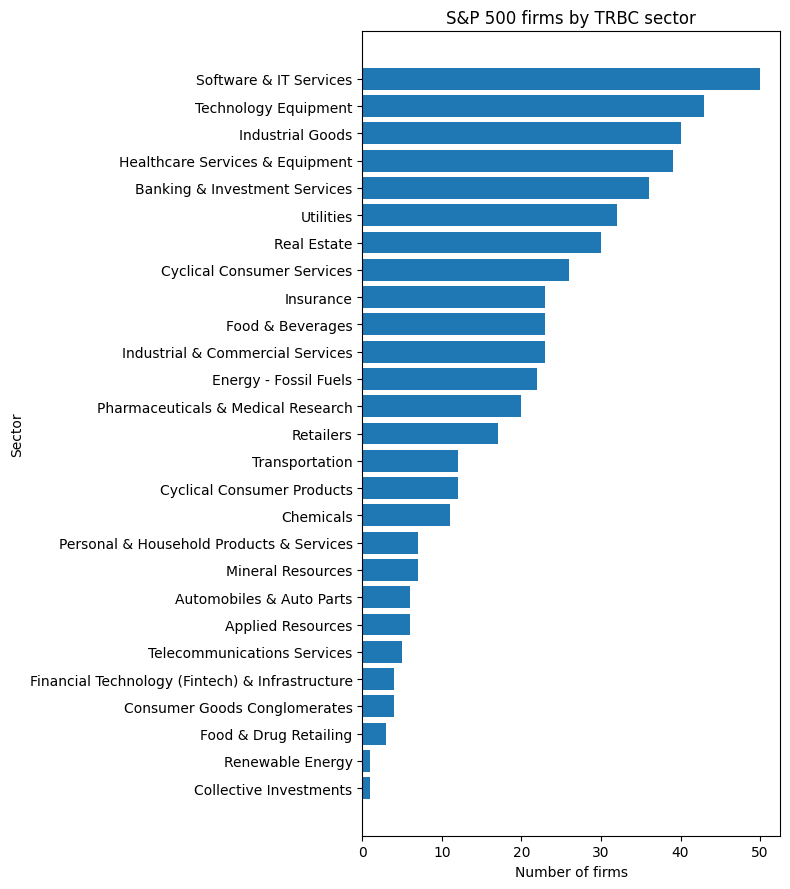

```python
import pandas as pd
import matplotlib.pyplot as plt

# Load data
df = pd.read_csv("sp500_constituents_trbc.csv")

# Count sectors (handle missing values)
counts = df["TRBC Business Sector Name"].fillna("Unclassified").value_counts().sort_values()

# Plot
plt.figure(figsize=(8, 9))
plt.barh(counts.index, counts.values)

# Labels and title
plt.title("S&P 500 firms by TRBC sector")
plt.xlabel("Number of firms")
plt.ylabel("Sector")

plt.tight_layout()
plt.show()
```

**Application.** Now it is your turn to practice. For all the constituent of the STOXX 600, collect the country of heaqquarter, then show a a pie chart of the country repartition. A solution is provided below (click to unhide it). For more information on pie chart with plt, see [here](https://matplotlib.org/stable/gallery/pie_and_polar_charts/pie_featur).

```
    Instrument       RIC Company Common Name Country of Headquarters
0        SSE.L     SSE.L             SSE PLC          United Kingdom
1       AAK.ST    AAK.ST       AAK AB (publ)                  Sweden
2        SDR.L     SDR.L       Schroders PLC          United Kingdom
3      SASY.PA   SASY.PA           Sanofi SA                  France
4     NSISb.CO  NSISb.CO       Novozymes A/S                 Denmark
..         ...       ...                 ...                     ...
595   NOKIA.HE  NOKIA.HE           Nokia Oyj                 Finland
596    CAMX.ST   CAMX.ST          Camurus AB                  Sweden
597    SPIE.PA   SPIE.PA             Spie SA                  France
598      NXT.L     NXT.L            Next PLC          United Kingdom
599    FDJU.PA   FDJU.PA          FDJ United                  France

[600 rows x 4 columns]
```

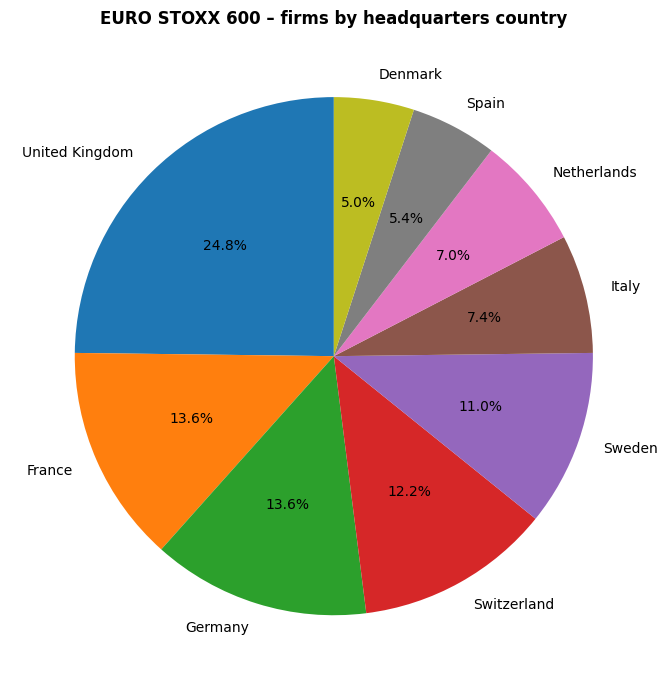

```python
import matplotlib.pyplot as plt
import refinitiv.data as rd

# Retrieve constituents of STOXX + country
rd.open_session()
constituents = rd.get_data(
    universe=["0#.STOXX"],
    fields=["TR.RIC", "TR.CommonName","TR.HeadquartersCountry"]
)
print(constituents)
rd.close_session()

# Count firms by country
country_counts = (
    constituents["Country of Headquarters"]
    .fillna("Unknown")  # fillna() replaces missing values (NaN) with a specified value
    .value_counts()
    .sort_values(ascending=False)
)

#keep only if at least 20 obs for a country
country_counts = country_counts[country_counts>=20]

# Pie chart of country distribution
plt.figure(figsize=(7, 7))
plt.pie(
    country_counts.values,
    labels=country_counts.index,
    autopct="%1.1f%%",
    startangle=90,
)
plt.title("EURO STOXX 600 firms by headquarters country", fontweight="bold")
plt.tight_layout()
plt.show()
```

### 3.2. Time-series plot — CAC 40 index level

A **time-series plot** shows how a variable evolves over time. We download daily closing prices for the CAC 40 (`.FCHI`) and plot the index level along with a **60-day moving average** — a smoothed line that shows the trend by averaging the last 60 trading days at each point.

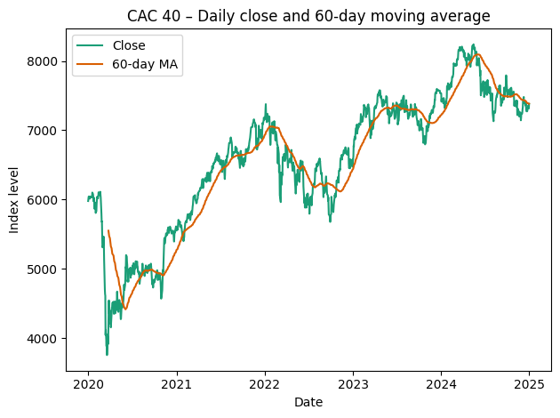

```python
import matplotlib.pyplot as plt
import refinitiv.data as rd
rd.open_session()
# get data
hist = rd.get_history(
    universe=".FCHI",
    fields=["TR.PriceClose"],
    interval="1D",
    start="2020-01-01",
    end="2024-12-31")
rd.close_session()

# Compute a 60-day rolling (moving) average of the closing price.
# .rolling(window=60) looks at the last 60 observations at each date.
# .mean() computes the average of those 60 observations.
hist["MA60"] = hist["Price Close"].rolling(window=60).mean()

# Plot.
plt.figure()
plt.plot(hist.index, hist["Price Close"], label="Close", color="#1B9E77")
plt.plot(hist.index, hist["MA60"], label="60-day MA", color="#D95F02")
plt.title("CAC 40 – Daily close and 60-day moving average")
plt.xlabel("Date")
plt.ylabel("Index level")
plt.legend()
plt.tight_layout()
plt.show()
```

**Application.** Now it is your turn to practice. Collect and plot NVIDIA daily stock price over 2024. Show dots (in blue) and not a line. A (hidden) solution is provided below.

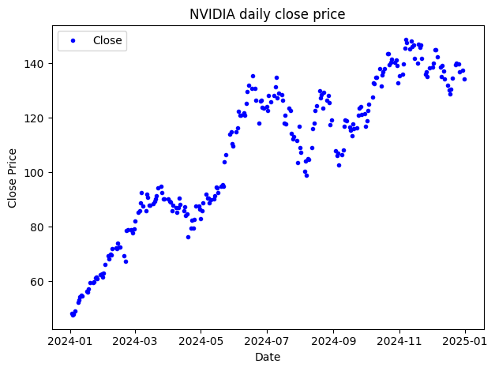

```python
import matplotlib.pyplot as plt
import refinitiv.data as rd
#open session
rd.open_session()  # rd.open_session() starts an authenticated connection to Refinitiv/LSEG (needed before queries)
# get data
hist = rd.get_history(
    universe="NVDA.O",
    fields=["TR.PriceClose"],
    interval="1D",
    start="2024-01-01",
    end="2024-12-31")
#close session
rd.close_session()
# Plot.
plt.figure()
plt.plot(  # plt.plot() draws a line plot with matplotlib
    hist.index,
    hist["Price Close"],
    marker="o",  # keyword argument: set the parameter 'marker' for the function call
    linestyle="none",  # keyword argument: set the parameter 'linestyle' for the function call
    color="blue",  # keyword argument: set the parameter 'color' for the function call
    markersize=3,  # keyword argument: set the parameter 'markersize' for the function call
    label="Close",  # keyword argument: set the parameter 'label' for the function call
)
plt.title("NVIDIA daily close price")
plt.xlabel("Date")
plt.ylabel("Close Price")
plt.legend()
plt.tight_layout()
plt.show()
```

### 3.3. Distribution of profitability (ROA) — boxplot and histogram

We now look at the **cross-sectional distribution of ROA** (Return on Assets) across S&P 500 firms using two standard plots.

**Boxplot — what it is and how to read it:**

- The horizontal line inside the box is the **median** (50th percentile) — the "typical" value.
- The bottom and top of the box are the **25th** and **75th** percentiles (Q1 and Q3). The height of the box is the **interquartile range (IQR)**.
- The **whiskers** extend from Q1 down and from Q3 up to the most extreme non-outlier values.
- Individual dots beyond the whiskers are **outliers** — firms with unusually low or high ROA.

Together, these two plots let us quickly see where most firms lie (central tendency), how dispersed profitability is, whether there are extreme winners or losers, and whether the distribution is symmetric or skewed.

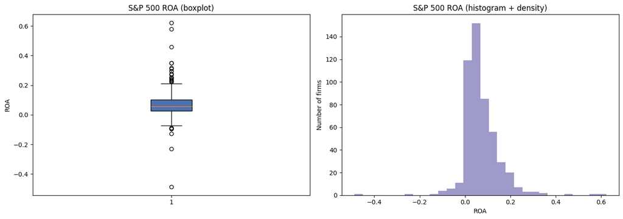

```python
import pandas as pd
import matplotlib.pyplot as plt
import refinitiv.data as rd

rd.open_session()

# Reuse the S&P 500 RIC list
sp500_constituents = pd.read_csv("sp500_constituents_trbc.csv")
rics_sp500 = sp500_constituents["RIC"].tolist()

# Download net income and total assets to compute ROA.
fundamentals_roa = rd.get_data(
    universe=rics_sp500,
    fields=["TR.NETINCOME", "TR.TOTALASSETS"])
rd.close_session()

# Compute ROA = Net income / Total assets.
fundamentals_roa["ROA"] = fundamentals_roa["Net Income Incl Extra Before Distributions"] / fundamentals_roa["Total Assets"]
roa = fundamentals_roa["ROA"].dropna()

# Save ROA cross section
roa.to_csv("sp_roa_cross.csv")

# Create side-by-side plots.
fig, axes = plt.subplots(1, 2, figsize=(14, 5))

# Left panel: boxplot.
axes[0].boxplot(roa, vert=True, patch_artist=True,
                boxprops=dict(facecolor="#4C72B0"))
axes[0].set_title("S&P 500 ROA (boxplot)")
axes[0].set_ylabel("ROA")

# Right panel: histogram
axes[1].hist(roa, bins=30, color="#7570B3", alpha=0.7)
axes[1].set_title("S&P 500 ROA (histogram + density)")
axes[1].set_xlabel("ROA")
axes[1].set_ylabel("Number of firms")

plt.tight_layout()
plt.show()
```

**Interpretation of the ROA plots:**

The boxplot shows that the median ROA is positive but modest — a typical S&P 500 firm earns a small positive return on its assets. The height of the box (IQR) indicates meaningful dispersion: some firms are clearly more profitable than others. The whiskers and dots reveal outliers on both sides — a few firms with very negative ROA (loss-making) and a few with very high ROA.

**Application.** Now it is your turn to practice. Collect S&P and Bitcoin daily return since creation and create + comment there boxplot. A (hidden) solution is provided below.

```python
import matplotlib.pyplot as plt
import refinitiv.data as rd
rd.open_session()
# Download daily BID and ASK for Bitcoin.
crypto_daily = rd.get_history(
    universe="BTC=",
    fields=["BID", "ASK"],
    interval="daily",
    start="2014-01-01",
    end="2024-12-31"
)
# Download daily BID and ASK for SP.
sp_daily = rd.get_history(
    universe=".SPXTR",
    fields=["TR.PriceClose"],
    interval="daily",
    start="2014-01-01",
    end="2024-12-31"
)
rd.close_session()

# Compute the bid-ask spread.
crypto_daily["RET"] = crypto_daily["ASK"].pct_change()
print(crypto_daily.head())  # print() outputs text/values to the screen (useful for checking results)
sp_daily["RET"] = sp_daily["Price Close"].pct_change()
print(sp_daily.head())  # print() outputs text/values to the screen (useful for checking results)

# Save to CSV.
crypto_daily.to_csv("crypto_daily_full.csv")
sp_daily.to_csv("sp_daily_full.csv")
```

```
BTC=           BID     ASK       RET
Date
2014-07-17  623.01   626.3      <NA>
2014-07-18   629.7  631.84  0.008846
2014-07-19  627.53   630.0 -0.002912
2014-07-20  624.66  626.99 -0.004778
2014-07-21   620.0  622.23 -0.007592
.SPXTR      Price Close       RET
Date
2013-12-31    3315.5852      <NA>
2014-01-02    3286.6873 -0.008716
2014-01-03    3285.6831 -0.000306
2014-01-06    3277.4834 -0.002496
2014-01-07    3297.4492  0.006092
```

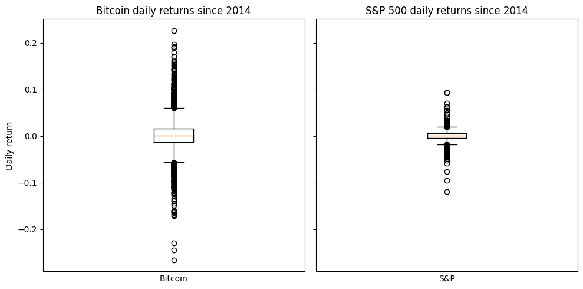

```python
import pandas as pd
import matplotlib.pyplot as plt
# get data
btc_hist = pd.read_csv("crypto_daily_full.csv")
sp_hist  = pd.read_csv("sp_daily_full.csv")
# prep figure
fig, axes = plt.subplots(1, 2, figsize=(10, 5), sharey=True)
# Left: Bitcoin
axes[0].boxplot(btc_hist["RET"].dropna(), vert=True)  # dropna() removes rows/columns with missing values
axes[0].set_title("Bitcoin daily returns since 2014")
axes[0].set_ylabel("Daily return")
axes[0].set_xticks([])
axes[0].set_xlabel("Bitcoin")
# Right: S&P 500
axes[1].boxplot(sp_hist["RET"].dropna(), vert=True)  # dropna() removes rows/columns with missing values
axes[1].set_title("S&P 500 daily returns since 2014")
axes[1].set_xticks([])
axes[1].set_xlabel("S&P")
# show graph
plt.tight_layout()
plt.show()
```

## 4. Data Cleaning and Summary Statistics

### 4.1. Winsorising and trimming

**SciPy — a scientific computing library for Python.** `scipy` is a foundational scientific Python library that builds on NumPy. It provides tools for optimisation, integration, interpolation, signal processing, linear algebra, and statistics. The sub-module used throughout this notebook is **`scipy.stats`**, which contains:

- Statistical distributions (normal, t, F, chi-squared, …)
- Hypothesis tests (t-tests, Mann–Whitney, Kolmogorov–Smirnov, …)
- Descriptive statistics and data transformations (winsorize, trim, …)

We import it with: `from scipy import stats`

SciPy documentation: https://docs.scipy.org/doc/scipy/reference/stats.html

Financial data often have **heavy tails**: a few firms report extremely high or low values (for example very negative ROA or enormous leverage). These extreme observations — called **outliers** — can dominate sample means and distort regression estimates.

Two standard tools for handling outliers:

- **Trimming** — Remove all observations below a chosen percentile (e.g. 1st) and above another (e.g. 99th). This discards the extremes entirely, which reduces sample size.
- **Winsorising** — Replace extreme values with the values at the chosen percentiles. For example, any value below the 1st percentile is set equal to the 1st percentile. This keeps the sample size intact but modifies the extreme values.

```python
# --- Imports needed for this cell (so it can run independently) ---
from scipy import stats  # SciPy stats includes statistical tests and distributions
# install package scipy if missing
!pip install scipy
```

```python
import scipy
help(scipy.stats.mstats.winsorize)
```

```
Help on function winsorize in module scipy.stats._mstats_basic:

winsorize(a, limits=None, inclusive=(True, True), inplace=False, axis=None, nan_policy='propagate')
    Returns a Winsorized version of the input array.

    The (limits[0])th lowest values are set to the (limits[0])th percentile,
    and the (limits[1])th highest values are set to the (1 - limits[1])th
    percentile.
    Masked values are skipped.


    Parameters
    ----------
    a : sequence
        Input array.
    limits : {None, tuple of float}, optional
        Tuple of the percentages to cut on each side of the array, with respect
        to the number of unmasked data, as floats between 0. and 1.
        Noting n the number of unmasked data before trimming, the
        (n*limits[0])th smallest data and the (n*limits[1])th largest data are
        masked, and the total number of unmasked data after trimming
        is n*(1.-sum(limits)) The value of one limit can be set to None to
        indicate an open interval.
    inclusive : {(True, True) tuple}, optional
        Tuple indicating whether the number of data being masked on each side
        should be truncated (True) or rounded (False).
    inplace : {False, True}, optional
        Whether to winsorize in place (True) or to use a copy (False)
    axis : {None, int}, optional
        Axis along which to trim. If None, the whole array is trimmed, but its
        shape is maintained.
    nan_policy : {'propagate', 'raise', 'omit'}, optional
        Defines how to handle when input contains nan.
        The following options are available (default is 'propagate'):

          * 'propagate': allows nan values and may overwrite or propagate them
          * 'raise': throws an error
          * 'omit': performs the calculations ignoring nan values

    Notes
    -----
    This function is applied to reduce the effect of possibly spurious outliers
    by limiting the extreme values.

    Examples
    --------
    >>> import numpy as np
    >>> from scipy.stats.mstats import winsorize

    A shuffled array contains integers from 1 to 10.

    >>> a = np.array([10, 4, 9, 8, 5, 3, 7, 2, 1, 6])

    The 10% of the lowest value (i.e., `1`) and the 20% of the highest
    values (i.e., `9` and `10`) are replaced.

    >>> winsorize(a, limits=[0.1, 0.2])
    masked_array(data=[8, 4, 8, 8, 5, 3, 7, 2, 2, 6],
                 mask=False,
           fill_value=999999)
```

```python
import scipy  # import statement: makes external code (a module/package) available in this cell
help(scipy.stats.mstats.trimboth)
```

```
Help on function trimboth in module scipy.stats._mstats_basic:

trimboth(data, proportiontocut=0.2, inclusive=(True, True), axis=None)
    Trims the smallest and largest data values.

    Trims the `data` by masking the ``int(proportiontocut * n)`` smallest and
    ``int(proportiontocut * n)`` largest values of data along the given axis,
    where n is the number of unmasked values before trimming.

    Parameters
    ----------
    data : ndarray
        Data to trim.
    proportiontocut : float, optional
        Percentage of trimming (as a float between 0 and 1).
        If n is the number of unmasked values before trimming, the number of
        values after trimming is ``(1 - 2*proportiontocut) * n``.
        Default is 0.2.
    inclusive : {(bool, bool) tuple}, optional
        Tuple indicating whether the number of data being masked on each side
        should be rounded (True) or truncated (False).
    axis : int, optional
        Axis along which to perform the trimming.
        If None, the input array is first flattened.
```

We now apply winsorising and trimming to the **S&P 500 ROA** data from Section 3.3.

```python
import pandas as pd
from scipy.stats.mstats import winsorize, trimboth
# Raw ROA from Section 3.4.
roa = pd.read_csv("sp_roa_cross.csv")
# Make sure ROA is numeric; turn non-numeric entries into NaN and drop them
roa_raw = pd.to_numeric(roa["ROA"], errors="coerce").dropna()
# Summary statistics to see outliers
print(roa_raw.describe(percentiles=[0.01, 0.05, 0.95, 0.99]))
# 1%–99% winsorising and trimming using scipy
roa_wins = pd.Series(
    winsorize(roa_raw, limits=(0.01, 0.01)),
    index=roa_raw.index,
    name="ROA_wins"
)

roa_trim = pd.Series(
    trimboth(roa_raw.to_numpy(), proportiontocut=0.01).compressed(),
    name="ROA_trim"
)
# prints
print("\nWinsorised ROA summary (1–99% caps):")
print(roa_wins.describe(percentiles=[0.01, 0.05, 0.95, 0.99]))
print("\nTrimmed ROA summary (1–99% retained):")
print(roa_trim.describe(percentiles=[0.01, 0.05, 0.95, 0.99]))
```

```
count    503.000000
mean       0.070810
std        0.080060
min       -0.487860
1%        -0.092501
5%        -0.001237
50%        0.056353
95%        0.190715
99%        0.316098
max        0.622747
Name: ROA, dtype: float64

Winsorised ROA summary (1–99% caps):
count    503.000000
mean       0.070387
std        0.067479
min       -0.092614
1%        -0.092501
5%        -0.001237
50%        0.056353
95%        0.190715
99%        0.316098
max        0.316186
Name: ROA_wins, dtype: float64

Trimmed ROA summary (1–99% retained):
count    493.000000
mean       0.069548
std        0.061330
min       -0.092614
1%        -0.057046
5%         0.002203
50%        0.056353
95%        0.186899
99%        0.254205
max        0.316186
Name: ROA_trim, dtype: float64
```

### 4.2. Summary statistics table

The method `DataFrame.describe()` (and `Series.describe()`) in pandas produces a quick statistical summary of your data.

For **numeric columns**, it typically shows:

- `count` – number of non-missing observations
- `mean` – average value
- `std` – standard deviation
- `min` – minimum value
- `25%`, `50%`, `75%` – quartiles (median is 50%)
- `max` – maximum value

For **categorical / object columns**, it shows:

- `count` – number of non-missing values
- `unique` – number of distinct categories
- `top` – most frequent category
- `freq` – frequency of that category

You can call it on a DataFrame or a single column:

`df.describe()` `df["ROA"].describe()`

```python
import pandas as pd
# get roa data
roa_raw= pd.read_csv("sp_roa_cross.csv")
# Make sure ROA is numeric; turn non-numeric entries into NaN
roa_raw = pd.to_numeric(roa["ROA"], errors="coerce")
# Build summary statistics using pandas .describe(), then combine side by side.
roa_raw.describe()
```

```
count    503.000000
mean       0.070810
std        0.080060
min       -0.487860
25%        0.027079
50%        0.056353
75%        0.102481
max        0.622747
Name: ROA, dtype: float64
```

## 5. Hypothesis Testing with T-tests

Imagine you measure the ROA of 200 companies and get a mean of 5%. The question is: **is that 5% genuinely different from zero, or could it just be random noise?**

A **t-test** answers exactly that. It compares your sample mean against a reference value (usually 0) and tells you how surprising your result would be if there were actually nothing going on.

### 5.1. The null hypothesis

Before running any test, you define what "nothing going on" looks like. This is the **null hypothesis (H₀)** — your default assumption that you are trying to disprove.

For ROA:

- **H₀**: mean ROA = 0 — companies generate no return on assets (nothing going on).
- **H₁** (the alternative): mean ROA ≠ 0 — companies do generate a meaningful return (something going on).

The t-test then asks: *"if H₀ were true, how likely is it that I'd see a mean this far from zero just by chance?"* If that probability is very small (below 5%, which we write as p-value < 0.05), H₀ looks implausible and we **reject** it in favour of H₁. If not, we **fail to reject H₀** — we simply do not have enough evidence against it.

The **p-value** is the probability of observing a sample mean as extreme as ours (or more extreme) if H₀ were true. It answers the question: assuming the population mean really is zero, how likely is it that random sampling alone would produce the result we got? A small p-value (below 0.05) means our result would be very unlikely under H₀ — so we reject it. A large p-value means a result like ours could easily happen by chance — so we have no reason to reject H₀.

**Important:** failing to reject H₀ does **not** mean H₀ is true. It only means we cannot rule it out with the data at hand.

### 5.2. Applying the t-test to S&P 500 ROA

**Research question:** Is the average ROA of S&P 500 companies significantly different from zero?

- H₀: mean ROA = 0 (companies generate no return on assets).
- H₁: mean ROA ≠ 0.

We run a **one-sample t-test** using `scipy.stats.ttest_1samp()`, which takes a data array and a null mean (`popmean=0`) and returns the t-statistic and p-value. We apply it to the raw, winsorised, and trimmed versions of ROA.

```python
import pandas as pd
import refinitiv.data as rd
from scipy import stats

# Load ROA
roa_raw = pd.read_csv("sp_roa_cross.csv")
roa_clean = roa_raw.dropna()

# ── One-sample t-test (H0: mean = 0) ───────────────────────────────────────
print("="*50)
t_stat, p_value = stats.ttest_1samp(roa_clean["ROA"], popmean=0)
print("Raw ROA", roa_clean.mean().round(2), " p = ", p_value.round(4))
```

```
==================================================
Raw ROA Unnamed: 0    251.00
ROA             0.07
dtype: float64  p =  0.0
```

**Interpretation:** ROA has a **positive mean** (7%) with a p-value well below 0.05, so we reject H₀. The 7% mean is statistically different from a 0% mean. The average S&P 500 firm earns a statistically significant positive return on its assets.

### 5.3. One-sided vs two-sided tests

So far we tested whether mean ROA is **different** from zero (two-sided: H₁: mean ≠ 0). But sometimes we have a **directional** hypothesis — for example, "ROA is positive" rather than just "ROA is not zero".

| Hypothesis | H₀ | H₁ | When to use |
| --- | --- | --- | --- |
| Two-sided | mean = 0 | mean ≠ 0 | "Is ROA different from zero?" |
| One-sided right | mean ≤ 0 | mean > 0 | "Is ROA positive?" |
| One-sided left | mean ≥ 0 | mean < 0 | "Is ROA negative?" |

In a one-sided test, you put all 5% of your significance budget into **one tail** instead of splitting it 2.5% / 2.5%. This makes it easier to detect an effect in the expected direction but you completely ignore the other direction.

```python
import pandas as pd
from scipy import stats
import refinitiv.data as rd

# Load ROA
roa_raw = pd.read_csv("sp_roa_cross.csv")
roa_clean = roa_raw.dropna()

# ── One-sample t-test (H₀: μ = 0  vs  H₁: μ > 0) ─────────────────────────
t_stat, p_two = stats.ttest_1samp(roa_clean["ROA"], popmean=0)
p_value = p_two / 2 if t_stat > 0 else 1 - p_two / 2   # right-tailed p-value
print(f"Raw ROA {roa_clean.mean().round(2)} % |  p (one-sided) = {p_value:.4f}")
```

```
Raw ROA Unnamed: 0    251.00
ROA             0.07
dtype: float64 % |  p (one-sided) = 0.0000
```

**Interpretation:** Even more statistically significant. We reject the null (mean=0) in favor of the alternative (mean>0).

### 5.4. Two-sample t-test — comparing two groups

So far we tested one group against a fixed value. Now we compare **two independent groups** against each other:

- H₀: mean_A = mean_B (no difference between the groups).
- H₁: mean_A ≠ mean_B (the groups differ).

We use the package **pingouin** to run the t-test on the equality of the two sample means.

We apply the two-sample t-test to real data. We split S&P 500 firms into **high-ESG** (score ≥ sample median) and **low-ESG** (score < median) groups and test whether the two groups differ in ROA, leverage, market-to-book, and firm size.

```python
#if the package pingouin is not installed do :
%pip install pingouin
```

```python
import pandas as pd
import numpy as np
import refinitiv.data as rd
import pingouin as pg

# get S&P constituents
sp500_constituents = pd.read_csv("sp500_constituents_trbc.csv")
rics_sp500 = sp500_constituents["RIC"].dropna().tolist()

rd.open_session()
panel = rd.get_data(
    universe=rics_sp500,
    fields=[
        "TR.NetIncome", "TR.TotalAssets", "TR.TotalDebt",
        "TR.CompanyMarketCap", "TR.F.ComEqTot", "TR.TRESGScore"
    ]
)
rd.close_session()

# generate variables
panel["roa"] = panel["Net Income Incl Extra Before Distributions"] / panel["Total Assets"]
panel["leverage"] = panel["Total Debt"] / panel["Total Assets"]
panel["size_ln"] = np.log(panel["Company Market Cap"])
panel["mtb"] = panel["Company Market Cap"] / panel["Common Equity - Total"]

# ESG groups
panel=panel.dropna()
panel["Group"] = np.where(panel["ESG Score"] >= panel["ESG Score"].median(), "High ESG", "Low ESG")

# long format
df_long = panel.melt(
    id_vars="Group",
    value_vars=["roa", "leverage", "mtb", "size_ln"],
    var_name="Variable",
    value_name="Value"
).dropna()

# simple package-based grouped t-tests
ttest_table = df_long.groupby("Variable").apply(
    lambda g: pg.ttest(
        g.loc[g["Group"] == "High ESG", "Value"],
        g.loc[g["Group"] == "Low ESG", "Value"]
    )
).reset_index()

print(ttest_table)
```

```
   Variable level_1         T  dof alternative     p_val             CI95  \
0  leverage  T_test  1.269652  494   two-sided  0.204806    [-0.02, 0.07]
1       mtb  T_test  0.199097  494   two-sided  0.842269  [-12.16, 14.91]
2       roa  T_test -0.960795  494   two-sided  0.337125    [-0.02, 0.01]
3   size_ln  T_test  3.157965  494   two-sided  0.001686     [0.12, 0.53]

    cohen_d     power    BF10
0  0.114018  0.244849   0.218
1  0.017879  0.054535   0.102
2  0.086282  0.160161   0.156
3  0.283594  0.883341  12.203
```

**Interpretation:** The table compares **High-ESG** vs **Low-ESG** S&P 500 firms (about 250 in each group) on four variables.

**Takeaway:**  
Only **firm size (log market cap)** shows a statistically significant difference between High- and Low-ESG firms. For **ROA, leverage, and market-to-book**, there is no statistically significant difference, and the effect sizes are small. This suggests that ESG differences are primarily associated with firm size rather than profitability, leverage, or valuation.

### 5.5. Explaining performance during the COVID crisis

**Application.** Now it is your turn to practice. You are asked to examine whether standard characteristics of firms that performed well versus badly during the COVID crisis are statistically different, setting the ground for some hypothesis testing down the road. The universe of interest is the **CAC All** Tradable. Consider as many variables as you deem relevant ex ante to explain performance during this crisis (financial constraints, ESG score). Do ttest to see whether in the group of firms with high versus low performance during the COVID crisis the firm characteristics are statistically significant.

To help you, building on the following [paper](https://papers.ssrn.com/sol3/papers.cfm?abstract_id=3616734), we set the COVID crisis period in France as **February 20 to March 16 2020**. You can also use that paper to guide your choice of the frim characteristics to consider. A (hidden) solution is provided below.

```python
import pandas as pd
import numpy as np
from scipy import stats
import refinitiv.data as rd

rd.open_session()
# ── Retrieve CAC All Tradable constituents ────────────────────────────────
# '0#.CACT' is the chain RIC that lists every member of the CAC All Tradable.
constituents = rd.get_data(
    universe=["0#.CACT"],
    fields=["TR.RIC", "TR.CommonName", "TR.GICSSector"])

print(constituents.head())
constituents.to_csv("cacall_constituents.csv") #save
```

```
  Instrument      RIC                    Company Common Name  \
0    SGEF.PA  SGEF.PA                               Vinci SA
1    SOPR.PA  SOPR.PA                  Sopra Steria Group SA
2    ABNX.PA  ABNX.PA                      Abionyx Pharma SA
3    EEPC.PA  EEPC.PA  Soc D Explosifs Produits Chimiques SA
4    CAPP.PA  CAPP.PA                           Capgemini SE

         GICS Sector Name
0             Industrials
1  Information Technology
2             Health Care
3               Materials
4  Information Technology
```

```python
# Clean the RIC list: remove empty or missing RICs.
rics = constituents["RIC"].dropna().replace("", pd.NA).dropna().tolist()

# ── Download daily prices to compute COVID crisis returns ─────────────────
# The COVID crisis period for France is February 20 to March 16, 2020
crisis_raw = rd.get_data(
    universe=rics,
    fields=["TR.TotalReturn"],
    parameters={"SDate": "2020-02-20", "EDate": "2020-03-16"})

print(crisis_raw)
crisis_raw.to_csv("cacall_covid_returns.csv") #save
```

```
    Instrument  Total Return
0      SGEF.PA    -43.878327
1      SOPR.PA      -34.0625
2      ABNX.PA    -53.807107
3      EEPC.PA     -8.450704
4      CAPP.PA    -44.719894
..         ...           ...
201   LBIRD.PA    -45.686901
202   ELIOR.PA    -61.950856
203    MAAT.PA          <NA>
204    SASY.PA    -18.074866
205   ARAMI.PA          <NA>

[206 rows x 2 columns]
```

```python
# ── Download pre-crisis firm characteristics ──────────────────────────────
#   - Financial flexibility: Total Debt / Assets, Cash / Assets, Profitability (EBITDA / Assets)
#   - ESG Score
#   - Size: Market Capitalisation
rd.open_session()

fields_chars = [  # variable assignment: store a value in 'fields_chars' so we can reuse it later
    "TR.TotalDebt",
    "TR.F.CashSTInvst",
    "TR.EBITDA",
    "TR.TotalAssets",
    "TR.TotalAssets.Date",
    "TR.CompanyMarketCap",
    "TR.TRESGScore",
]

# We retrieve data for fiscal year 2019 (pre-crisis).
params = {"Period": "FY2019"}

raw_chars = rd.get_data(
    universe=rics,
    fields=fields_chars,
    parameters=params)

rd.close_session()

# print
print(raw_chars)

# save
raw_chars.to_csv("cacall_covid_chars.csv")
```

```
    Instrument   Total Debt  Cash & Short Term Investments        EBITDA  \
0      SGEF.PA  32373000000                     8597000000  8471000000.0
1      GTCN.PA     16024000                       33185000     1316000.0
2      SOPR.PA   1053600000                      197500000   507400000.0
3      ABNX.PA      1183000                        8331000    -2453000.0
4       ASY.PA    115600000                       29200000    47100000.0
..         ...          ...                            ...           ...
201    CASP.PA  15115000000                     3611000000  2646000000.0
202     ETL.PA   4430900000                     1538800000  1075500000.0
203    SWOR.PA     17964000                       71657000    28580000.0
204    SMCP.PA    943766000                       52329000   284027000.0
205    DTNC.PA      4637300                         829047      768880.0

     Total Assets       Date  Company Market Cap  ESG Score
0     91159000000 2019-12-31  75753829358.797195  84.644589
1        95049000 2019-12-31     64428659.937884       <NA>
2      4546200000 2019-12-31    2474624483.82607  59.171279
3        10249000 2019-12-31    118956813.979985       <NA>
4       717100000 2019-12-31    643570160.876803   37.00878
..            ...        ...                 ...        ...
201   35948000000 2019-12-31     68832153.314092  74.049711
202    8291600000 2019-06-30    2419943461.78551  66.752827
203     257297000 2019-12-31    294043750.447408       <NA>
204    2549344000 2019-12-31    416995451.873656   54.58356
205      14128280 2019-12-31       2875548.53366       <NA>

[206 rows x 8 columns]
```

```python
# ── Build the analysis dataset ────────────────────────────────────────────
# check columns names
panel=raw_chars
print(panel.columns)

# Construct financial ratios.
panel["leverage"]     = panel["Total Debt"] / panel["Total Assets"]
panel["cash_ratio"]   = panel["Cash & Short Term Investments"] / panel["Total Assets"]
panel["profitability"] = panel["EBITDA"] / panel["Total Assets"]
panel["size_ln"]      = np.log(panel["Company Market Cap"])

# Merge crisis returns with firm characteristics.
df = pd.merge( crisis_raw, panel, on="Instrument",  how="inner")
```

[output not shown]

```python
# get industry
rd.open_session()
fields_chars = ["TR.TRBCECONOMICSECTOR"]
ind = rd.get_data(
    universe=rics,
    fields=fields_chars,
)
rd.close_session()

#add it
df=df.merge(ind,on="Instrument")

# rename
df= df.rename(columns={"TRBC Economic Sector Name":"industry"})

# Print
print(df)

# Save
df.to_csv("cacall_datasets_full.csv")
```

```
    Instrument  Total Return   Total Debt  Cash & Short Term Investments  \
0      SGEF.PA    -43.878327  32373000000                     8597000000
1      GTCN.PA    -31.623932     16024000                       33185000
2      SOPR.PA      -34.0625   1053600000                      197500000
3      ABNX.PA    -53.807107      1183000                        8331000
4       ASY.PA    -46.356589    115600000                       29200000
..         ...           ...          ...                            ...
201    CASP.PA    -14.130131  15115000000                     3611000000
202     ETL.PA    -32.948422   4430900000                     1538800000
203    SWOR.PA    -33.663366     17964000                       71657000
204    SMCP.PA    -51.483871    943766000                       52329000
205    DTNC.PA    -50.057803      4637300                         829047

           EBITDA  Total Assets       Date  Company Market Cap  ESG Score  \
0    8471000000.0   91159000000 2019-12-31  75753829358.797195  84.644589
```

[output cut: 25 more lines]

```python
import pingouin as pg

panel  = pd.read_csv("cacall_datasets_full.csv")

panel["Group"] = np.where(
    panel["Total Return"] >= panel["Total Return"].median(),
    "Above", "Below"
)

df_long = panel.melt(
    id_vars="Group",
    value_vars=["leverage", "cash_ratio", "profitability", "size_ln"],
    var_name="Variable",
    value_name="Value"
).dropna()

ttest_table = df_long.groupby("Variable").apply(
    lambda g: pg.ttest(
        g.loc[g["Group"] == "Above", "Value"],
        g.loc[g["Group"] == "Below", "Value"]
    )
).reset_index()

print(ttest_table.to_string(index=False))
```

```
     Variable level_1         T        dof alternative    p_val          CI95  cohen_d    power  BF10
   cash_ratio  T_test -1.047119 179.780311   two-sided 0.296451 [-0.07, 0.02] 0.147171 0.178270 0.258
     leverage  T_test  0.145600 189.455626   two-sided 0.884392 [-0.06, 0.07] 0.020604 0.052443 0.154
profitability  T_test  0.759779 197.909901   two-sided 0.448291 [-0.03, 0.08] 0.106231 0.116638 0.201
      size_ln  T_test  0.710579 200.804882   two-sided 0.478170  [-0.42, 0.9] 0.099383 0.108952 0.193
```

## 6. Regression Analysis

### 6.1. What is a univariate regression?

A **univariate (simple) regression** models the linear relationship between one dependent variable Y (what you want to explain) and one independent variable X (what you think explains Y):

$$Y = \alpha + \beta X + \varepsilon$$

- $\alpha$ (intercept): the predicted value of Y when X = 0.
- $\beta$ (slope): how much Y changes for a one-unit increase in X. This is the key number.
- $\varepsilon$ (residual): the part of Y that the model cannot explain — random noise.

**OLS (Ordinary Least Squares)** finds the line that minimises the sum of squared residuals — the vertical distances between each data point and the fitted line.

Key regression outputs:

| Output | Meaning | Rule of thumb |
| --- | --- | --- |
| $\beta$ (slope) | Effect of X on Y | Sign = direction, size = magnitude |
| t-statistic | Is $\beta$ significantly different from 0? | \|t\| > 2 → likely significant |
| p-value | Probability of observing this $\beta$ if true $\beta$ = 0 | p < 0.05 → significant |
| R² | Fraction of Y's variance explained by X | 0 = nothing explained, 1 = perfect |
| 95% CI | Range where the true $\beta$ likely falls | If it excludes 0 → significant |

**How OLS finds the regression line** : The residual for observation $i$ is $e_i = Y_i - (\alpha + \beta X_i)$. OLS picks the $\alpha$ and $\beta$ that minimise the Sum of Squared Residuals:

$$SSR = \sum_{i=1}^{n} e_i^2$$

Why squared? So that positive and negative errors do not cancel out, and large errors are penalised more heavily.

### 6.2. Application — Regression of ROA on leverage

**statsmodels — a Python package for statistical models.** `statsmodels` is the standard Python library for estimating regression models and running statistical tests. The module we import is `statsmodels.api` (aliased as `sm`). The main tools we use are:

- **`sm.OLS(y, X)`** — creates an Ordinary Least Squares regression object.
- **`.fit()`** — estimates the model parameters.
- **`.summary()`** — prints a detailed output table (coefficients, standard errors, t-statistics, p-values, R²).
- **`sm.add_constant(X)`** — adds a column of 1s to the regressor matrix so that the model includes an intercept ($\\alpha$).

We import it with: `import statsmodels.api as sm`

statsmodels documentation: https://www.statsmodels.org/stable/index.html

We now test one of the most studied relationships in corporate finance: **does higher leverage (debt) lead to lower profitability (ROA)?**

Three competing theories make different predictions:

1. **Static trade-off theory:** Modigliani & Miller (1963) showed that interest tax shields make debt valuable. Later work (Kraus & Litzenberger, 1973) added that excessive debt also raises financial distress costs. Balancing the two forces predicts an optimal debt level — an inverted-U relationship between leverage and firm value.
2. **Agency theory (Jensen, 1986):** Debt disciplines managers, so more leverage could improve performance. Predicts a **positive** relationship.
3. **Pecking order theory (Myers & Majluf, 1984):** Firms borrow only when they are unable to fund investments internally — i.e. when profits are low. Predicts a **negative** relationship.

Most empirical studies on large US firms (e.g. Fama & French 1992, Frank & Goyal 2009) find a **negative** relationship, consistent with pecking order theory.

Our hypotheses: H₀: $\beta$ = 0 (leverage has no effect on ROA). H₁: $\beta$ < 0 (higher leverage → lower ROA). We test hypothesis in a similar way as for t-test, we look a the p-value attached to the coefficient of the regression, assess its statistical significance (usually at 5%) and conclude on whether we reject or not the null hypothesis (H₀).

```python
import pandas as pd
import statsmodels.api as sm
import refinitiv.data as rd

# ── 1. Load S&P 500 constituents from the CSV saved in Section 3.2 ───────────
sp500_constituents = pd.read_csv("sp500_constituents_trbc.csv")
rics_sp500 = sp500_constituents["RIC"].astype(str).tolist()

# ── 2. Download accounting data ──────────────────────────────────────────────
rd.open_session()
fundamentals = rd.get_data(
    universe=rics_sp500,
    fields=["TR.NETINCOME", "TR.TOTALASSETS", "TR.TOTALDEBT"])
rd.close_session()

#print(fundamentals.columns) #check variable names

# ── 3. Build ROA and leverage ─────────────────────────────────────────────────
fundamentals["roa"] = fundamentals["Net Income Incl Extra Before Distributions"] / fundamentals["Total Assets"]
fundamentals["leverage"] = fundamentals["Total Debt"] / fundamentals["Total Assets"]
fundamentals["roa"] = pd.to_numeric(fundamentals["roa"], errors="coerce")
fundamentals["leverage"] = pd.to_numeric(fundamentals["leverage"], errors="coerce")

# ── 4. OLS regression: ROA ~ leverage ─────────────────────────────────────────
reg_data = fundamentals[["roa", "leverage"]].apply(pd.to_numeric, errors="coerce").dropna().astype(float)
y = reg_data["roa"]
X = sm.add_constant(reg_data[["leverage"]]).astype(float)
model = sm.OLS(y, X).fit()
print(model.summary())
```

```
                            OLS Regression Results
==============================================================================
Dep. Variable:                    roa   R-squared:                       0.019
Model:                            OLS   Adj. R-squared:                  0.017
Method:                 Least Squares   F-statistic:                     9.450
Date:                Thu, 19 Mar 2026   Prob (F-statistic):            0.00223
Time:                        10:14:49   Log-Likelihood:                 561.26
No. Observations:                 502   AIC:                            -1119.
Df Residuals:                     500   BIC:                            -1110.
Df Model:                           1
Covariance Type:            nonrobust
==============================================================================
                 coef    std err          t      P>|t|      [0.025      0.975]
------------------------------------------------------------------------------
const          0.0567      0.006      9.884      0.000       0.045       0.068
leverage       0.0452      0.015      3.074      0.002       0.016       0.074
==============================================================================
Omnibus:                      170.341   Durbin-Watson:                   2.052
Prob(Omnibus):                  0.000   Jarque-Bera (JB):             3400.903
Skew:                           0.951   Prob(JB):                         0.00
Kurtosis:                      15.609   Cond. No.                         4.57
==============================================================================

Notes:
[1] Standard Errors assume that the covariance matrix of the errors is correctly specified.
```

```python
reg_data.describe() # df.describe() computes summary statistics for numeric columns
```

|  | roa | leverage |
| --- | --- | --- |
| count | 502.000000 | 502.000000 |
| mean | 0.070550 | 0.306908 |
| std | 0.079927 | 0.240815 |
| min | -0.487860 | 0.000000 |
| 25% | 0.027060 | 0.160520 |
| 50% | 0.056161 | 0.277430 |
| 75% | 0.102405 | 0.417539 |
| max | 0.622747 | 2.806251 |

### 6.3. Multivariate regression — two independent variables

In a univariate regression we asked: "does leverage explain ROA?" But ROA is driven by many factors simultaneously. A **multivariate regression** lets us test several explanatory variables at once:

$$ROA_i = \alpha + \beta_1 \cdot Leverage_i + \beta_2 \cdot ESG_i + \varepsilon_i$$

The key concept is **"holding everything else constant"**:

- $\beta_1$ = effect of leverage on ROA, **holding ESG constant**.
- $\beta_2$ = effect of ESG on ROA, **holding leverage constant**.

This is powerful because it separates the effect of each variable. Without controlling for ESG, the leverage coefficient might be **biased** — a phenomenon called **omitted variable bias**. For example, if high-ESG firms also have low leverage and high ROA, then a model without ESG would incorrectly attribute the ESG effect to leverage.

**Hypothesis on ESG:** A meta-analysis of over 2,000 studies (Friede et al. 2015) finds that ESG is positively related to financial performance in about 63% of studies. We test H₀: $\beta_2$ = 0 vs H₁: $\beta_2$ > 0.

```python
import pandas as pd
import statsmodels.api as sm
import refinitiv.data as rd

# ── 1. Download fundamentals + ESG ───────────────────────────────────────────
sp500_constituents = pd.read_csv("sp500_constituents_trbc.csv")
rics_sp500 = sp500_constituents["RIC"].astype(str).tolist()
rd.open_session()
fundamentals = rd.get_data(
    universe=rics_sp500,
    fields=["TR.NETINCOME", "TR.TOTALASSETS", "TR.TOTALDEBT", "TR.ESGScore"])
rd.close_session()
print(fundamentals.columns)
# ── 2. Build variables ────────────────────────────────────────────────────────
fundamentals["roa"]      = fundamentals["Net Income Incl Extra Before Distributions"] / fundamentals["Total Assets"]
fundamentals["leverage"] = fundamentals["Total Debt"] / fundamentals["Total Assets"]
fundamentals = fundamentals[["roa", "leverage", "LSEG ESG Score"]].dropna().astype(float)
# ── 3. Fit models ─────────────────────────────────────────────────────────────
m2    = sm.OLS(fundamentals["roa"], sm.add_constant(fundamentals[["leverage", "LSEG ESG Score"]])).fit()
print(m2.summary())
```

```
Index(['Instrument', 'Net Income Incl Extra Before Distributions',
       'Total Assets', 'Total Debt', 'LSEG ESG Score'],
      dtype='object')
                            OLS Regression Results
==============================================================================
Dep. Variable:                    roa   R-squared:                       0.020
Model:                            OLS   Adj. R-squared:                  0.016
Method:                 Least Squares   F-statistic:                     5.079
Date:                Thu, 19 Mar 2026   Prob (F-statistic):            0.00655
Time:                        10:14:56   Log-Likelihood:                 561.50
No. Observations:                 500   AIC:                            -1117.
Df Residuals:                     497   BIC:                            -1104.
Df Model:                           2
Covariance Type:            nonrobust
==================================================================================
                     coef    std err          t      P>|t|      [0.025      0.975]
----------------------------------------------------------------------------------
const              0.0751      0.018      4.215      0.000       0.040       0.110
leverage           0.0445      0.015      3.035      0.003       0.016       0.073
LSEG ESG Score    -0.0063      0.006     -1.047      0.296      -0.018       0.006
==============================================================================
Omnibus:                      172.294   Durbin-Watson:                   2.039
Prob(Omnibus):                  0.000   Jarque-Bera (JB):             3532.703
Skew:                           0.965   Prob(JB):                         0.00
Kurtosis:                      15.878   Cond. No.                         16.6
==============================================================================

Notes:
[1] Standard Errors assume that the covariance matrix of the errors is correctly specified.
```

```python
fundamentals.describe()  # df.describe() computes summary statistics for numeric columns
```

|  | roa | leverage | LSEG ESG Score |
| --- | --- | --- | --- |
| count | 500.000000 | 500.000000 | 500.000000 |
| mean | 0.070987 | 0.307278 | 2.802940 |
| std | 0.079594 | 0.241183 | 0.583497 |
| min | -0.487860 | 0.000000 | 0.579897 |
| 25% | 0.027098 | 0.160527 | 2.436193 |
| 50% | 0.056410 | 0.277430 | 2.865415 |
| 75% | 0.102447 | 0.418599 | 3.189116 |
| max | 0.622747 | 2.806251 | 4.358173 |

Bottom line: Leverage has a small but statistically significant positive association with ROA; ESG does not appear to have a meaningful relationship with profitability in this sample. The very low R² tells us that neither variable is a strong driver of cross-sectional ROA differences.

### 6.4. Correlation ≠ Causation

A regression can tell you that leverage and ROA move together — but it cannot, by itself, tell you that leverage *causes* ROA to change. The relationship could run the other way (profitable firms choose different leverage), or a third variable could drive both (e.g. firm size, industry, or management quality). This is the **endogeneity problem**, and it is the central challenge of empirical finance.

**Classic example:** ice cream sales and drowning deaths are highly correlated. The reason is not that ice cream kills people — it is that hot weather drives both. Without accounting for temperature (the confounder), a naive regression would suggest a causal link where none exists.

In corporate finance, the same logic applies everywhere. Do ESG scores improve profitability, or do already-profitable firms simply invest more in ESG? Does leverage boost returns, or do high-return firms take on more debt because they can? OLS alone cannot answer these questions.

Econometricians have developed several strategies to isolate causal effects. The most common in finance and accounting research are:

**Instrumental Variables (IV):** Find a variable (the "instrument") that affects the independent variable but has no direct effect on the outcome. For example, using a regulatory change that forces firms to adjust leverage, but that does not directly affect ROA through any other channel. The instrument creates quasi-random variation in leverage, allowing you to estimate a causal effect.

**Difference-in-Differences (DiD):** Compare the change in outcome for a treated group (e.g. firms affected by a new regulation) versus a control group (unaffected firms), before and after the event. The key assumption is that both groups would have followed the same trend absent the treatment (parallel trends).

**Regression Discontinuity (RD):** Exploit a sharp cutoff rule — for example, firms just above vs just below a threshold for index inclusion — to compare outcomes for nearly identical firms that received different treatments by chance.

The Python packages you can explore are:

| Method | Package | Documentation |
| --- | --- | --- |
| IV / 2SLS | `linearmodels` | [bashtage.github.io/linearmodels](https://bashtage.github.io/linearmodels/) |
| DiD | `differences` | github.com/bernardodionisi/differences |
| DiD (Callaway & Sant'Anna) | `csdid` | github.com/d2cml-ai/csdid |
| RD designs | `rdrobust` | [rdpackages.github.io](https://rdpackages.github.io/) |
| General causal inference | `DoWhy` | github.com/py-why/dowhy |
| Matching / propensity score | `CausalInference` | [github.com/laurencium/CausalInference](https://github.com/laurencium/causalinference) |

Find below key references for master students. These papers are excellent entry points to understand when and how causality can be established in finance:

- **Roberts, M.R. & Whited, T.M. (2013)**, *"Endogeneity in Empirical Corporate Finance"*, Handbook of the Economics of Finance. The go-to survey on why OLS is not enough in corporate finance and what tools exist.
- **Angrist, J.D. & Pischke, J.-S. (2009)**, *Mostly Harmless Econometrics*, Princeton University Press. The standard reference on IV, DiD, and RD for applied researchers. Accessible and practical.
- **Imbens, G.W. & Wooldridge, J.M. (2009)**, *"Recent Developments in the Econometrics of Program Evaluation"*, Journal of Economic Literature. Comprehensive overview of modern causal inference methods.
- **Atanasov, V.A. & Black, B.S. (2016)**, *"Shock-Based Causal Inference in Corporate Finance and Accounting Research"*, Critical Finance Review. Practical guidance on finding and validating natural experiments in finance settings.
- **Roth, J., Sant'Anna, P.H.C., Bilinski, A. & Poe, J. (2023)**, *"What's Trending in Difference-in-Differences?"*, Journal of Econometrics. State-of-the-art on DiD with staggered treatment timing and diagnostics.

For a master thesis or research project aiming to establish causality:

1. **Start with the identification strategy, not the data.** Ideally, ask yourself: what source of quasi-random variation can I exploit? A regulatory shock, a natural disaster, an index reconstitution, a scoring threshold?
2. **Be honest about the assumptions.** Every causal method relies on assumptions (exclusion restriction for IV, parallel trends for DiD). State them explicitly and test them where possible.
3. **OLS is still valuable.** Even without a causal design, a well-specified OLS with appropriate controls documents meaningful associations. Not every paper needs an instrument — but you must be clear about what you can and cannot claim.

### 6.5. Year and industry fixed effects

**`pd.get_dummies()`** is the pandas function that turns a categorical column into a set of binary (0/1) dummy variables — one column per category. For example, a column with values `["Tech", "Finance", "Energy"]` becomes three binary columns: `ind_Finance`, `ind_Energy`, and (optionally) `ind_Tech`. The argument `drop_first=True` removes one category to avoid perfect multicollinearity (the so-called *dummy variable trap*). We use it below to create industry and year fixed effects.

**Fixed effects** are dummy variables — one for each category in a grouping variable (e.g. industry or year) — included in a regression to absorb all variation that is specific to that group.

An **industry fixed effect** means: instead of comparing Tech firms against Finance firms, we only compare firms *within* the same industry. This removes any time-invariant industry characteristic (regulation, capital intensity, business model) that might drive both the dependent and independent variable simultaneously. If Finance firms naturally have both high leverage and high ROA simply because they are banks, that confound is absorbed by the fixed effect.

A **year fixed effect** does the same for time: it removes shocks that hit all firms in a given year (a recession, a rate hike, a pandemic). If 2022 was a bad year that pushed both ROA down and leverage up for everyone, that common movement is absorbed — so it does not contaminate the estimated relationship between leverage and ROA.

They are useful because many confounders are unobservable — you cannot directly measure "industry culture" or "macro sentiment." Fixed effects control for *all* characteristics of a group at once, whether observed or not, without needing to specify them individually. The price is that you can no longer estimate the effect of variables that do not vary within the group (e.g. industry fixed effects absorb anything that is constant across all firms in an industry), but what remains is a cleaner, within-group comparison — often much closer to a causal estimate.

### 6.6. Explaining performance during the COVID crisis

**Application.** Now it is your turn to practice. You are asked to examine whether standard characteristics of firms are associated with performance during the COVID crisis. The universe of interest is the **CAC All** Tradable. Consider as many variables as you deem relevant ex ante to explain performance during this crisis (financial constraints, ESG score, industry). Restart from the dataset built in 5.5: *cacall_datasets_full.csv*.

## 7. Event Study

### 7.1. What is an event study?

In empirical finance, an **event study** measures how a specific event (e.g. earnings announcement, merger news, index inclusion, ESG controversy) affects stock prices. The core idea is to compare a security’s **actual return around the event date** with the **“normal” return** we would have expected if the event had not happened, and to test whether the difference is statistically significant.

Formally, for firm $i$ on day $t$:

- **Actual return:** $R_{it}$
- **Expected (normal) return:** $\hat{R}_{it}$ from a model estimated before the event
- **Abnormal return:** $AR_{it} = R_{it} - \hat{R}_{it}$

We usually sum abnormal returns over an **event window** (e.g. $[-1,+1]$ days around the event) to get **cumulative abnormal returns (CARs)** and test whether CARs differ from zero.

### 7.2. Typical steps in an event study

1. **Define the event and sample**
   - **What is the event?** (e.g. ESG rating downgrade, M&A announcement, dividend cut)
   - **Which firms?** (e.g. all S&P 500 firms with such an event)
   - **Event date $t=0$:** the announcement or information release date.
2. **Choose estimation and event windows**
   - **Estimation window:** e.g. $[-250,-30]$ trading days before $t=0$, used to estimate the normal return model.
   - **Event window:** e.g. $[-1,+1]$, $[0,+2]$, or $[-5,+5]$, where you measure the impact.
3. **Estimate normal (expected) returns**
   - The most common model is the **market model**: $$ R_{it} = \alpha_i + \beta_i R_{mt} + \varepsilon_{it} $$ where $R_{mt}$ is the market (index) return.
   - Estimate $\alpha_i$ and $\beta_i$ by OLS over the estimation window.
4. **Compute abnormal and cumulative abnormal returns**
   - **What "abnormal" means:** The **abnormal return** is the part of the stock's return that is *on top of* (in excess of) what we would expect from the market alone. The **market model** (step 3) gives us that expectation: in normal times the stock's return is roughly $\alpha_i + \beta_i R_{mt}$. So the **expected return** on day $t$ is $\hat{\alpha}_i + \hat{\beta}_i R_{mt}$. Anything above or below that is "abnormal" — i.e. not explained by the usual market relationship, and thus potentially due to the event.
   - **Why we compute it this way:** By subtracting the market-model prediction, we remove the part of the return that would have happened anyway because the market moved. What remains is the part we attribute to the event (e.g. announcement, shock). We then sum these daily abnormal returns over the event window to get the **cumulative abnormal return (CAR)** — the total "extra" return over the window.
   - **Abnormal return:** $AR_{it} = R_{it} - \hat{\alpha}_i - \hat{\beta}_i R_{mt}$ (actual return minus expected return).
   - **Cumulative abnormal return (CAR):** $CAR_i(\tau_1,\tau_2) = \sum_{t=\tau_1}^{\tau_2} AR_{it}$ — sum of abnormal returns over the event window.
   - Repeat for all firms in the event sample.
5. **Test statistical significance**
   - **Time-series for a single firm:** is $CAR_i$ significantly different from zero?
   - **Cross-section of events:** is the **average CAR** across all events significantly different from zero (e.g. t-test on mean CAR)?

### 7.3. Trump's "Liberation Day" tariff announcement

Below we show an example with Refinitiv. We study the event: **Trump's "Liberation Day" tariff announcement (April 2, 2025)** — the biggest market shock since COVID. On April 2, 2025, President Trump announced sweeping "reciprocal" tariffs from the White House Rose Garden — a 10% baseline on nearly all imports, with rates up to 54% on specific countries (China: 34% + existing 20%, Vietnam: 46%, EU: 20%, Taiwan: 32%). The announcement was made after market close. April 3 was the first full trading day of market reaction. Over April 3–4 alone, the S&P 500 fell approximately 10.5% and the Nasdaq dropped 11.8%, erasing roughly $6.6 trillion in market value. This was the fifth-largest two-day decline in the S&P 500 since 1950.

We expect firms that rely on imported components, raw materials, or finished goods for resale face higher costs. If they cannot fully pass these through to customers, their profit margins shrink. Hence, firms with heavy import dependence (especially from high-tariff countries like China and Vietnam) should exhibit the most negative abnormal returns. Sectors like technology hardware, apparel/footwear, and consumer electronics — where global supply chains are deep — should be hit hardest.

Within the S&P 500, we pick these 10 stocks to analyze:

| # | Company | Ticker | RIC | Expected CAR | Sector | Rationale |
| --- | --- | --- | --- | --- | --- | --- |
| 1 | Apple | AAPL | `AAPL.O` | Negative | Technology Hardware | Final assembly overwhelmingly in China (Foxconn, Pegatron). 54% China tariff on finished electronics. Cannot relocate iPhone production quickly. |
| 2 | Nike | NKE | `NKE.N` | Negative | Apparel & Footwear | 50% of footwear from Vietnam (46% tariff), 27% China (54%), 15% apparel Cambodia (49%). Triply exposed to the three highest-tariff countries. Anticipated $1B cost hit. |
| 3 | Five Below | FIVE | `FIVE.OQ` | Negative | Discount Retail | ~60–70% of inventory sourced from China. Razor-thin margins, price-sensitive customers → near-zero ability to absorb or pass through cost increases. |
| 4 | Ford | F | `F.N` | Negative | Automobiles | Heavily integrated Mexico/Canada supply chain (25% tariff). Parts cross the border multiple times → "cost-stacking". Also exposed to China retaliation on exports. |
| 5 | JPMorgan Chase | JPM | `JPM.N` | Neutral | Banking | No physical imports or supply-chain exposure. Indirect effects only (credit quality, deal flow). Should track market beta with minimal firm-specific AR. |
| 6 | UnitedHealth | UNH | `UNH.N` | Neutral | Healthcare / Insurance | Revenue from domestic premiums and government programmes. No imported goods. Pharma tariffs not yet announced on Liberation Day. |
| 7 | Waste Management | WM | `WM.N` | Neutral | Domestic Services | Purely domestic business (trash collection, landfills). Zero import/export exposure. Defensive stock with no tariff channel. |
| 8 | Nucor | NUE | `NUE.N` | Positive | Steel (Domestic) | Largest US steel producer, 100% domestic production. Steel tariffs (25–50%) cut imports by 35% → gains market share and pricing power. Tariffs are a direct competitive advantage. |
| 9 | First Solar | FSLR | `FSLR.OQ` | Positive | Solar (Domestic) | Only major solar manufacturer with US-based plants (OH, AL, LA). 54% tariff prices out Chinese panel competitors. Gained ~5% in April while market crashed. |
| 10 | Lockheed Martin | LMT | `LMT.N` | Positive | Defence | ~100% revenue from US/allied government contracts. Domestic supply chain. Zero import dependence, zero retaliation risk. Relative safe haven in broad selloffs. |

```python
import pandas as pd
import statsmodels.api as sm
from scipy import stats
import refinitiv.data as rd
# ---------- Event definition ----------
# Trump announced tariffs after market close on April 2, 2025.
# The first FULL trading day of reaction is April 3 → that is our t = 0.
EVENT_DATE = pd.Timestamp("2025-04-03")
# ---------- Windows (in trading days relative to t = 0) ----------
# Estimation window: used to estimate "normal" returns (the market model).
#   Convention: end it a few days before the event window to avoid
#   contamination from anticipation / leaks.
EST_START = -250      # ≈ 1 year of trading days before the event
EST_END   =  -11      # stop 10 days before the event
# Event window: the period over which we measure abnormal returns.
EVT_START =   -1      # 1 days before the announcement
EVT_END   =   1     # 1 days after (captures the April 9 tariff pause)
# ---------- Securities to study ----------
# We pick stocks with very different tariff exposures:
STOCK_RICS = [
    "AAPL.O", "NKE.N", "FIVE.OQ", "F.N",       # expected negative
    "JPM.N",  "UNH.N", "WM.N",                  # expected neutral
    "NUE.N",  "FSLR.OQ", "LMT.N",              # expected positive
]
NAMES = {  # variable assignment: store a value in 'NAMES' so we can reuse it later
    "AAPL.O": "Apple",       "NKE.N":   "Nike",
    "FIVE.OQ":"Five Below",  "F.N":     "Ford",
    "JPM.N":  "JPMorgan",    "UNH.N":   "UnitedHealth",
    "WM.N":   "Waste Mgmt",  "NUE.N":   "Nucor",
    "FSLR.OQ":"First Solar", "LMT.N":   "Lockheed Martin",
}
# Market benchmark (S&P 500 total-return index)
#    .SPXTR  = S&P 500 Total Return (gross, reinvests dividends)
MARKET_RIC = ".SPXTR"  # variable assignment: store a value in 'MARKET_RIC' so we can reuse it later
# ---------- Data range ----------
# We need enough history for the estimation window, plus the event window.
# Fetch a generous range to be safe.
DATA_START = "2024-01-01"  # variable assignment: store a value in 'DATA_START' so we can reuse it later
DATA_END   = "2025-04-30"  # variable assignment: store a value in 'DATA_END' so we can reuse it later

#  1.  DOWNLOAD PRICE DATA FROM REFINITIV
rd.open_session()
# ── Stocks: daily total returns (includes dividends) ──────────────
stock_returns = rd.get_data(
    universe=STOCK_RICS,
    fields=["TR.TOTALRETURN", "TR.TOTALRETURN.date"],
    parameters={"SDate": DATA_START, "EDate": DATA_END, "Frq": "D"})

# ── Market benchmark: use the S&P 500 TOTAL RETURN index ─────────
market_prices = rd.get_history(
    universe=MARKET_RIC,
    fields=["TRDPRC_1"],
    interval="daily",
    start=DATA_START,
    end=DATA_END)
rd.close_session()

# return calculation
market_returns = (market_prices / market_prices.shift(1) - 1).dropna()

# ── Clean up ─────────────────────────────────────────────────────────────────
# --- Stocks: long → wide (Date × RIC), convert % to decimal ---------------
stock_returns["Date"] = pd.to_datetime(stock_returns["Date"])
stock_returns["ret"]  = pd.to_numeric(stock_returns["Total Return"], errors="coerce") / 100
stock_ret = (
    stock_returns.pivot(index="Date", columns="Instrument", values="ret")
    .sort_index()
    .astype(float))

# --- Market: simple return from index level --------------------------------
market_prices = market_prices.apply(pd.to_numeric, errors="coerce").dropna()
market_prices.index = pd.to_datetime(market_prices.index)
mkt_ret = (market_prices / market_prices.shift(1) - 1).dropna()
mkt_ret.columns = ["Rm"]
mkt_ret = mkt_ret.astype(float)

# --- Merge on common dates ------------------------------------------------
returns = stock_ret.join(mkt_ret, how="inner").dropna()
print(returns.head())

#save
returns.to_csv("returns_for_event_study.csv")
```

```
              AAPL.O       F.N   FIVE.OQ   FSLR.OQ     JPM.N     LMT.N  \
Date
2024-01-03 -0.007488 -0.037007 -0.050206 -0.027533 -0.004358  0.006577
2024-01-04 -0.012700 -0.002562  0.001319 -0.006630  0.006595 -0.002723
2024-01-05 -0.004013  0.014555 -0.020101  0.003367  0.005017 -0.002992
2024-01-08  0.024175  0.010127 -0.039634 -0.004435 -0.001451  0.004600
2024-01-09 -0.002263 -0.010860 -0.009695  0.004695 -0.007906 -0.005037

               NKE.N     NUE.N     UNH.N      WM.N        Rm
Date
2024-01-03 -0.023557  0.006498  0.004988 -0.006013 -0.007974
2024-01-04 -0.016724 -0.025486  0.006254  0.001456 -0.003298
2024-01-05 -0.002151 -0.008717 -0.014741 -0.005705  0.001828
2024-01-08  0.015086  0.012781 -0.001600  0.002644  0.014132
2024-01-09 -0.008493 -0.032648  0.003448 -0.000056 -0.001337
```

```python
import numpy as np

# =============================================================================
#  3. EVENT TIME τ
# =============================================================================
dates  = returns.index.sort_values()
t0_idx = dates.searchsorted(EVENT_DATE)
returns["tau"] = np.arange(len(dates)) - t0_idx

est = returns[returns["tau"].between(EST_START, EST_END)]
evt = returns[returns["tau"].between(EVT_START, EVT_END)].copy()
print(f"Estimation: {len(est)} days  |  Event: {len(evt)} days")

# =============================================================================
#  4. MARKET MODEL → AR → CAR
# ============================================================================
models = {}
for ric in STOCK_RICS:  # for-loop: repeat code for each element in an iterable
    X = sm.add_constant(est["Rm"])
    ols = sm.OLS(est[ric], X, missing="drop").fit()
    models[ric] = ols
    evt[f"AR_{ric}"]  = evt[ric] - (ols.params["const"] + ols.params["Rm"] * evt["Rm"])
    evt[f"CAR_{ric}"] = evt[f"AR_{ric}"].cumsum()

# =============================================================================
#  5. RESULTS TABLE  (t-test, α = 5%)
# =============================================================================
rows = []
for ric in STOCK_RICS:
    sigma  = np.sqrt(models[ric].mse_resid)
    df     = int(models[ric].nobs) - 2
    car    = evt[f"AR_{ric}"].sum()
    t_stat = car / (sigma * np.sqrt(len(evt)))
    p_val  = 2 * stats.t.sf(abs(t_stat), df=df)

    if p_val < 0.05 and car > 0:   reaction = "POSITIVE"
    elif p_val < 0.05 and car < 0: reaction = "NEGATIVE"
    else:                           reaction = "NEUTRAL"

    rows.append(dict(
        Stock=NAMES[ric], alpha=f"{models[ric].params['const']:.6f}",
        beta=f"{models[ric].params['Rm']:.4f}", R2=f"{models[ric].rsquared:.4f}",
        CAR_pct=f"{car*100:+.2f}%", t_stat=f"{t_stat:+.3f}",
        p_value=f"{p_val:.4f}", Reaction=reaction))

print(pd.DataFrame(rows).to_string(index=False))
print(f"\nWindow: CAR[{EVT_START},{EVT_END}] | α = 5%")
```

```
Estimation: 240 days  |  Event: 3 days
          Stock     alpha    beta     R2 CAR_pct t_stat p_value Reaction
          Apple  0.000704  0.9573 0.2908  -6.74% -2.956  0.0034 NEGATIVE
           Nike -0.000806  0.5162 0.0459  -5.66% -1.575  0.1165  NEUTRAL
     Five Below -0.003001  0.7457 0.0389 -16.31% -2.886  0.0043 NEGATIVE
           Ford -0.001093  0.9838 0.1439  +6.81% +1.860  0.0642  NEUTRAL
       JPMorgan  0.000596  0.9114 0.2433  -4.47% -1.825  0.0693  NEUTRAL
   UnitedHealth  0.000506  0.2354 0.0127  +2.69% +0.851  0.3956  NEUTRAL
     Waste Mgmt  0.000286  0.3771 0.0755  +0.12% +0.058  0.9538  NEUTRAL
          Nucor -0.001925  1.0069 0.1602  -3.16% -0.899  0.3698  NEUTRAL
    First Solar -0.000895  0.9783 0.0604 +11.34% +1.926  0.0553  NEUTRAL
Lockheed Martin  0.000434 -0.0737 0.0024  -4.49% -1.970  0.0500  NEUTRAL

Window: CAR[-1,1] | α = 5%
```

To assess statistical significance of the results, here we use two-sided tests as a conservative choice. Our hypotheses are directional — negative CARs expected for import-exposed firms, positive for tariff-protected ones — so one-sided tests would formally be appropriate. However, two-sided tests are more stringent and less open to the criticism of cherry-picking which tail to test.

### 7.3. Market reaction to the Paris Agreement (2015)

**Application.** Now it is your turn to practice. You are to examine the market reaction to the adoption of the Paris Agreement on the stock price of US fossil fuel firms and banks known to finance fossil fuels. See below for the hypothesis, guidance, and a (hidden) possible solution.

**The Paris Agreement was adopted at COP21 on December 12, 2015** in Paris, setting a legally binding international framework to limit global warming. December 12 was a Saturday, so the first full trading day of market reaction is **December 14, 2015 (t = 0)**.

#### Hypothesis

The Paris Agreement signals a credible international commitment to decarbonisation. For firms whose revenues or business model depend on fossil fuels, this introduces new risks: future carbon taxes, stricter emissions regulations, potential stranded assets (reserves that may never be burned), and growing pressure on lenders to restrict fossil fuel financing. We therefore expect **negative abnormal returns** for both groups:

1. **US fossil fuel firms** — the agreement signals higher future carbon costs, potential production restrictions, and the risk that part of their proven reserves become economically unviable (stranded assets).
2. **US banks heavily exposed to fossil fuel financing** — the agreement increases regulatory and reputational pressure on fossil fuel lending, raising the prospect of future restrictions on their loan books and forcing a reassessment of climate-related credit risk.

This hypothesis is supported by **Diaz-Rainey, Gehricke, Roberts & Zhang (2021)** (*International Review of Financial Analysis*, Vol. 76), who find a cumulative average abnormal return (CAAR) of **−8.4%** for US-listed oil and gas firms around the Paris Agreement signing, with the most negative reactions in E&P (−12.2%) and drilling (−10.5%) sub-sectors.

We pick 10 US publicly listed stocks to analyse:

| # | Company | Ticker | RIC | Expected CAR | Group | Rationale |
| --- | --- | --- | --- | --- | --- | --- |
| 1 | ExxonMobil | XOM | `XOM.N` | Negative | Oil Major | Largest US oil major. Significant proved reserves at risk of becoming stranded under future carbon constraints. |
| 2 | Chevron | CVX | `CVX.N` | Negative | Oil Major | Second largest US oil major. High capex in long-cycle fossil fuel projects now exposed to carbon risk. |
| 3 | ConocoPhillips | COP | `COP.N` | Negative | E&P | Pure-play E&P with no downstream buffer. Fully exposed to carbon-driven production constraints. |
| 4 | Devon Energy | DVN | `DVN.N` | Negative | E&P | US shale-focused E&P. Shale economics depend on regulatory permissiveness, now threatened. |
| 5 | Peabody Energy | BTU | `BTU.N` | Negative | Coal | Largest US publicly listed coal producer. Coal is the most carbon-intensive fuel — directly in the crosshairs of the agreement. |
| 6 | JPMorgan Chase | JPM | `JPM.N` | Negative | Bank | World's #1 fossil fuel financier. Paris Agreement increases regulatory and ESG pressure on fossil fuel lending. |
| 7 | Citigroup | C | `C.N` | Negative | Bank | #2 US fossil fuel lender. Same channel as JPM — raised expected cost of fossil fuel credit risk. |
| 8 | Bank of America | BAC | `BAC.N` | Negative | Bank | #3 US fossil fuel lender. International climate commitment raises prospect of future restrictions on loan books. |
| 9 | Wells Fargo | WFC | `WFC.N` | Negative | Bank | Major fossil fuel lender. Growing ESG investor pressure on banks financing high-carbon sectors. |
| 10 | Goldman Sachs | GS | `GS.N` | Negative | Bank | Major fossil fuel arranger and advisor. Climate commitments reduce deal flow and raise reputational costs. |

```python
import pandas as pd
import matplotlib.pyplot as plt
import statsmodels.api as sm
from scipy import stats
import refinitiv.data as rd

# ---------- Event definition ----------
# The Paris Agreement was adopted at COP21 on December 12, 2015 (Saturday, markets closed).
# First full trading day of reaction: December 14, 2015 — that is t = 0.
EVENT_DATE = pd.Timestamp("2015-12-14")

# ---------- Windows (in trading days relative to t = 0) ----------
EST_START = -250    # ≈ 1 year of trading days before the event
EST_END   =  -11    # stop 10 days before the event window
EVT_START =   -1    # 1 day before (anticipation / leakage)
EVT_END   =   +3    # 3 days after

# ---------- Securities ----------
STOCK_RICS = [
    "XOM.N", "CVX.N", "COP.N", "DVN.N", "BTU.N",   # fossil fuel firms
    "JPM.N", "C.N",   "BAC.N", "WFC.N", "GS.N",    # banks financing fossil fuels
]
NAMES = {
    "XOM.N": "ExxonMobil",    "CVX.N": "Chevron",
    "COP.N": "ConocoPhillips","DVN.N": "Devon Energy",
    "BTU.N": "Peabody Energy","JPM.N": "JPMorgan",
    "C.N":   "Citigroup",     "BAC.N": "Bank of America",
    "WFC.N": "Wells Fargo",   "GS.N":  "Goldman Sachs",
}

MARKET_RIC = ".SPXTR"
DATA_START  = "2014-06-01"
DATA_END    = "2016-03-31"

print("=" * 70)
print("STEP 1 — Downloading daily price data from Refinitiv")
print("=" * 70)
rd.open_session()

# ── Stocks: daily total returns ────────────────────────────────────
stock_returns = rd.get_data(
    universe=STOCK_RICS,
    fields=["TR.TOTALRETURN", "TR.TOTALRETURN.date"],
    parameters={"SDate": DATA_START, "EDate": DATA_END, "Frq": "D"})
print(stock_returns)

# ── Market benchmark: S&P 500 total return ─────────────────────────
market_prices = rd.get_history(
    universe=MARKET_RIC,
    fields=["TRDPRC_1"],
    interval="daily",
    start=DATA_START,
    end=DATA_END,
)
print(market_prices)
rd.close_session()

# ── Clean up ───────────────────────────────────────────────────────
stock_returns["Date"] = pd.to_datetime(stock_returns["Date"])
stock_returns["ret"]  = pd.to_numeric(stock_returns["Total Return"], errors="coerce") / 100
stock_ret = (
    stock_returns.pivot_table(index="Date", columns="Instrument", values="ret", aggfunc="mean")
    .sort_index()
    .astype(float)
)
market_prices = market_prices.apply(pd.to_numeric, errors="coerce").dropna()
market_prices.index = pd.to_datetime(market_prices.index)
mkt_ret = (market_prices / market_prices.shift(1) - 1).dropna()
mkt_ret.columns = ["Rm"]
mkt_ret = mkt_ret.astype(float)

returns = stock_ret.join(mkt_ret, how="inner").dropna()
print(f"\nReturn matrix: {returns.shape[0]} days × {returns.shape[1]} cols")
print(returns.head())

returns.to_csv("returns_paris_agreement_2015.csv")
```

```
======================================================================
STEP 1 — Downloading daily price data from Refinitiv
======================================================================
     Instrument  Total Return       Date
0         XOM.N     -1.100331 2016-03-31
1         XOM.N      -0.01183 2016-03-30
2         XOM.N      0.368084 2016-03-29
3         XOM.N      0.285782 2016-03-28
4         XOM.N      0.274627 2016-03-24
...         ...           ...        ...
4154       GS.N      2.220445 2014-06-06
4155       GS.N      0.117002 2014-06-05
4156       GS.N      0.364648 2014-06-04
4157       GS.N      1.106043 2014-06-03
4158       GS.N      0.137663 2014-06-02

[4159 rows x 3 columns]
.SPXTR       TRDPRC_1
Date
2014-06-02   3483.136
2014-06-03   3482.002
2014-06-04  3489.2112
2014-06-05  3512.2119
2014-06-06  3528.9785
...               ...
2016-03-24   3827.135
2016-03-28  3829.2568
2016-03-29  3863.8042
2016-03-30  3881.0144
2016-03-31  3873.1118

[462 rows x 1 columns]

Return matrix: 461 days × 10 cols
               BAC.N       C.N     COP.N     CVX.N     DVN.N      GS.N  \
Date
2014-06-03 -0.003277  0.009003  0.004278  0.002782  0.013706  0.011060
2014-06-04  0.000000 -0.006433 -0.000251 -0.001632  0.002276  0.003646
2014-06-05  0.014464  0.015664  0.003133  0.009563 -0.001069  0.001170
2014-06-06  0.010369  0.006169  0.009869  0.005424 -0.001604  0.022204
2014-06-09  0.016036  0.013284  0.000124  0.001449 -0.002946 -0.001143

               JPM.N     WFC.N     XOM.N        Rm
Date
2014-06-03  0.004517  0.000000  0.004503 -0.000326
2014-06-04  0.001439 -0.000979 -0.003486  0.002070
2014-06-05  0.017062  0.011560  0.005098  0.006592
2014-06-06  0.006004  0.006779  0.010443  0.004774
2014-06-09  0.007899  0.010196 -0.000787  0.000988
```

```
Estimation: 240 days  |  Event: 5 days
          Stock     alpha   beta     R2 CAR_pct t_stat  p_value Reaction
     ExxonMobil -0.000405 1.0782 0.5667  +3.75% +1.842   0.0667  NEUTRAL
        Chevron -0.000535 1.2073 0.4688  +2.37% +0.855   0.3935  NEUTRAL
 ConocoPhillips -0.000631 1.2747 0.4008  -2.98% -0.884   0.3774  NEUTRAL
   Devon Energy -0.000819 1.4254 0.3539 -18.08% -4.347   0.0000 NEGATIVE
       JPMorgan  0.000335 1.1938 0.7056  +1.45% +0.869   0.3859  NEUTRAL
      Citigroup -0.000185 1.2628 0.6452  +1.11% +0.547   0.5852  NEUTRAL
Bank of America -0.000089 1.2110 0.5447  +1.28% +0.534   0.5940  NEUTRAL
    Wells Fargo -0.000007 1.0854 0.7214  +2.59% +1.780   0.0764  NEUTRAL
  Goldman Sachs -0.000146 1.1524 0.6854  +0.96% +0.570   0.5690  NEUTRAL

Window: CAR[-1,3] | α = 5%
```

[figure not shown]

```python
# --- Imports needed for this cell (so it can run independently) ---
import pandas as pd
import numpy as np
import matplotlib.pyplot as plt
import statsmodels.api as sm
from scipy import stats

# ── Event time index ──────────────────────────────────────────────
dates  = returns.index.sort_values()
t0_idx = dates.searchsorted(EVENT_DATE)
returns["tau"] = range(-t0_idx, len(dates) - t0_idx)
est = returns[returns["tau"].between(EST_START, EST_END)]
evt = returns[returns["tau"].between(EVT_START, EVT_END)].copy()
print(f"Estimation: {len(est)} days  |  Event: {len(evt)} days")

# ── Market model OLS + CAR ────────────────────────────────────────
results   = []
ar_matrix = {}
STOCK_RICS = [r for r in STOCK_RICS if r in returns.columns and returns[r].dropna().shape[0] > EST_END - EST_START]

for ric in STOCK_RICS:
    X_est = sm.add_constant(est["Rm"])
    y_est = est[ric]
    model = sm.OLS(y_est, X_est).fit()
    alpha, beta = model.params["const"], model.params["Rm"]
    r2 = model.rsquared

    ar = evt[ric] - (alpha + beta * evt["Rm"])
    ar_matrix[NAMES[ric]] = ar.values
    car = ar.sum()

    ar_est = y_est - (alpha + beta * est["Rm"])
    se_car = ar_est.std() * np.sqrt(len(evt))
    t_stat = car / se_car
    p_val  = 2 * stats.t.sf(abs(t_stat), df=len(est) - 2)
    reaction = "POSITIVE" if car > 0 and p_val < 0.05 else (
               "NEGATIVE" if car < 0 and p_val < 0.05 else "NEUTRAL")

    results.append(dict(
        Stock=NAMES[ric], alpha=round(alpha, 6), beta=round(beta, 4),
        R2=round(r2, 4), CAR_pct=f"{car*100:+.2f}%",
        t_stat=f"{t_stat:+.3f}", p_value=round(p_val, 4), Reaction=reaction
    ))

res_df = pd.DataFrame(results)
print(res_df.to_string(index=False))
print(f"\nWindow: CAR[{EVT_START},{EVT_END}] | α = 5%")

# ── Plots ─────────────────────────────────────────────────────────
fig, (ax1, ax2, ax3) = plt.subplots(1, 3, figsize=(16, 5))

ar_df  = pd.DataFrame(ar_matrix, index=range(EVT_START, EVT_END + 1))
cum_ar = ar_df.cumsum()
for col in cum_ar.columns:
    ax1.plot(cum_ar.index, cum_ar[col] * 100, marker="o", label=col)
ax1.axhline(0, color="black", linewidth=0.8, linestyle="--")
ax1.axvline(0, color="red",   linewidth=0.8, linestyle="--", label="Event (t=0)")
ax1.set_title("Cumulative Abnormal Returns\nParis Agreement Adoption (2015)", fontweight="bold")
ax1.set_xlabel("Trading days relative to event")
ax1.set_ylabel("CAR (%)")
ax1.legend(fontsize=6, ncol=2)

cars   = [float(r["CAR_pct"].replace("%","")) for r in results]
names  = [r["Stock"] for r in results]
colors = ["green" if c > 0 else "red" for c in cars]
ax2.barh(names, cars, color=colors)
ax2.axvline(0, color="black", linewidth=0.8)
ax2.set_title(f'CAR[{EVT_START},{EVT_END}] — Paris Agreement (2015)', fontweight="bold")
ax2.set_xlabel("CAR (%)")

groups = ["Fossil fuel"] * 5 + ["Bank"] * 5
gcols  = ["saddlebrown" if g == "Fossil fuel" else "steelblue" for g in groups]
ax3.barh(names, cars, color=gcols)
ax3.axvline(0, color="black", linewidth=0.8)
ax3.set_title("CAR by group\n(brown = FF firm, blue = bank)", fontweight="bold")
ax3.set_xlabel("CAR (%)")

plt.tight_layout()
plt.show()
```

#### Interpreting the results in light of the literature

Our results over the CAR[−1, +3] window are largely **neutral**, with one striking exception: **Devon Energy shows a large and highly significant negative CAR of −18.08%** (t = −4.35, p < 0.001). All other firms — both fossil fuel majors and banks — display small, statistically insignificant abnormal returns. This pattern is informative and consistent with the academic literature on climate policy risk.

**Why mostly neutral reactions for large diversified firms?** **Bolton & Kacperczyk (2021)** — *"Do Investors Care about Carbon Risk?"*, Journal of Financial Economics, Vol. 142, pp. 517–549 — show that investors do price carbon transition risk, but the mechanism operates primarily through **risk premia in expected returns** rather than through immediate price drops at policy announcements. High-emission firms already embed a carbon risk premium in their expected returns; when a climate agreement is announced, markets update this premium gradually rather than producing a sharp one-time price adjustment. Additionally, the COP21 negotiations were highly publicised and ran for years: most of the informational content of the Paris Agreement had been anticipated and progressively priced in well before December 12, 2015, leaving little residual surprise for short-window event studies to capture.

**Why is Devon Energy the exception?** Devon Energy is a pure-play US shale E&P company with no downstream activities and no international diversification — the most exposed firm in our sample to US domestic regulatory risk. **Bolton & Kacperczyk (2023)** — *"Global Pricing of Carbon-Transition Risk"*, Journal of Finance, Vol. 78, pp. 3677–3754 — document that carbon transition risk is most severe for firms in sectors with the highest direct emission intensity and the least ability to pass carbon costs through their value chain. A US-only shale E&P firm fits this profile exactly: it cannot diversify geographically, has no refining or retail margin buffer, and its entire asset base consists of fossil fuel reserves that are directly threatened by decarbonisation commitments. Large integrated majors (ExxonMobil, Chevron) escaped significant market reaction precisely because their diversified business models offered natural hedges against any single regulatory shock.

**Why are the banks positive (though insignificant)?** The small positive CARs for JPMorgan, Citigroup, Bank of America, Wells Fargo, and Goldman Sachs are not statistically significant, but their direction is consistent with the finding by **Alessi, Battiston & Kvedaras (2024)** — *"Over with carbon? Investors' reaction to the Paris Agreement and the US withdrawal"*, Journal of Financial Stability, Vol. 71 — that regulated financial institutions reduced exposure to high-carbon equities after Paris, while simultaneously positioning themselves for **green finance growth** (green bonds, sustainability-linked loans, transition financing). The offsetting effects of these two forces produced near-zero net abnormal returns around the announcement date. **Ramelli, Wagner, Zeckhauser & Ziegler (2021)** — *"Investor Rewards to Climate Responsibility"*, Review of Corporate Finance Studies, Vol. 10, pp. 748–787 — further show that long-horizon investors systematically favoured climate-responsible firms around major climate policy events: banks with stronger ESG commitments may actually have benefitted marginally, consistent with the slightly positive point estimates we observe.

**Key takeaways from this event study:**

1. **Carbon risk is priced gradually, not in one jump:** The literature (Bolton & Kacperczyk 2021, 2023) shows that climate risk embeds itself in expected returns over time, not in sharp announcement-day drops. Widely anticipated agreements like Paris produce muted short-window reactions.
2. **Business model specificity drives abnormal returns:** Devon Energy's −18% CAR versus near-zero reactions for ExxonMobil and Chevron illustrates that sector membership alone is not enough — what matters is the firm's **specific exposure profile**: pure-play, US-only, no downstream operations = maximum sensitivity to climate regulation.
3. **Banks face offsetting forces:** Green finance opportunities and fossil fuel lending risk roughly cancel out at the announcement date, producing insignificant but slightly positive reactions — consistent with Alessi et al. (2024) and Ramelli et al. (2021).